# [DATA3888] Appendix

- Show All Code
- Hide All Code
- View Source

# Logistic Process

## Import libraries

```r
library(DT)
library(stringr)
library(GEOquery)
library(ggplot2)
library(limma)
library(dplyr)
library(Biobase)
library(caret)
library(randomForest)
library(e1071)
library(glmnet)
library(pROC)
library(janitor)
library(sva)
library(ggpubr)
library(limma)
library(randomForest)
library(class)
library(ranger)
library(NMF)
library(mRMRe)
library(infotheo)
library(xgboost)
library(cvTools)
library(tidyr)
library(siggenes)
library(FSelector)
library(plotly)
library(matrixStats)
library(RColorBrewer)
set.seed(3888)
```

## Self-written functions

### [Cleaning] Remove duplicated gene symbols

```r
limma_duplicates = function(eMat, fdata, pdata) {
  # filter out genes that have been excluded from eMat
  fdata = fdata %>% filter(ID %in% rownames(eMat))
  # extract genes with duplicated gene symbols in feature data
  f_duplicates = fdata |> group_by(gene_symbols) |> filter(n() > 1)
  f_uniques = fdata |> group_by(gene_symbols) |> filter(n() == 1)
  # group these genes by their gene symbols
  f_groups = f_duplicates |> group_split()
  # create an empty list to store gene ids of those with significant values
  sig_gid = character(length = length(f_groups))
  # create design matrix based on the outcome
  design = model.matrix(~pdata$outcome)
  # loop through each group of duplicated gene symbols
  for (i in 1:length(f_groups)) {
    group = f_groups[[i]]
    # filter the expression matrix to only include the gene symbol being considered
    e_duplicated = eMat[as.character(group$ID),]
    # fit limma
    fit = lmFit(e_duplicated, design) |> eBayes()
    ranking = topTable(fit)
    # select the 1st ranked to be the significant gene
    sig_gid[i] = rownames(ranking)[1]
  }
  # retain only the ides with unique gene symbols and the significant genes in the duplicated ones
  f_retain = c(f_uniques$ID, sig_gid)
  e = eMat[f_retain,]
  # change the rownames of the expression matrix into gene symbols
  rownames(e) = fdata[rownames(e),]$gene_symbols
  return(e)
}
```

### [Feature selection + Modelling] Z-score normalisation

```r
# z-score normalization
normalize = function(train, test) {
  # find the mean and sd per gene in the train set
  mean_train = apply(train, 1, mean)
  sd_train = apply(train, 1, sd)
  sd_train[sd_train == 0] = 1
  # scale both train and test set by the mean and sd value per gene of the train set
  train_scaled = sweep(train, 1, mean_train, '-') |>
    sweep(1, sd_train, '/')
  test_scaled = sweep(test, 1, mean_train, '-') |>
    sweep(1, sd_train, '/')
  return(list(train = train_scaled, test = test_scaled))
}
```

### [Feature selection] Cross-validated pre-processing

```r
# function to ensure preprocessing are done uniformly for each selection method
fs_preproc = function(eMat = X_train, pData = y_train, test_fold) {
  # split train-test set
  pData_train = pData |> filter(fold != test_fold)
  pData_test = pData |> filter(fold == test_fold)
  eMat_train = eMat[,pData_train$geo_accession]
  eMat_test = eMat[,pData_test$geo_accession]
  # batch correct test and train set
  train_batched = ComBat(eMat_train, pData_train$original_dataset)
  test_batched = ComBat(eMat_test, pData_test$original_dataset)
  # normalize
  norm = normalize(train = train_batched, test = test_batched)
  train_normed = norm$train
  test_normed = norm$test
  return(list(x_train = train_normed,
              x_test = test_normed,
              y_train = pData_train,
              y_test = pData_test))
}
```

### [Feature selection] Mutual Information score calculation

```r
mi_score = function(eMat, pData) {
  # discretize the data
  eMat_disc = discretize(eMat, dis = 'equalfreq')
  # compute mutual information between each gene and the class labels
  scores = apply(eMat_disc, 1, function(gid) mutinformation(gid, pData$outcome))
  # rank and select top featuers
  genes = eMat |> rownames()
  mi_res = data.frame(genes)
  mi_res$mi_score = scores
  mi_rank = mi_res %>% arrange(desc(mi_score))
  return(mi_rank$genes)
}
```

### [Feature selection] Fisher score calculation

$$S_i = \frac{\sum_jn_j(\mu_{ij}-\mu_i)^2}{\sum_jn_j\sigma^2_{ij}} = \frac{\text{between-class variance}}{\text{within-class variance}}$$

where

- $n_j$: number of patients with the $j^{th}$ outcome *(reject or stable)*
- $\mu_i$: global mean of the $i^{th}$ gene
- $\mu_{ij}$: mean of the $i^{th}$ gene that belongs to the $j^{th}$ outcome
- $\sigma^2_{ij}$: variance of the $i^{th}$ gene that belongs to the $j^{th}$ outcome

```r
fisher_score = function(eMat, pData) {
  label = pData$outcome
  n_genes = nrow(eMat)
  classes = levels(label)
  # initialize an empty vector to store Fisher scores for each gene
  fisher_scores = numeric(nrow(eMat))
  # total means per gene
  total_means = rowMeans2(eMat)
  # class sizes
  class_sizes = table(label)
  # variance terms
  between_class_var = numeric(n_genes)
  within_class_var = numeric(n_genes)
  for (class in classes) {
    idx = which(label == class)
    eMat_class = eMat[,idx, drop = FALSE]
    # class-specific means and variances
    class_means = rowMeans2(eMat_class)
    class_vars = rowVars(eMat_class)
    n_k = length(idx)
    between_class_var = between_class_var + n_k * (class_means - total_means)^2
    within_class_var = within_class_var + n_k * class_vars
  }
  fisher_scores = between_class_var / within_class_var
  return(data.frame(
    row.names = rownames(eMat),
    fisher_score = fisher_scores
  )) |> arrange(desc(fisher_score))
}
```

### [Modelling] Differential Expression Analysis

#### Blood

```r
# t-test
blood_de = function(eMat_train, pData_train) {
  # perform t-test per gene
  t_test = apply(eMat_train, 1, function(gene) {
    t.test(gene~pData_train$outcome)$p.value
  })
  # arrange genes with ascending p-value resulted from the t-test
  rank = data.frame(
    row.names = rownames(eMat_train),
    pval = t_test
  ) |> arrange(pval)
  # select the top 400 genes (based on blood data's feature selection section)
  return(rownames(rank)[1:400])
}
```

#### Biopsy

```r
# mutual information
biopsy_de = function(eMat_train, pData_train) {
  # discretize the data
  eMat_disc = discretize(eMat_train, dis = 'equalfreq')
  # compute mutual information between each gene and the class labels
  mi_scores = apply(eMat_disc, 1, function(gid) mutinformation(gid, pData_train$outcome))
  # rank and select top features
  genes = eMat_train |> rownames()
  mi_result = data.frame(genes)
  mi_result$score = mi_scores
  mi_rank = mi_result |> arrange(desc(score))
  return(mi_rank$genes[1:200])
}
```

### [Modelling] Cross-validated pre-processing

#### Blood

```r
# function to ensure preprocessing are done uniformly for each selection method
blood_preproc = function(eMat = X_train, pData = y_train, test_fold) {
  # split train-test set
  pData_train = pData |> filter(fold != test_fold)
  pData_test = pData |> filter(fold == test_fold)
  eMat_train = eMat[,pData_train$geo_accession]
  eMat_test = eMat[,pData_test$geo_accession]
  # batch correct test and train set
  train_batched = ComBat(eMat_train, pData_train$original_dataset)
  test_batched = ComBat(eMat_test, pData_test$original_dataset)
  # normalize
  norm = normalize(train = train_batched, test = test_batched)
  train_normed = norm$train
  test_normed = norm$test
  # feature selection
  de = blood_de(train_normed, pData_train)
  train_de = train_normed[de,]
  test_de = test_normed[de,]
  return(list(x_train = train_de,
              x_test = test_de,
              y_train = pData_train,
              y_test = pData_test))
}
```

#### Biopsy

```r
# function to ensure preprocessing are done uniformly for each selection method
biopsy_preproc = function(eMat = X_train, pData = y_train, test_fold) {
  # split train-test set
  pData_train = pData |> filter(fold != test_fold)
  pData_test = pData |> filter(fold == test_fold)
  eMat_train = eMat[,pData_train$geo_accession]
  eMat_test = eMat[,pData_test$geo_accession]
  # batch correct test and train set
  train_batched = ComBat(eMat_train, pData_train$original_dataset)
  test_batched = ComBat(eMat_test, pData_test$original_dataset)
  # normalize
  norm = normalize(train = train_batched, test = test_batched)
  train_normed = norm$train
  test_normed = norm$test
  # feature selection
  de = biopsy_de(train_normed, pData_train)
  train_de = train_normed[de,]
  test_de = test_normed[de,]
  return(list(x_train = train_de,
              x_test = test_de,
              y_train = pData_train,
              y_test = pData_test))
}
```

### [Modelling] F2 score calculation

$$F_2 = \frac{5 \times \text{precision} \times \text{recall}}{4 \times\text{precision} + \text{recall}}$$

```r
f2 = function(pred_class, pData) {
  # create a confusion matrix from the predicted and actual outcomes
  conf_mat = confusionMatrix(data = pred_class, reference = pData$outcome,
                             positive = 'reject')
  # extract recall and precision rate
  recall = conf_mat$byClass['Recall']
  precision = conf_mat$byClass['Precision']
  # calculate F2 score based on the given formula
  return((5*precision*recall)/(4*precision+recall))
}
```

# Blood Data

## Data Cleaning

### GSE51675

**Originally:**

- 18 patients
- 41,093 genes

```r
GSE51675 = getGEO('GSE51675', GSEMatrix = TRUE)
GSE51675 = GSE51675[[1]]
```

#### pData

- 9 rejected patients
- 9 stable patients

```r
# retrieve phenotype data
pGSE51675 = pData(GSE51675)
# remove uninformed columns
pGSE51675 = pGSE51675 |> remove_constant()
# decide on stable-reject status of patients
pGSE51675$outcome = ifelse(str_detect(pGSE51675$`disease state:ch1`,'reject'),
                           'reject', 'stable') |>
  factor(levels = c('stable', 'reject'))
# retain only patients' id and outcome
pGSE51675 = pGSE51675 |> select(c(geo_accession, outcome))
```

#### fData

```r
# retrieve the feature data
fGSE51675 = fData(GSE51675)
# exclude every uninformed columns and rows with no gene symbol
fGSE51675 = fGSE51675 |> remove_constant() |> filter(GENE_SYMBOL != '')
# change the column name of gene symbol column to be consistent with other cleaned datasets
fGSE51675$gene_symbols = fGSE51675$GENE_SYMBOL
# retain only gene id and symbol
fGSE51675 = fGSE51675 |> select(c(ID, gene_symbols))
```

#### eMat

**After cleaning:**

- 18 patients
- 19,595 genes

```r
# retrieve the gene expression matrix
eGSE51675 = exprs(GSE51675)
# retain only the genes and patients explainable by the fdata and the pdata
eGSE51675 = eGSE51675[rownames(fGSE51675), rownames(pGSE51675)]
# remove constant gene expressions
eGSE51675 = eGSE51675[apply(eGSE51675, 1,
                            function(x) length(unique(x)) > 1),]
# run limma to get significant values for the duplicated symbols
eGSE51675 = limma_duplicates(eGSE51675, fGSE51675, pGSE51675)
```

### GSE15296

**Originally:**

- 75 patients
- 54,675 genes

```r
GSE15296 = getGEO('GSE15296', GSEMatrix = TRUE)
GSE15296 = GSE15296[[1]]
```

#### pData

- 51 rejected patients
- 24 stable patients

```r
# obtain patients' data
pGSE15296 = pData(GSE15296)
# remove uninformed columns
pGSE15296 = pGSE15296 |> remove_constant()
# decide the reject-stable status of patients
pGSE15296$outcome = ifelse(str_detect(pGSE15296$`phenotype:ch1`, 'Rejection'),
                           'reject', 'stable') |>
  factor(levels = c('stable', 'reject'))
# retain only patients' ID and their allograft outcome
pGSE15296 = pGSE15296 |> select(geo_accession, outcome)
```

#### fData

```r
# obtain information of the recorded genes
fGSE15296 = fData(GSE15296)
# remove uninformed rows and columns
fGSE15296 = fGSE15296 |> remove_constant() |> filter(`Gene Symbol` != '')
# retain the 1st listed gene symbol for each observation
fGSE15296$gene_symbols = str_split(fGSE15296$`Gene Symbol`, '///') |>
  sapply(function(x) str_trim(x[1]))
# retain only genes' symbols and IDs
fGSE15296 = fGSE15296 |> select(c(ID, gene_symbols))
```

#### eMat

**After cleaning:**

- 75 patients
- 22,880 genes

```r
# obtain the expression matrix
eGSE15296 = exprs(GSE15296)
# only keep the patients and genes that are included in the pdata and fdata
eGSE15296 = eGSE15296[rownames(fGSE15296), rownames(pGSE15296)]
# remove constant gene expressions
eGSE15296 = eGSE15296[apply(eGSE15296, 1,
                            function(x) length(unique(x)) > 1),]
# run limma to remove duplications of gene symbols in the expression matrix
eGSE15296 = limma_duplicates(eGSE15296, fGSE15296, pGSE15296)
eGSE15296 = log2(eGSE15296 + 1)
```

### GSE46474

**Originally:**

- 40 patients
- 54,613 genes

```r
GSE46474 = getGEO('GSE46474', GSEMatrix = TRUE)
GSE46474 = GSE46474[[1]]
```

#### pData

- 20 rejected patients
- 20 stable patients

```r
# obtain the patients' data
pGSE46474 = pData(GSE46474)
# remove uninformed columns and patients with undefined outcomes
pGSE46474 = pGSE46474 |> remove_constant()
# decide the allograft stable-reject status of each patient
pGSE46474$outcome = ifelse(str_detect(pGSE46474$`procedure status:ch1`, 'NR'),
                           'stable', 'reject') |>
  factor(levels = c('stable', 'reject'))
# retain only patients' id and status
pGSE46474 = pGSE46474 |> select(geo_accession, outcome)
```

#### fData

```r
# obtain the genes' information
fGSE46474 = fData(GSE46474)
# remove uninformed rows and columns
fGSE46474 = fGSE46474 |> remove_constant() |> filter(`Gene Symbol` != '')
# retain only the 1st listed symbol for each observation
fGSE46474$gene_symbols = str_split(fGSE46474$`Gene Symbol`, '///') |>
  sapply(function(x) str_trim(x[1]))
# retain only genes' ID and symbol
fGSE46474 = fGSE46474 |> select(ID, gene_symbols)
```

#### eMat

**After cleaning:**

- 40 patients
- 22,880 genes

```r
# obtain the expression matrix data
eGSE46474 = exprs(GSE46474)
# filter out the genes and patients not included in the pdata and the fdata
eGSE46474 = eGSE46474[rownames(fGSE46474), rownames(pGSE46474)]
# remove constant gene expressions
eGSE46474 = eGSE46474[apply(eGSE46474, 1,
                            function(x) length(unique(x)) > 1),]
# remove gene symbols duplicates using limma
eGSE46474 = limma_duplicates(eGSE46474, fGSE46474, pGSE46474)
```

### GSE1563

**Originally:**

- 62 patients
- 12,625 genes

```r
GSE1563 = getGEO('GSE1563', GSEMatrix = TRUE)
GSE1563 = GSE1563[[1]]
```

#### pData

- 6 rejected patients
- 8 stable patients

```r
# obtain patients' data
pGSE1563_both = pData(GSE1563)
# remove uninformed rows and columns
pGSE1563_both = pGSE1563_both |> remove_constant() |>
  filter(!str_detect(description.4, 'none'))
# decide the allograft status for each patients
pGSE1563_both$outcome = ifelse(
  str_detect(pGSE1563_both$description, 'acute rejection'), 'reject', 'stable') |>
  factor(levels = c('stable', 'reject'))
# extract samples with blood test result
pGSE1563 = pGSE1563_both |> filter(source_name_ch1 == 'PBL')
# retain patients' IDs and outcomes
pGSE1563 = pGSE1563 |> select(geo_accession, outcome)
```

#### fData

```r
# obtain the genes' information
fGSE1563 = fData(GSE1563)
# remove uninformed rows and columns
fGSE1563 = fGSE1563 |> remove_constant() |> filter(`Gene Symbol` != '')
# retain only the 1st listed gene symbol
fGSE1563$gene_symbols = str_split(fGSE1563$`Gene Symbol`, '///') |>
  sapply(function(x) str_trim(x[1]))
# only keep the genes' IDs and symbols
fGSE1563 = fGSE1563 |> select(c(ID, gene_symbols))
```

#### eMat

**After cleaning:**

- 14 patients
- 9,085 genes

```r
eGSE1563_both = exprs(GSE1563)
# retain only observations of genes included in the fdata from blood samples
eGSE1563 = eGSE1563_both[rownames(fGSE1563), rownames(pGSE1563)]
# remove constant gene expressions
eGSE1563 = eGSE1563[apply(eGSE1563, 1,
                            function(x) length(unique(x)) > 1),]
# run limma to remove duplicated gene symbols
eGSE1563 = limma_duplicates(eGSE1563, fGSE1563, pGSE1563)
eGSE1563 = log2(eGSE1563 + 1)
```

### GSE20300

**Originally:**

- 24 patients
- 54,675 genes

```r
GSE20300 = getGEO('GSE20300', GSEMatrix = TRUE)
GSE20300 = GSE20300[[1]]
```

#### pData

- 15 rejected patients
- 9 stable patients

```r
# obtain patients' data
pGSE20300 = pData(GSE20300)
# remove uninformed rows and columns
pGSE20300 = pGSE20300 |> remove_constant()
# decide the allograft outcome of each patient
pGSE20300$outcome = ifelse(pGSE20300$`transplant state:ch1` == 'Stable',
                           'stable', 'reject') |>
  factor(levels = c('stable', 'reject'))
# keep only patients' IDs and outcomes
pGSE20300 = pGSE20300 |> select(geo_accession, outcome)
```

#### fData

```r
# obtain the genes' data
fGSE20300 = fData(GSE20300)
# remove uninformed rows and columns
fGSE20300 = fGSE20300 |> remove_constant() |> filter(`Gene Symbol` != '')
# retain only the 1st listed gene symbol
fGSE20300$gene_symbols = str_split(fGSE20300$`Gene Symbol`, '///') |>
  sapply(function(x) str_trim(x[1]))
# keep only genes' IDs and symbols
fGSE20300 = fGSE20300 |> select(c(ID, gene_symbols))
```

#### eMat

**After cleaning:**

- 24 patients
- 22,165 genes

```r
# obtain the expression matrix
eGSE20300 = exprs(GSE20300)
# filter out the genes and patients not included in the fdata and the pdata
eGSE20300 = eGSE20300[rownames(fGSE20300), rownames(pGSE20300)]
# remove constant gene expressions
eGSE20300 = eGSE20300[apply(eGSE20300, 1,
                            function(x) length(unique(x)) > 1),]
fGSE20300 = fGSE20300[rownames(eGSE20300),]
# run limma to remove duplicated gene symbols
eGSE20300 = limma_duplicates(eGSE20300, fGSE20300, pGSE20300)
```

### GSE22707

**Originally:**

- 72 patients
- 54,675 genes

```r
GSE22707 = getGEO('GSE22707', GSEMatrix = TRUE)
GSE22707 = GSE22707[[1]]
```

#### pData

- 24 rejected patients
- 36 stable patients

```r
# obtain the patients' data
pGSE22707 = pData(GSE22707)
# remove uninformed rows and columns
pGSE22707 = pGSE22707 |> remove_constant() |>
  filter(`outcome:ch1` != 'healthy volunteers')
# decide the stable-reject outcome for each patient
pGSE22707$outcome = ifelse(str_detect(pGSE22707$`outcome:ch1`, 'stable'),
                           'stable', 'reject') |>
  factor(levels = c('stable', 'reject'))
# retain only patients' IDs and outcomes
pGSE22707 = pGSE22707 |> select(c(geo_accession, outcome))
```

#### fData

```r
# obtain the genes' data
fGSE22707 = fData(GSE22707)
# remove uninformed columns and rows
fGSE22707 = fGSE22707 |> remove_constant() |>
  filter(`Gene Title` != '')
# retain only the 1st listed gene symbol
fGSE22707$gene_symbols = str_split(fGSE22707$`Gene Symbol`,'///') |>
  sapply(function(x) str_trim(x[1]))
# keep only genes' IDs and symbols
fGSE22707 = fGSE22707 |> select(c(ID, gene_symbols))
```

#### eMat

**After cleaning:**

- 60 patients
- 21,860 genes

```r
# obtain the expression matrix
eGSE22707 = exprs(GSE22707)
# filter out the genes and samples not included in the fdata and the pdata
eGSE22707 = eGSE22707[rownames(fGSE22707), rownames(pGSE22707)]
# remove constant gene expressions
eGSE22707 = eGSE22707[apply(eGSE22707, 1,
                            function(x) length(unique(x)) > 1),]
# run limma to get rid of duplicated gene symbols
eGSE22707 = limma_duplicates(eGSE22707, fGSE22707, pGSE22707)
```

### GSE50084

**Originally**

- 115 patients
- 29,096 genes

```r
GSE50084 = getGEO('GSE50084', GSEMatrix = TRUE)
GSE50084 = GSE50084[[1]]
```

#### pData

- 28 rejected patients
- 26 stable patients

```r
# obtain patients' information
pGSE50084_both = pData(GSE50084)
# filter out uninformed columns and rows
pGSE50084_both = pGSE50084_both |> remove_constant()
# decide patients' reject-stable status
pGSE50084_both$outcome = ifelse(str_detect(pGSE50084_both$source_name_ch1, 'reject'),
                           'reject', 'stable') |>
  factor(levels = c('stable', 'reject'))
# separate the blood samples from the biopsy samples
pGSE50084 = pGSE50084_both |> filter(`tissue:ch1` == 'blood') |>
  select(c(geo_accession, outcome))
```

#### fData

```r
# obtain genes' data
fGSE50084 = fData(GSE50084)
# filter out uninformed rows and columns
fGSE50084 = fGSE50084 |> remove_constant() |>
  filter(gene_assignment != '---')
# retain 1 gene symbol in the gene assignment column
fGSE50084$gene_symbols = str_split(fGSE50084$gene_assignment, '//') |>
  sapply(function(x) str_trim(x[2]))
# keep only the genes' IDs and symbols
fGSE50084 = fGSE50084 |> select(c(ID, gene_symbols))
```

#### eMat

**After cleaning:**

- 54 patients
- 23,307 genes

```r
eGSE50084_both = exprs(GSE50084)
# filter out genes not recorded in fdata and samples not from blood test
eGSE50084 = eGSE50084_both[rownames(fGSE50084), rownames(pGSE50084)]
# remove constant gene expressions
eGSE50084 = eGSE50084[apply(eGSE50084, 1,
                            function(x) length(unique(x)) > 1),]
# run limma to get rid of duplicated gene symbols
eGSE50084 = limma_duplicates(eGSE50084, fGSE50084, pGSE50084)
```

## Data Merging

- `GSE50084` was randomly chosen as the left-out test set

### Decision making with fewer-gene datasets

#### Desirable genes to retain

```r
# extract outcome for the merge of the 4 datasets whose gene numbers are fairly similar
outcome_retained = c(pGSE15296$outcome,
                     pGSE20300$outcome,
                     pGSE22707$outcome,
                     pGSE50084$outcome) |>
  factor(levels = c('stable', 'reject'))
# find the common genes across the 4 datasets
common_genes_retained = intersect(rownames(eGSE15296),
                                  rownames(eGSE20300))
common_genes_retained = intersect(common_genes_retained,
                                  rownames(eGSE22707))
common_genes_retained = intersect(common_genes_retained,
                         rownames(eGSE50084))
# retain only the common genes in each individual dataset
eGSE15296_subset_retained = eGSE15296[which(
  rownames(eGSE15296) %in% common_genes_retained),]
eGSE20300_subset_retained = eGSE20300[which(
  rownames(eGSE20300) %in% common_genes_retained),]
eGSE22707_subset_retained = eGSE22707[which(
  rownames(eGSE22707) %in% common_genes_retained),]
eGSE50084_subset_retained = eGSE50084[which(
  rownames(eGSE50084) %in% common_genes_retained),]
# order the individual expression matrices so that they are in the same order regarding gene symbols
eGSE15296_ordered_retained = eGSE15296_subset_retained[match(
  common_genes_retained, rownames(eGSE15296_subset_retained)),]
eGSE20300_ordered_retained = eGSE20300_subset_retained[match(
  common_genes_retained, rownames(eGSE20300_subset_retained)),]
eGSE22707_ordered_retained = eGSE22707_subset_retained[match(
  common_genes_retained, rownames(eGSE22707_subset_retained)),]
eGSE50084_ordered_retained = eGSE50084_subset_retained[match(
  common_genes_retained, rownames(eGSE50084_subset_retained)),]
# merge the 4 datasets naively
eMat_noBatch_retained = cbind(eGSE15296_ordered_retained,
                              eGSE20300_ordered_retained,
                              eGSE22707_ordered_retained,
                              eGSE50084_ordered_retained)
# batch factor
batch_retained = c(rep(1, nrow(pGSE15296)),
                   rep(2, nrow(pGSE20300)),
                   rep(3,nrow(pGSE22707)),
                   rep(4, nrow(pGSE50084)))
# batch correction
eMat_retained = ComBat(eMat_noBatch_retained, batch_retained)
# run limma
design = model.matrix(~outcome_retained)
fit = lmFit(eMat_retained, design) |> eBayes()
# extract statistically differential genes whose adj.P.Val < 0.01
significant_genes = topTable(fit, n = Inf) |> filter(adj.P.Val < 0.01)
```

#### Consider GSE46474

```r
# check how many of the above significant genes are included
sum(rownames(significant_genes) %in% rownames(eGSE46474))/nrow(significant_genes)
```

```
[1] 1
```

- All the desirable genes concluded above are included in `GSE46474`

$\Rightarrow$ Including `GSE46474` in the merge would not drop any statistically differential genes

$\Rightarrow$ Retain `GSE46474` in the merge

### Train set

#### `y_train` *(merged pData)*

##### Merge

```r
# merge the pData of all except from the test set GSE50084
y_train = rbind(pGSE15296, pGSE20300)
y_train = rbind(y_train, pGSE22707)
y_train = rbind(y_train, pGSE46474)
y_train = rbind(y_train, pGSE1563)
# contain additional information about the data source of each sample
y_train$original_dataset = c(rep('GSE15296', nrow(pGSE15296)),
                           rep('GSE20300', nrow(pGSE20300)),
                           rep('GSE22707', nrow(pGSE22707)),
                           rep('GSE46474', nrow(pGSE46474)),
                           rep('GSE1563', nrow(pGSE1563)))
```

##### Split into folds for cross validation

```r
datasets = y_train$original_dataset |> unique()
folds_number = 5
y_train$fold = character(length = nrow(y_train))
row.names(y_train) = c(1:nrow(y_train))
row_tracker = 0
# this loop ensures that
  ## (1) each fold contains a similar number of samples from each individual dataset
  ## (2) within each dataset, the class distribution is balanced across the folds
for (i in 1:length(datasets)) {
  X_ind = y_train |> filter(original_dataset == datasets[i])
  folds = caret::createFolds(X_ind$outcome, k = folds_number,
                      returnTrain = FALSE)
  for (j in 1:length(folds)) {
    y_train$fold[folds[[j]] + row_tracker] = j
  }
  row_tracker = row_tracker + nrow(X_ind)
}
y_train$fold = factor(y_train$fold)
```

#### `X_train` *(merged eMat)*

##### Without Batch correction

```r
# get a list of genes that all datasets have
common_genes = intersect(rownames(eGSE15296), rownames(eGSE20300))
common_genes = intersect(common_genes, rownames(eGSE22707))
common_genes = intersect(common_genes, rownames(eGSE46474))
common_genes = intersect(common_genes, rownames(eGSE50084))
common_genes = intersect(common_genes, rownames(eGSE1563))
# retain only the genes that all datasets have in each individual dataset
eGSE15296_subset = eGSE15296[which(
  rownames(eGSE15296) %in% common_genes), ]
eGSE20300_subset = eGSE20300[which(
  rownames(eGSE20300) %in% common_genes), ]
eGSE22707_subset = eGSE22707[which(
  rownames(eGSE22707) %in% common_genes), ]
eGSE46474_subset = eGSE46474[which(
  rownames(eGSE46474) %in% common_genes), ]
eGSE1563_subset = eGSE1563[which(
  rownames(eGSE1563) %in% common_genes), ]
# order the individual expression matrices so that they are in the same order regarding gene symbols
eGSE15296_ordered = eGSE15296_subset[match(
  common_genes, rownames(eGSE15296_subset)), ]
eGSE20300_ordered = eGSE20300_subset[match(
  common_genes, rownames(eGSE20300_subset)), ]
eGSE22707_ordered = eGSE22707_subset[match(
  common_genes, rownames(eGSE22707_subset)), ]
eGSE46474_ordered = eGSE46474_subset[match(
  common_genes, rownames(eGSE46474_subset)), ]
eGSE1563_ordered = eGSE1563_subset[match(
  common_genes, rownames(eGSE1563_subset)), ]
# merge everything without the batch effect
X_train = cbind(eGSE15296_ordered,
                     eGSE20300_ordered,
                     eGSE22707_ordered,
                     eGSE46474_ordered,
                     eGSE1563_ordered
                     )
# pca graph of the merged dataset without combat, colouring by original dataset
pca = prcomp(t(X_train), center = TRUE, scale. = TRUE)
p1 = pca$x |>
  data.frame() |>
  mutate(dataset = c(rep('GSE15296', nrow(pGSE15296)),
                     rep('GSE20300', nrow(pGSE20300)),
                     rep('GSE22707', nrow(pGSE22707)),
                     rep('GSE46474', nrow(pGSE46474)),
                     rep('GSE1563', nrow(pGSE1563))
                     )) |>
  ggplot(aes(x = PC1, y = PC2, color = dataset)) +
  geom_point(size = 3) + theme_bw()
```

##### With Batch correction

```r
# number each sample by the dataset they come from
batch = c(rep(1, ncol(eGSE15296)),
          rep(3, ncol(eGSE20300)),
          rep(4, ncol(eGSE22707)),
          rep(5, ncol(eGSE46474)),
          rep(6, ncol(eGSE1563)))
# merge the dataset with batch effect fixing
X_train_batched = ComBat(dat = X_train,
                    batch = batch,
                    mod = NULL,
                    par.prior = TRUE,
                    prior.plots = FALSE)
# graph pca for batch effect visualized
pca_combat = prcomp(t(X_train_batched), center = TRUE, scale. = TRUE)
p2 = pca_combat$x |>
  data.frame() |>
  mutate(dataset = c(rep('GSE15296', nrow(pGSE15296)),
                     rep('GSE20300', nrow(pGSE20300)),
                     rep('GSE22707', nrow(pGSE22707)),
                     rep('GSE46474', nrow(pGSE46474)),
                     rep('GSE1563', nrow(pGSE1563))
                     )) |>
  ggplot(aes(x = PC1, y = PC2, color = dataset)) +
  geom_point(size = 3) + theme_bw()
```

##### Batch correction effect

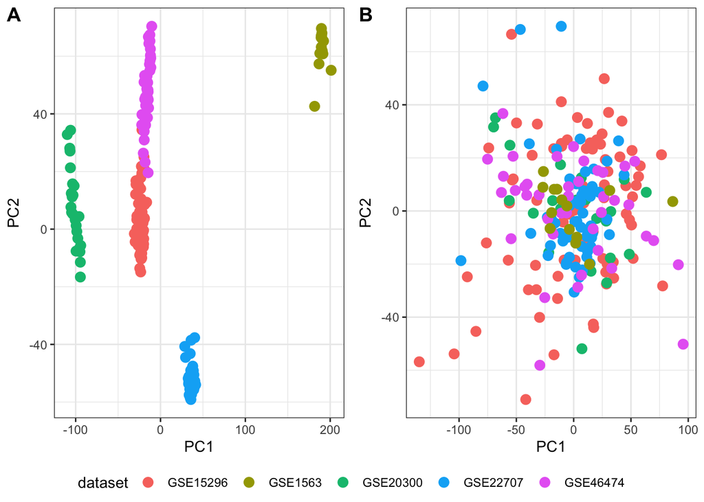

```r
ggarrange(p1, p2, labels = c('A', 'B'),
          ncol = 2, nrow = 1,
          common.legend = TRUE, legend = 'bottom')
```

#### Overview

- 213 patients
  - 116 rejected patients
  - 97 stable patients
- 8,557 genes

### Test set

#### `y_test` *(test set pData)*

```r
y_test = pGSE50084
```

#### `X_test` *(test set eMat)*

```r
# exclude any genes that are not included in the train data
X_test = eGSE50084[which(rownames(eGSE50084) %in% common_genes),]
# rearrange to match the gene order of the train data
X_test = X_test[match(common_genes, rownames(X_test)),]
```

#### Overview

- 54 patients
  - 28 rejected patients
  - 26 stable patients
- 8,557 genes

## Feature Selection

```r
# a data frame to store the performance of the models after hyper parameters are fine tuned
best_avg_perf = vector('list', length = 7)
```

### Limma

```r
# the number of significant genes to choose from
n_vals = c(10, 25, 50, 75, 100, 150, 200, 250, 300, 400, 500)
limma_perf = vector('list', length = 5 * length(n_vals))
index = 1
# create a loop for cross validation
for (i in c(1:5)) {
  # preprocess
  preproc = fs_preproc(test_fold = i)
  cv_x_train = preproc$x_train
  cv_x_test = preproc$x_test
  cv_y_train = preproc$y_train
  cv_y_test = preproc$y_test
  # feature selection (limma in this example)
  design = model.matrix(~cv_y_train$outcome)
  fit = lmFit(cv_x_train, design) |> eBayes()
  rank = topTable(fit, n = Inf)
  # loop through each possible n values
  for (n in n_vals){
    # select n top genes
    de = rownames(rank)[1:n]
    # include only n top genes in the training and the test fold
    cv_train_reduced = cv_x_train[de,]
    cv_test_reduced = cv_x_test[de,]
    # random forest built on training fold
    rf = randomForest(x = t(cv_train_reduced), y = cv_y_train$outcome)
    # evaluate model performance on the test fold
    pred_prob = predict(rf, t(cv_test_reduced), type = 'prob')[, 'reject']
    pred_class = ifelse(pred_prob > 0.5, 'reject', 'stable') |>
      factor(levels = c('stable', 'reject'))
    # roc object to calculate auc
    roc_obj = roc(response = cv_y_test$outcome, predictor = pred_prob)
    # extract model performance and store it in the comparison table
    limma_perf[[index]] = data.frame(gene_number = n,
                                     auc = auc(roc_obj) |> as.numeric())
    index = index + 1
  }
}
```

```
Found 76 genes with uniform expression within a single batch (all zeros); these will not be adjusted for batch.
```

```
Found 1298 genes with uniform expression within a single batch (all zeros); these will not be adjusted for batch.
```

```
Found 91 genes with uniform expression within a single batch (all zeros); these will not be adjusted for batch.
```

```
Found 1219 genes with uniform expression within a single batch (all zeros); these will not be adjusted for batch.
```

```
Found 135 genes with uniform expression within a single batch (all zeros); these will not be adjusted for batch.
```

```
Found 989 genes with uniform expression within a single batch (all zeros); these will not be adjusted for batch.
```

```
Found 78 genes with uniform expression within a single batch (all zeros); these will not be adjusted for batch.
```

```
Found 1266 genes with uniform expression within a single batch (all zeros); these will not be adjusted for batch.
```

```
Found 70 genes with uniform expression within a single batch (all zeros); these will not be adjusted for batch.
```

```
Found 1260 genes with uniform expression within a single batch (all zeros); these will not be adjusted for batch.
```

```r
# calculate the overall performance of each n value
limma_perf = limma_perf |> bind_rows() |> drop_na()
limma_rank = limma_perf |>
  group_by(gene_number) |>
  summarise(mean_auc = mean(auc)) |>
  arrange(desc(mean_auc))
# visualize the performance of each n
limma_rank_long = limma_rank |>
  pivot_longer(cols = mean_auc, names_to = 'metric', values_to = 'value')
(ggplot(data = limma_rank_long,
        aes(x = gene_number, y = value)) +
    geom_line() +
    labs(x = 'Number of genes', y = 'Area Under the Curve (AUC)', title = 'Performance of Limma with different numbers of genes on Blood data') +
    theme_bw()) |>
  ggplotly()
```

[interactive chart not shown]

```r
limma_rank |> datatable(colnames = c('Gene number', 'Mean AUC'))
```

|  | Gene number | Mean AUC |
| --- | --- | --- |
| 1 | 300 | 0.8585821437652102 |
| 2 | 500 | 0.856890414441902 |
| 3 | 400 | 0.8543269405397553 |
| 4 | 100 | 0.8518111401692638 |
| 5 | 50 | 0.8493416512295232 |
| 6 | 250 | 0.8447913261414407 |
| 7 | 200 | 0.8441656677926702 |
| 8 | 75 | 0.8411749482401657 |
| 9 | 25 | 0.8409329483128112 |
| 10 | 150 | 0.8397265809451165 |

[output cut: 1 more lines]

```r
# optimal n
best_avg_perf[[1]] = data.frame(method = rep('Limma', 5),
                                limma_perf |>
                                  filter(gene_number == 300))
```

### Mutual Information

```r
# storage for performance per cross validation
mi_perf = vector('list', length = 5 * length(n_vals))
index = 1
# create a loop for cross validation
for (i in c(1:5)) {
  preproc = fs_preproc(test_fold = i)
  cv_x_train = preproc$x_train
  cv_x_test = preproc$x_test
  cv_y_train = preproc$y_train
  cv_y_test = preproc$y_test
  # rank genes based on their mi score
  rank = mi_score(cv_x_train, cv_y_train)
  # loop through each possible n values
  for (n in n_vals){
    # select n top genes
    de = rank[1:n]
    # include only n top genes in the training and the test fold
    cv_x_train_reduced = cv_x_train[de,]
    cv_x_test_reduced = cv_x_test[de,]
    # random forest built on training fold
    rf = randomForest(x = t(cv_x_train_reduced), y = cv_y_train$outcome)
    # evaluate model performance on the test fold
    pred_prob = predict(rf, t(cv_x_test_reduced), type = 'prob')[,'reject']
    roc_obj = roc(response = cv_y_test$outcome, predictor = pred_prob)
    # extract model performance and store it in the comparison table
    mi_perf[[index]] = data.frame(gene_number = n,
                                  auc = auc(roc_obj) |> as.numeric())
    index = index + 1
  }
}
```

```
Found 76 genes with uniform expression within a single batch (all zeros); these will not be adjusted for batch.
```

```
Found 1298 genes with uniform expression within a single batch (all zeros); these will not be adjusted for batch.
```

```
Found 91 genes with uniform expression within a single batch (all zeros); these will not be adjusted for batch.
```

```
Found 1219 genes with uniform expression within a single batch (all zeros); these will not be adjusted for batch.
```

```
Found 135 genes with uniform expression within a single batch (all zeros); these will not be adjusted for batch.
```

```
Found 989 genes with uniform expression within a single batch (all zeros); these will not be adjusted for batch.
```

```
Found 78 genes with uniform expression within a single batch (all zeros); these will not be adjusted for batch.
```

```
Found 1266 genes with uniform expression within a single batch (all zeros); these will not be adjusted for batch.
```

```
Found 70 genes with uniform expression within a single batch (all zeros); these will not be adjusted for batch.
```

```
Found 1260 genes with uniform expression within a single batch (all zeros); these will not be adjusted for batch.
```

```r
# calculate the overall performance of each n value
mi_perf = mi_perf |> bind_rows() |> drop_na()
mi_rank = mi_perf |>
  group_by(gene_number) |>
  summarise(mean_auc = mean(auc)) |>
  arrange(desc(mean_auc))
# visualize the performance of each n
mi_rank_long = mi_rank |>
  pivot_longer(cols = mean_auc, names_to = 'metric', values_to = 'value')
(ggplot(data = mi_rank_long, aes(x = gene_number, y = value)) +
    geom_line() +
    labs(x = 'Gene number', y = 'Area Under the Curve (AUC)', title = 'Performance of Mutual Information with different numbers of genes on Blood data') +
    theme_bw()) |>
  ggplotly()
```

[interactive chart not shown]

```r
mi_rank |> datatable(colnames = c('Gene number', 'Mean AUC'))
```

|  | Gene number | Mean AUC |
| --- | --- | --- |
| 1 | 500 | 0.8672632668628093 |
| 2 | 400 | 0.8621839925901712 |
| 3 | 100 | 0.8554129889942249 |
| 4 | 300 | 0.848561167411282 |
| 5 | 75 | 0.848194762267989 |
| 6 | 200 | 0.8476154153499693 |
| 7 | 250 | 0.8454501289455525 |
| 8 | 150 | 0.8415122952308308 |
| 9 | 50 | 0.8376221350477645 |
| 10 | 25 | 0.8099624060150378 |

[output cut: 1 more lines]

```r
# save the optimal n value
best_avg_perf[[2]] = data.frame(
  method = rep('MI', 5),
  mi_perf |> filter(gene_number == 500))
```

### Fisher score

```r
fisher_perf = vector('list', length = 5 * length(n_vals))
index = 1
# loop to do cross validation
for (i in c(1:5)) {
  preproc = fs_preproc(test_fold = i)
  cv_x_train = preproc$x_train
  cv_x_test = preproc$x_test
  cv_y_train = preproc$y_train
  cv_y_test = preproc$y_test
  fisher_scores = fisher_score(cv_x_train %>% as.matrix(), cv_y_train)
  # calculate fisher scores from the train folds
  rank = fisher_scores |> rownames()
  for (n in n_vals) {
    # select top n genes
    de = rank[1:n]
    cv_train_reduced = cv_x_train[de,]
    cv_test_reduced = cv_x_test[de,]
    # build a random forest to evaluate performance
    rf = randomForest(t(cv_train_reduced), cv_y_train$outcome)
    pred_prob = predict(rf, t(cv_test_reduced), type = 'prob')[,'reject']
    roc_obj = roc(response = cv_y_test$outcome, predictor = pred_prob)
    # extract the recall rate
    fisher_perf[[index]] = data.frame(gene_number = n,
                                      auc = auc(roc_obj) |> as.numeric())
    index = index + 1
  }
}
```

```
Found 76 genes with uniform expression within a single batch (all zeros); these will not be adjusted for batch.
```

```
Found 1298 genes with uniform expression within a single batch (all zeros); these will not be adjusted for batch.
```

```
Found 91 genes with uniform expression within a single batch (all zeros); these will not be adjusted for batch.
```

```
Found 1219 genes with uniform expression within a single batch (all zeros); these will not be adjusted for batch.
```

```
Found 135 genes with uniform expression within a single batch (all zeros); these will not be adjusted for batch.
```

```
Found 989 genes with uniform expression within a single batch (all zeros); these will not be adjusted for batch.
```

```
Found 78 genes with uniform expression within a single batch (all zeros); these will not be adjusted for batch.
```

```
Found 1266 genes with uniform expression within a single batch (all zeros); these will not be adjusted for batch.
```

```
Found 70 genes with uniform expression within a single batch (all zeros); these will not be adjusted for batch.
```

```
Found 1260 genes with uniform expression within a single batch (all zeros); these will not be adjusted for batch.
```

```r
# calculate the overall performance of each n value
fisher_perf = fisher_perf |> bind_rows() |> drop_na()
fisher_rank = fisher_perf |>
  group_by(gene_number) |>
  summarise(mean_auc = mean(auc)) |>
  arrange(desc(mean_auc))
# visualize the performance of each n
fisher_rank_long = fisher_rank |>
  pivot_longer(cols = mean_auc, names_to = 'metric', values_to = 'value')
(ggplot(data = fisher_rank_long, aes(x = gene_number, y = value)) +
    geom_line() +
    labs(x = 'Gene number', y = 'Area Under the Curve (AUC)', title = 'Performance of Fisher score with different numbers of genes on Blood data') +
    theme_bw()) |>
  ggplotly()
```

[interactive chart not shown]

```r
fisher_rank |> datatable(colnames = c('Gene number', 'Mean AUC'))
```

|  | Gene number | Mean AUC |
| --- | --- | --- |
| 1 | 500 | 0.770749791144528 |
| 2 | 400 | 0.7593821510297484 |
| 3 | 250 | 0.7458955359413025 |
| 4 | 300 | 0.7444603356216629 |
| 5 | 50 | 0.7312792851694454 |
| 6 | 150 | 0.7299367077113073 |
| 7 | 200 | 0.7264274817478479 |
| 8 | 75 | 0.7225082634121537 |
| 9 | 100 | 0.7063364934074317 |
| 10 | 25 | 0.6174180923322801 |

[output cut: 1 more lines]

```r
# retain the best performing n value
best_avg_perf[[4]] = data.frame(
  method = rep('Fisher', 5),
  fisher_perf |> filter(gene_number == 500))
```

### T-test

```r
t_test_perf = vector('list', length = 5 * length(n_vals))
index = 1
# loop for cross validation
for (i in c(1:5)) {
  # train-test folds split
  preproc = fs_preproc(test_fold = i)
  cv_x_train = preproc$x_train
  cv_x_test = preproc$x_test
  cv_y_train = preproc$y_train
  cv_y_test = preproc$y_test
  # perform t test for each gene
  t_test = apply(cv_x_train, 1, function(gene) {
    t.test(gene~cv_y_train$outcome)$p.value
  })
  # rank the gene based on their p-value
  rank = data.frame(
    row.names = rownames(cv_x_train),
    pval = t_test
  ) |> arrange(pval)
  # loop to find the optimal number of significant genes
  for (n in n_vals) {
    # select the top n genes
    de = rownames(rank)[1:n]
    cv_train_reduced = cv_x_train[de,]
    cv_test_reduced = cv_x_test[de,]
    # random forest to evaluate the feature selection method
    rf = randomForest(t(cv_train_reduced), cv_y_train$outcome)
    pred_prob = predict(rf, t(cv_test_reduced), type = 'prob')[,'reject']
    roc_obj = roc(response = cv_y_test$outcome, predictor = pred_prob)
    # extract the recall rate
    t_test_perf[[index]] = data.frame(gene_number = n,
                                      auc = auc(roc_obj) |> as.numeric())
    index = index + 1
  }
}
```

```
Found 76 genes with uniform expression within a single batch (all zeros); these will not be adjusted for batch.
```

```
Found 1298 genes with uniform expression within a single batch (all zeros); these will not be adjusted for batch.
```

```
Found 91 genes with uniform expression within a single batch (all zeros); these will not be adjusted for batch.
```

```
Found 1219 genes with uniform expression within a single batch (all zeros); these will not be adjusted for batch.
```

```
Found 135 genes with uniform expression within a single batch (all zeros); these will not be adjusted for batch.
```

```
Found 989 genes with uniform expression within a single batch (all zeros); these will not be adjusted for batch.
```

```
Found 78 genes with uniform expression within a single batch (all zeros); these will not be adjusted for batch.
```

```
Found 1266 genes with uniform expression within a single batch (all zeros); these will not be adjusted for batch.
```

```
Found 70 genes with uniform expression within a single batch (all zeros); these will not be adjusted for batch.
```

```
Found 1260 genes with uniform expression within a single batch (all zeros); these will not be adjusted for batch.
```

```r
# calculate the overall performance of each n value
t_test_perf = t_test_perf |> bind_rows() |> drop_na()
t_test_rank = t_test_perf |>
  group_by(gene_number) |>
  summarise(mean_auc = mean(auc)) |>
  arrange(desc(mean_auc))
# visualize the performance of each n
t_test_rank_long = t_test_rank |>
  pivot_longer(cols = mean_auc, names_to = 'metric', values_to = 'value')
(ggplot(data = t_test_rank_long, aes(x = gene_number, y = value)) +
    geom_line() +
    labs(x = 'Gene number', y = 'Area Under the Curve (AUC)', title = 'Performance of T-test with different number of genes on Blood data') +
    theme_bw()) |>
  ggplotly()
```

[interactive chart not shown]

```r
t_test_rank |> datatable(colnames = c('Gene number', 'Mean AUC'))
```

|  | Gene number | Mean AUC |
| --- | --- | --- |
| 1 | 400 | 0.8624750281500856 |
| 2 | 250 | 0.8538388543823328 |
| 3 | 300 | 0.8536086593294834 |
| 4 | 500 | 0.8515809451164144 |
| 5 | 75 | 0.8493098688750864 |
| 6 | 100 | 0.8488058915404454 |
| 7 | 200 | 0.8473084886128365 |
| 8 | 150 | 0.8460399186371728 |
| 9 | 50 | 0.8324184555591878 |
| 10 | 25 | 0.8119292797210419 |

[output cut: 1 more lines]

```r
# retain the best performing n value
best_avg_perf[[5]] = data.frame(
  method = rep('T-test', 5),
  t_test_perf |> filter(gene_number == 400))
```

### Significance Analysis of Microarrays (SAM)

```r
sam_perf = vector('list', length = 5 * length(n_vals))
index = 1
# loop to perform cross validation
for (i in c(1:5)) {
  # train-test folds split
  preproc = fs_preproc(test_fold = i)
  cv_x_train = preproc$x_train
  cv_x_test = preproc$x_test
  cv_y_train = preproc$y_train
  cv_y_test = preproc$y_test
  # turn outcome into binary values
  bin_y_train = ifelse(cv_y_train$outcome == 'stable', 0, 1)
  # run SAM for feature selection
  sam_result = sam(cv_x_train, bin_y_train,
                   gene.names = rownames(cv_x_train))
  sam_summary = summary(sam_result, delta = 0.5)
  all_genes_sig = sam_summary@mat.sig
  rank = all_genes_sig |>
    arrange((abs(d.value)))
  # loop through possible number of significant genes
  for (n in n_vals) {
    if (n > nrow(rank)) {
      break
    }
    # select the top n genes
    de = rownames(rank)[1:n]
    cv_train_reduced = cv_x_train[de,]
    cv_test_reduced = cv_x_test[de,]
    # random forest to evaluate method performance
    rf = randomForest(t(cv_train_reduced), cv_y_train$outcome)
    pred_prob = predict(rf, t(cv_test_reduced), type = 'prob')[,'reject']
    roc_obj = roc(response = cv_y_test$outcome, predictor = pred_prob)
    # extract the method sensitivity
    sam_perf[[index]] = data.frame(gene_number = n,
                                   auc = auc(roc_obj) |> as.numeric())
    index = index + 1
  }
}
```

```
Found 76 genes with uniform expression within a single batch (all zeros); these will not be adjusted for batch.
```

```
Found 1298 genes with uniform expression within a single batch (all zeros); these will not be adjusted for batch.
```

```
Found 91 genes with uniform expression within a single batch (all zeros); these will not be adjusted for batch.
```

```
Found 1219 genes with uniform expression within a single batch (all zeros); these will not be adjusted for batch.
```

```
Found 135 genes with uniform expression within a single batch (all zeros); these will not be adjusted for batch.
```

```
Found 989 genes with uniform expression within a single batch (all zeros); these will not be adjusted for batch.
```

```
Found 78 genes with uniform expression within a single batch (all zeros); these will not be adjusted for batch.
```

```
Found 1266 genes with uniform expression within a single batch (all zeros); these will not be adjusted for batch.
```

```
Found 70 genes with uniform expression within a single batch (all zeros); these will not be adjusted for batch.
```

```
Found 1260 genes with uniform expression within a single batch (all zeros); these will not be adjusted for batch.
```

```r
# calculate the overall performance of each n value
sam_perf = sam_perf |> bind_rows() |> drop_na()
sam_rank = sam_perf |>
  group_by(gene_number) |>
  summarise(mean_auc = mean(auc)) |>
  arrange(desc(mean_auc))
# visualize the performance of each n
sam_rank_long = sam_rank |>
  pivot_longer(cols = mean_auc, names_to = 'metric', values_to = 'value')
(ggplot(data = sam_rank_long, aes(x = gene_number, y = value)) +
    geom_line() +
    labs(x = 'Gene number', y = 'Area Under the Curve (AUC)', title = 'Performance of SAM with different numbers of genes on Blood data') +
    theme_bw()) |>
  ggplotly()
```

[interactive chart not shown]

```r
sam_rank |> datatable(colnames = c('Gene number', 'Mean AUC'))
```

|  | Gene number | Mean AUC |
| --- | --- | --- |
| 1 | 250 | 0.8124609531074063 |
| 2 | 400 | 0.8109980567360431 |
| 3 | 300 | 0.8107864770622208 |
| 4 | 500 | 0.8045258072718028 |
| 5 | 200 | 0.7968117758163525 |
| 6 | 75 | 0.79344284624605 |
| 7 | 150 | 0.7728306272928699 |
| 8 | 100 | 0.7708119937524973 |
| 9 | 50 | 0.7678980058842759 |
| 10 | 25 | 0.7019954778249974 |

[output cut: 1 more lines]

```r
# retain the best performing n value
best_sam = sam_perf |>
  filter(gene_number == 250)
best_avg_perf[[6]] = data.frame(method = rep('SAM', nrow(best_sam)),
                                best_sam)
```

### Networks

```r
# top 500 genes (in order) for the batch correction code listed below (not the actual final set of top 500 genes). in a list because its easier to copy paste from the jupyter notebook.
genes_part_1 = c('SCN4A', 'CLDN14', 'CLCNKA', 'EFNA2', 'ADAMTSL2', 'PSG4', 'C8B', 'MFAP2', 'LALBA', 'CSF1', 'FOXG1', 'SLC6A7', 'GPR31', 'GNG12', 'RAC3', 'ST5', 'HRG', 'INSL4', 'PTPN3', 'CHAD', 'COL2A1', 'LBP', 'CX3CL1', 'ISLR', 'DPEP1', 'SLN', 'ITIH1', 'FEV', 'FOXD2', 'PPP1R3C', 'PRB4', 'PHYHIP', 'FOXN1', 'MAG', 'LY6G6C', 'PROP1', 'SSTR4', 'AGXT', 'RPS6KA4', 'SIX3', 'AMELY', 'MSI1', 'ANGPTL2', 'SCGB1D2', 'SLC9A3R2', 'GUCA2B', 'NEUROG3', 'LY6D', 'ASMT', 'TUBB2B', 'ITGA8', 'ARC', 'GRM4', 'EVPL', 'ROR2', 'MOXD1', 'SYN3', 'HMHB1', 'MYO16', 'TNN', 'MAPK8IP1', 'EML3', 'TBX1', 'NGFR', 'CELSR1', 'SERPINB7', 'SLC22A6', 'GUCY2F', 'IRX5', 'ASB4', 'SERPINA3', 'EDN2', 'SLC5A4', 'KCNH1', 'BRINP2', 'CHRD', 'UTF1', 'RHBDL1', 'CLDN4', 'AQP8', 'PTPRF', 'EN2', 'FKBP4', 'NKX2-2', 'SLC7A4', 'INHA', 'MYBPC1', 'H6PD', 'PLA2G1B', 'CNTN2', 'ITIH3', 'MC2R', 'ACVRL1', 'HTR2B', 'TM4SF5', 'KLK6', 'ARR3', 'PSCA', 'IRF6', 'INPP5J', 'MB', 'PRSS8', 'APOC2', 'CDC14B', 'GJB5', 'C1orf68', 'ZFR2', 'DKK1', 'SLCO2A1', 'WNT5A', 'P2RX3', 'GPR50', 'HCRTR1', 'SYNGR4', 'EMILIN1', 'SGCG', 'C4BPB', 'MUSK', 'MYL2', 'SERPIND1', 'IVL', 'ACTL6B', 'MMP24', 'KRT33A', 'TULP1', 'NR1I2', 'PDC', 'CCL25', 'FABP6', 'HTR1D', 'TLX2', 'HOXB6', 'KCNJ12', 'TREH', 'CCKBR', 'PLK1', 'CCL1', 'CYP4F11', 'SHH', 'FCN3', 'ABCA4', 'ELOVL2', 'IGLV6-57', 'PPL', 'HAO1', 'ACE', 'MT3', 'GPR12', 'OVOL1', 'ARSE', 'KCNV2', 'CYP17A1', 'AXL', 'FMO6P', 'C9', 'GUCY2D', 'NKX2-8', 'POLRMT', 'C11orf52', 'GABRE', 'ASIP', 'MYCLP1', 'FOXH1', 'SYN1', 'AFF3', 'CCL14', 'S100A7', 'HIST1H2BM', 'NPR3', 'FAM189A2', 'GPR17', 'HCRTR2', 'CSN2', 'CGB', 'FAT2', 'CAMK1G', 'AANAT', 'TNNT3', 'FOXI1', 'ACTN3', 'MXRA8', 'TCP10', 'CYP2C8', 'LOR', 'OR7E24', 'SLC28A1', 'EMX1', 'CCL11', 'CACNG3', 'KCNA5', 'PLAT', 'PRAMEF12', 'NPAS1', 'DSG2', 'DSG1', 'PPARD', 'CYP4A11', 'ACHE', 'ABCC9', 'FGF4', 'PRKD1', 'OR2B6', 'ERBB3', 'KCNC4', 'C8G', 'ITGA10', 'WNT1', 'IL13RA2', 'PKP1', 'HMGCS2', 'PARK2', 'CELP', 'GABRG3', 'POU6F2', 'IL3', 'FOLR1', 'LRRC15', 'TNFSF11', 'OVOL2', 'GABRA3', 'PPY', 'SLC6A5', 'MAGEA8', 'KISS1', 'WNT2B', 'COMP', 'CDKL5', 'CYP3A5', 'SDC3', 'CDH4', 'GFAP', 'ZIC2', 'SLC7A11', 'GALNT18', 'RAPGEF5', 'KRT81', 'UPK2', 'CDH1', 'MAGEA11', 'CYP1A1', 'ARHGAP22', 'CELA2A', 'DSC3', 'COL4A2', 'HYAL1', 'SELE', 'APLP1', 'KCNJ9', 'ANXA10', 'REG1B', 'TMEM8B', 'GCK', 'SGCD', 'CTNNA2', 'TDO2', 'SLC10A1', 'ALX1', 'MAGEA12', 'GIP', 'CDR2L', 'P2RX6', 'CRYAA', 'TBX10', 'RRH', 'NTN3', 'SERPINB13', 'WNT2', 'SHOX', 'HOXC5', 'FZR1', 'SMR3A', 'OR10H3', 'CYP2E1', 'DLX4', 'BMPR1B', 'TNC', 'HIST1H1B', 'KCNC1', 'GNAT1', 'OR2F2', 'KRT8', 'CST6', 'TNNC1', 'PLA2G2A', 'KLK10', 'SOX2', 'FBXL2', 'NCAN', 'PPP1R1A', 'WISP2', 'ASIC2', 'FOXE1', 'ITPKA', 'BCAR3', 'NPHS1', 'TLN2', 'GPR3', 'SPINK1', 'FRMPD1', 'TRPC2', 'STARD13', 'TFF1', 'PROL1', 'DKK4', 'MALL', 'ATP4A', 'TWIST1', 'GML', 'NRXN2', 'UMOD', 'ONECUT2', 'IGFBP1', 'ASCL1', 'MID1', 'PI15', 'STMN2', 'GNG4', 'OR2J2', 'PHOX2B', 'MYH15', 'RAI14', 'GHRH', 'OR5I1', 'DRD3', 'RAD54L', 'LY6H', 'SPEF1', 'MEP1A', 'TJP1', 'ALDH3B2', 'SLIT2')
genes_part_2 = c('EDDM3A', 'MYO1A', 'CAPN6', 'PGD', 'PLEKHA6', 'CALML3', 'BMP8A', 'BMP3', 'TEX28', 'FUT1', 'KRT14', 'KRT76', 'HIST1H2AK', 'ALOX12B', 'WFDC2', 'CYP11B1', 'ACKR2', 'SEMA3D', 'RAMP2', 'PON3', 'NUDC', 'DRD2', 'ADH1C', 'PARD3', 'ELAVL2', 'PRICKLE3', 'TFAP2C', 'GJA1', 'KRT9', 'RAPSN', 'UPK1B', 'TEAD1', 'MAGEC1', 'SPINK5', 'DOC2A', 'GUCY2C', 'GPR143', 'KRT16', 'GRM2', 'CAPN9', 'ZMYND10', 'WNT8B', 'MOG', 'MAGEA2', 'FSHR', 'TLX1', 'SLC2A5', 'REN', 'AFF2', 'VIP', 'HYPM', 'CSN1S1', 'POM121L2', 'SPOCK3', 'SPINT3', 'LCE2B', 'MPPED1', 'IAPP', 'ADAM20', 'CSN3', 'SPRR1A', 'TRIM10', 'RPL18', 'CHRNB4', 'KCNA1', 'DAO', 'SLC12A3', 'SLC22A24', 'KRT86', 'AGT', 'CHRDL1', 'PCSK1', 'NPR2', 'ENDOU', 'PAX2', 'RAG2', 'CCL16', 'PRPS1L1', 'GABRB3', 'SMR3B', 'WT1', 'SYDE1', 'POU3F4', 'FUT6', 'PSG11', 'FOXF2', 'OR2H1', 'MYBPH', 'FZD7', 'MCF2', 'CHRNB3', 'C6', 'ATP6V1B1', 'ADAM22', 'FETUB', 'STON1', 'OR2F1', 'ARNT2', 'GRP', 'C22orf31', 'CSHL1', 'LDLR', 'RGS7', 'MLANA', 'IL5', 'TTTY1', 'S100A3', 'AHDC1', 'PRSS2', 'F2RL3', 'SLC29A2', 'MYF6', 'MYH2', 'NRP2', 'EMX2', 'ADH6', 'SLC6A4', 'ZP2', 'APOBEC1', 'SRY', 'ABCA6', 'CELSR3', 'FGFR4', 'RLBP1', 'PLTP', 'APOD', 'NMNAT2', 'IFNA4', 'CCK', 'IRGC', 'LPAL2', 'PTPRB', 'FGFR3', 'PPP1R37', 'INSM1', 'KCNJ8', 'FLRT2', 'NTRK1', 'BAI2', 'CCDC106', 'CYP7B1', 'ACADL', 'PCDHB17', 'PRRG1', 'SEMA5A', 'SRPX', 'POU3F1', 'SLC34A1', 'PDHA2', 'ESPL1', 'FMO1', 'FAM131B', 'STEAP1', 'HPGDS', 'TRIL', 'MAGEA3', 'SPRR1B', 'SLC17A2', 'HIST1H2AL', 'RAB40C', 'SPIN2A', 'ASB9', 'HTR6', 'ATP6V1G2', 'MYH8', 'ITIH2', 'CRTC1', 'GRIN2D', 'TACR3', 'BMP10', 'GPX2', 'AMPD1', 'CRX', 'COL11A1', 'BRINP1', 'LSS', 'MSLN', 'HLF', 'CPN1', 'HAAO', 'PTGIS', 'DPYS', 'SULF1', 'FGF3', 'TGM4', 'GYG2', 'MEIS2', 'SLC6A1', 'GABRA6', 'MAPK10', 'NR5A1', 'APOF', 'GABRP', 'LHCGR', 'SCGB2A1', 'NDP', 'SLC26A10', 'NPTX2', 'SERPINA7', 'PITX1', 'EPHA2', 'TFAP2B', 'EML1', 'AADAC', 'TPO', 'AKR1B10', 'KRT75', 'SLC5A2', 'DCX', 'SHANK2', 'ADRA2A', 'EXPH5', 'UNC93A', 'DKK3', 'THBS2', 'PLXNB3', 'FBXL7', 'ACSM1', 'PSD3', 'CACNA1F', 'HIST1H2BL', 'TFF2', 'SCN7A', 'NUDCD3', 'APOB', 'TEKT2', 'HTR1E', 'MAGEA4', 'TTC28', 'CDK5R2', 'GK2', 'MTSS1L', 'S100G', 'ADCYAP1R1', 'GJC1', 'FADS2', 'DCT', 'IFNA8', 'INHBC', 'PKLR', 'MDK', 'CFHR4', 'NRTN', 'COL21A1', 'ROS1', 'PHKA1', 'AP2A2', 'BMP4', 'ITGB6', 'B3GALT5', 'CCL27', 'RECQL4', 'SH3BGR', 'TBX6', 'GHRHR', 'NNAT', 'CELA3A', 'INS', 'KCNK2', 'RARRES2', 'ZNF157', 'CABP1', 'KRT20', 'OPN1SW', 'SSTR2', 'ERC2-IT1', 'GABRB1', 'ASS1', 'SORCS3', 'ANKRD1', 'HGFAC', 'GATA4', 'SYCP1', 'POU2F3', 'NLGN4Y', 'PNLIPRP2', 'TGFB2', 'ATP1A3', 'GP2', 'CLDN7', 'GJA8', 'AKAP3', 'RFPL1', 'GPD1', 'HOXC6', 'LOX', 'SLC6A9', 'PPEF1', 'FOSL1', 'CELA2B', 'MAPK12', 'BTF3P13', 'HLA-DPA2', 'MTTP', 'PPARG', 'GNB3', 'CPZ', 'IFNB1', 'CHRNA4', 'MUC7', 'GREM1', 'ADCY10', 'MLLT4-AS1', 'MYOZ2', 'HCRT', 'CP', 'PAGE1', 'SLCO1A2', 'MYH7', 'MAS1', 'KRT2', 'DCBLD2', 'XPNPEP2', 'AGTR1', 'AMELX', 'CEL', 'ABCA12', 'MPZ', 'TEC', 'MAGEA1', 'CUBN', 'SPINT1', 'SLC8A2', 'LRRC17', 'CPNE6', 'KIAA1462', 'SLC5A1', 'TMEM246', 'AMOT', 'LPAR4', 'CBLN1', 'PTTG2', 'PIK3C2G', 'NR2E1', 'MTCL1', 'PACRG', 'PTPN14', 'DEFB1', 'STXBP5L', 'OAZ3', 'TSR3', 'SOSTDC1', 'DCC', 'MAPK11', 'NPY1R', 'DGKG', 'POU4F2', 'RALYL', 'FASN', 'HOXB13', 'SPAG11A', 'LCN1', 'RBMS3', 'GABRA5', 'ZFYVE9', 'EFNB2', 'ANKRD34C', 'GH1', 'EFHD1', 'ESR1', 'AKAP4', 'SLC26A3', 'OTC', 'TULP2', 'SLC2A4', 'MAB21L1', 'GFPT2', 'LRP4', 'PAX3', 'HSD3B1', 'SLC13A3', 'ACOX2', 'GPR37L1', 'ZNF549', 'WISP1', 'SEC14L2', 'NEUROD2', 'ADH7', 'PP14571', 'CDH5', 'TBR1', 'LDHC', 'KANK3', 'TIE1', 'FGF12', 'KDELR3', 'LOC81691', 'RYR3', 'KCNF1', 'COBL', 'CSPG4', 'LMO3', 'RHOBTB2', 'CPB2', 'PITX2', 'GRK4', 'PRM1', 'RAB40A', 'SERPINE1', 'CCNO')
genes_part_3 = c('STXBP1', 'FSCN2', 'SV2A', 'CDKL1', 'CST1', 'KCNB2', 'KCNH2', 'ITGA9', 'KCNMA1', 'BMP1', 'HIST1H3I', 'CCBL1', 'MYO1D', 'KATNB1', 'ANXA2P1', 'HPN', 'GRIA1', 'TNNI1', 'PMS2P4', 'NEUROD1', 'MAT1A', 'PLA2G4C', 'PPIL6', 'CHST1', 'ADIRF', 'CYP4B1', 'NTNG1', 'LCAT', 'PTPRD', 'SLMO1', 'TP53TG5', 'LECT2', 'RHBDF1', 'CRYBB3', 'CFHR3', 'OR2H2', 'CELSR2', 'FBLN1', 'CHRM3', 'COL5A2', 'GALR2', 'GIF', 'NLGN1', 'MEP1B', 'MOK', 'MAOB', 'MMP12', 'TEAD3', 'SMTN', 'TNFSF9', 'FGF2', 'CRYBA1', 'CACNB2', 'CDON', 'PCDH11X', 'GABRG2', 'BMP5', 'ERG', 'FSTL4', 'BNC1', 'MEF2B', 'TRAP1', 'N4BP3', 'AP1G2', 'LEP', 'CNKSR1', 'HSPB2', 'TCL1B', 'MPP3', 'JAG2', 'PDYN', 'MMP3', 'CSRP3', 'GJB3', 'LHX1', 'IL12B', 'ADD2', 'LGALS4', 'SNAP91', 'PAX1', 'HTR1B', 'SBSPON', 'CDH13', 'KRT35', 'CHRNA1', 'PON1', 'NAV3', 'ENPP2', 'FAM189A1', 'CHST15', 'PTH', 'EYA2', 'DIAPH2-AS1', 'CYP24A1', 'SFTPD', 'HBEGF', 'SLC6A13', 'HNF4G', 'TADA3', 'SLC26A4', 'C9orf3', 'MYBPC2', 'LBX1', 'SRD5A2', 'JUP', 'ZNF132', 'CA9', 'GRIN2A', 'CNGA3', 'JPH3', 'NRXN3', 'IGFBP3', 'MTMR7', 'SLC4A3', 'KRT31', 'AKAP6', 'PTGDR2', 'COL4A6', 'BTN1A1', 'PPFIA4', 'GAL', 'LRRC41', 'FAM47E', 'BAI3', 'CAP2', 'KAZN', 'HGC6.3', 'SLC22A14', 'DYNC1I1', 'OR1E1', 'ADCYAP1', 'CRYAB', 'RIBC2', 'ADAM21', 'ELOVL6', 'PMP22', 'DCLK1', 'B9D1', 'DNASE1L3', 'ADRA1A', 'DOK5', 'PINLYP', 'DES', 'NID2', 'PIWIL1', 'MMP13', 'COL4A1', 'CYP3A43', 'BRS3', 'CHRNE', 'COL16A1', 'CALCB', 'NRXN1', 'REG1P', 'DNM1', 'RND2', 'PTMS', 'MADCAM1', 'KRT15', 'AVPR1A', 'SLCO1B1', 'COL6A3', 'GABRD', 'ANO3', 'DAG1', 'RAMP3', 'COL10A1', 'SHROOM2', 'KRT4', 'KCNE1', 'PRLR', 'SPAM1', 'CLCN1', 'GRIP1', 'LILRP2', 'TENM4', 'SLC2A2', 'C8A', 'LYPLA2', 'DIXDC1', 'CLCA2', 'CCKAR', 'ARHGEF16', 'IGSF1', 'F9', 'OPCML', 'AQP6', 'TCHH', 'RGR', 'SYP', 'SLC7A2', 'CHGA', 'F2RL2', 'LINC00302', 'WWC1', 'TLL1', 'BFSP2', 'TBX5', 'PPM1E', 'PRRG2', 'PPFIA2', 'LRRTM2', 'CDC25C', 'PTPRU', 'OVOL3', 'C1orf105', 'RASSF9', 'SUSD5', 'SEMA6A', 'PCDH17', 'ODF1', 'PPIC', 'DOC2B', 'AIPL1', 'SLC9A3', 'CRHR2', 'CAPN11', 'FAM110B', 'SHBG', 'CACNA1B', 'ALB', 'SLC17A7', 'GRM1', 'INVS', 'TUSC3', 'KRT12', 'MMACHC', 'S100A5', 'KDR', 'HOXB1', 'IFNA10', 'ERBB4', 'CRHBP', 'EFNA1', 'PCDHA9', 'SLC22A13', 'DRD1', 'DLX5', 'PNMT', 'GPR116', 'MLLT4', 'B3GALNT1', 'SCN2A', 'ATP2B3', 'CFI', 'CDK18', 'OMD', 'SLC10A2', 'SOX9', 'DTNA', 'OLIG2', 'PIR', 'HOXA11', 'CNTN5', 'TYMS', 'KIAA0087', 'EPX', 'EMID1', 'GPR1', 'HOXD8', 'MGAT3', 'ZNRF4', 'GLRB', 'PLP1', 'TBL3', 'INSL3', 'F10', 'NR1H4', 'PDE1B')
network_rank = c(genes_part_1, genes_part_2, genes_part_3)
```

```r
networks_perf = vector('list', length = 5 * length(n_vals))
index = 1
# loop to perform cross validation
for (i in c(1:5)) {
  # train-test folds split
  preproc = fs_preproc(test_fold = i)
  cv_x_train = preproc$x_train
  cv_x_test = preproc$x_test
  cv_y_train = preproc$y_train
  cv_y_test = preproc$y_test
  # loop to select optimal number of significant genes
  for (n in n_vals) {
    # select the top n genes
    de = network_rank[1:n]
    cv_train_reduced = cv_x_train[de,]
    cv_test_reduced = cv_x_test[de,]
    # random forest to evaluate the feature selectin method
    rf = randomForest(t(cv_train_reduced), cv_y_train$outcome)
    pred_prob = predict(rf, t(cv_test_reduced), type = 'prob')[,'reject']
    roc_obj = roc(response = cv_y_test$outcome, predictor = pred_prob)
    # extract sensitivity
    networks_perf[[index]] = data.frame(gene_number = n,
                               auc = auc(roc_obj) |> as.numeric())
    index = index + 1
  }
}
```

```
Found 76 genes with uniform expression within a single batch (all zeros); these will not be adjusted for batch.
```

```
Found 1298 genes with uniform expression within a single batch (all zeros); these will not be adjusted for batch.
```

```
Found 91 genes with uniform expression within a single batch (all zeros); these will not be adjusted for batch.
```

```
Found 1219 genes with uniform expression within a single batch (all zeros); these will not be adjusted for batch.
```

```
Found 135 genes with uniform expression within a single batch (all zeros); these will not be adjusted for batch.
```

```
Found 989 genes with uniform expression within a single batch (all zeros); these will not be adjusted for batch.
```

```
Found 78 genes with uniform expression within a single batch (all zeros); these will not be adjusted for batch.
```

```
Found 1266 genes with uniform expression within a single batch (all zeros); these will not be adjusted for batch.
```

```
Found 70 genes with uniform expression within a single batch (all zeros); these will not be adjusted for batch.
```

```
Found 1260 genes with uniform expression within a single batch (all zeros); these will not be adjusted for batch.
```

```r
# calculate the overall performance of each n value
networks_perf = networks_perf |> bind_rows() |> drop_na()
networks_rank = networks_perf |>
  group_by(gene_number) |>
  summarise(mean_auc = mean(auc)) |>
  arrange(desc(mean_auc))
# visualize the performance of each n
networks_rank_long = networks_rank |>
  pivot_longer(cols = mean_auc, names_to = 'metric', values_to = 'value')
(ggplot(data = networks_rank_long, aes(x = gene_number, y = value)) +
    geom_line() +
    labs(x = 'Gene number', y = 'Area Under the Curve (AUC)', title = 'Performance of Networks with different numbers of genes on Blood data') +
    theme_bw()) |>
  ggplotly()
```

[interactive chart not shown]

```r
networks_rank |> datatable(colnames = c('Gene number', 'Mean AUC'))
```

|  | Gene number | Mean AUC |
| --- | --- | --- |
| 1 | 400 | 0.6907054774617704 |
| 2 | 500 | 0.6715747702589808 |
| 3 | 250 | 0.6168714358359667 |
| 4 | 200 | 0.5805201409320402 |
| 5 | 10 | 0.5775616577676074 |
| 6 | 300 | 0.5627424539609895 |
| 7 | 100 | 0.5594570665794921 |
| 8 | 150 | 0.555209581925829 |
| 9 | 50 | 0.549720315280956 |
| 10 | 25 | 0.5483168973157532 |

[output cut: 1 more lines]

```r
# retain the best performing n value
best_avg_perf[[7]] = data.frame(method = rep('Network', 5),
                                networks_perf |>
                                  filter(gene_number == 400))
```

### Comparative Boxplot

```r
best_avg_perf = best_avg_perf |> bind_rows()
best_avg_perf_long = best_avg_perf |>
  pivot_longer(cols = auc, names_to = 'metric', values_to = 'value')
p3 = ggplot(best_avg_perf_long, aes(x = factor(method), y = value, fill = gene_number)) +
  geom_boxplot() +
  labs(
    title = 'B. Blood',
    y = 'Area Under Curve (AUC)', x = 'Feature Selection Methods'
  ) +
  scale_fill_gradient(
    name = 'Gene Number',
    low = 'white',
    high = 'black'
  ) +
  theme_bw()
p3 |> ggplotly()
```

[interactive chart not shown]

```r
best_avg_perf %>%
  group_by(method, gene_number) %>%
  summarise(mean_auc = mean(auc)) %>%
  arrange(desc(mean_auc)) |>
  datatable(colnames = c('Method', 'Gene number', 'Mean AUC'))
```

|  | Method | Gene number | Mean AUC |
| --- | --- | --- | --- |
| 1 | MI | 500 | 0.8672632668628093 |
| 2 | T-test | 400 | 0.8624750281500856 |
| 3 | Limma | 300 | 0.8585821437652102 |
| 4 | SAM | 250 | 0.8124609531074063 |
| 5 | Fisher | 500 | 0.770749791144528 |
| 6 | Network | 400 | 0.6907054774617704 |

## Model Selection

```r
# comparing frame for model selection
model_selection = vector('list', length = 8)
# values of thresholds to be fine-tuned
thresholds = seq(from = 0.3, to = 0.7, by = 0.05)
```

### k-Nearest Neighbours (kNN)

```r
k_vals = c(1, 3, 5, 7, 10, 15, 25)
knn_perf = vector('list', 5 * length(k_vals) * length(thresholds))
index = 1
for (i in 1:5) {
  preproc = blood_preproc(test_fold = i)
  cv_train_reduced = preproc$x_train
  cv_test_reduced = preproc$x_test
  cv_y_train = preproc$y_train
  cv_y_test = preproc$y_test
  for (k in k_vals) {
    knn = knn3(t(cv_train_reduced), cv_y_train$outcome, k = k)
    pred_prob = predict(knn, t(cv_test_reduced))[,'reject']
    for (t in thresholds) {
    pred_class = ifelse(pred_prob > t, 'reject', 'stable') %>%
      factor(levels = c('stable', 'reject'))
    conf_mat = confusionMatrix(data = pred_class,
                              reference = cv_y_test$outcome, positive = 'reject')
    knn_perf[[index]] = data.frame(k = k, threshold = t,
                                  f1 = conf_mat$byClass['F1'],
                                  f2 = f2(pred_class, cv_y_test))
    index = index + 1
    }
  }
}
```

```
Found 76 genes with uniform expression within a single batch (all zeros); these will not be adjusted for batch.
```

```
Found 1298 genes with uniform expression within a single batch (all zeros); these will not be adjusted for batch.
```

```
Found 91 genes with uniform expression within a single batch (all zeros); these will not be adjusted for batch.
```

```
Found 1219 genes with uniform expression within a single batch (all zeros); these will not be adjusted for batch.
```

```
Found 135 genes with uniform expression within a single batch (all zeros); these will not be adjusted for batch.
```

```
Found 989 genes with uniform expression within a single batch (all zeros); these will not be adjusted for batch.
```

```
Found 78 genes with uniform expression within a single batch (all zeros); these will not be adjusted for batch.
```

```
Found 1266 genes with uniform expression within a single batch (all zeros); these will not be adjusted for batch.
```

```
Found 70 genes with uniform expression within a single batch (all zeros); these will not be adjusted for batch.
```

```
Found 1260 genes with uniform expression within a single batch (all zeros); these will not be adjusted for batch.
```

```r
knn_perf = bind_rows(knn_perf)
knn_rank = knn_perf |>
  group_by(k, threshold) |>
  summarise(mean_f1 = mean(f1),
            mean_f2 = mean(f2)) |>
  arrange(desc(0.4 * mean_f1 + 0.6 * mean_f2), threshold)
knn_rank_long = knn_rank |>
  pivot_longer(cols = mean_f1:mean_f2, names_to = 'metric', values_to = 'value')
knn_rank |>
  datatable(colnames = c('k', 'threshold', 'mean F1 score', 'mean F2 score'))
```

|  | k | threshold | mean F1 score | mean F2 score |
| --- | --- | --- | --- | --- |
| 1 | 3 | 0.3 | 0.7696553437970078 | 0.8450188681129798 |
| 2 | 15 | 0.3 | 0.7681310166830748 | 0.8206467954302867 |
| 3 | 25 | 0.3 | 0.7523529411764707 | 0.8228898071625345 |
| 4 | 25 | 0.35 | 0.7526460348162476 | 0.7998529674661856 |
| 5 | 15 | 0.35 | 0.7658689581095596 | 0.7848589699993872 |
| 6 | 10 | 0.3 | 0.756175634781992 | 0.7859061747784799 |
| 7 | 10 | 0.35 | 0.756175634781992 | 0.7859061747784799 |
| 8 | 5 | 0.3 | 0.7387794463697428 | 0.7829058132610376 |
| 9 | 5 | 0.35 | 0.7365596905428838 | 0.7771681083430048 |
| 10 | 7 | 0.3 | 0.7495574974175717 | 0.7631360022249852 |

[output cut: 53 more lines]

```r
model_selection[[1]] = data.frame(method = rep('KNN', 5),
                                  knn_perf |>
                                    filter(k == knn_rank$k[1]) |>
                                    filter(threshold == knn_rank$threshold[1]) |>
                                    select(-c(k, threshold)))
```

### Random Forest

```r
mtry_vals = c(1, 2, 5)
min.node.sizes = c(1, 2, 5)
rf_perf = vector('list', length = 5 * length(thresholds) * length(mtry_vals) * length(min.node.sizes))
index = 1
for (i in c(1:5)) {
  preproc = blood_preproc(test_fold = i)
  cv_train_reduced = preproc$x_train
  cv_test_reduced = preproc$x_test
  cv_y_train = preproc$y_train
  cv_y_test = preproc$y_test
  cv_train_t = t(cv_train_reduced) |> data.frame()
  cv_train_t$outcome = cv_y_train$outcome
  for (mtry in mtry_vals) {
    for (node in min.node.sizes) {
      rf = ranger(outcome ~ ., data = cv_train_t,
                  mtry = mtry, min.node.size = node,
                  probability = TRUE, splitrule = 'extratrees',
                  classification = TRUE, scale = TRUE)
      for (t in thresholds) {
        pred_prob = predict(rf, data.frame(t(cv_test_reduced)),
                        type = 'response')$predictions[,'reject']
        pred_class = ifelse(pred_prob > t, 'reject', 'stable') |>
          factor(levels = c('stable', 'reject'))
        conf_mat = confusionMatrix(pred_class, cv_y_test$outcome)
        rf_perf[[index]] = data.frame(mtry = mtry, min_node_size = node, threshold = t,
                                      f1 = conf_mat$byClass['F1'],
                                      f2 = f2(pred_class, cv_y_test))
        index = index + 1
      }
    }
  }
}
```

```
Found 76 genes with uniform expression within a single batch (all zeros); these will not be adjusted for batch.
```

```
Found 1298 genes with uniform expression within a single batch (all zeros); these will not be adjusted for batch.
```

```
Found 91 genes with uniform expression within a single batch (all zeros); these will not be adjusted for batch.
```

```
Found 1219 genes with uniform expression within a single batch (all zeros); these will not be adjusted for batch.
```

```
Found 135 genes with uniform expression within a single batch (all zeros); these will not be adjusted for batch.
```

```
Found 989 genes with uniform expression within a single batch (all zeros); these will not be adjusted for batch.
```

```
Found 78 genes with uniform expression within a single batch (all zeros); these will not be adjusted for batch.
```

```
Found 1266 genes with uniform expression within a single batch (all zeros); these will not be adjusted for batch.
```

```
Found 70 genes with uniform expression within a single batch (all zeros); these will not be adjusted for batch.
```

```
Found 1260 genes with uniform expression within a single batch (all zeros); these will not be adjusted for batch.
```

```r
rf_perf = bind_rows(rf_perf)
rf_perf_rank = rf_perf |>
  group_by(mtry, min_node_size, threshold) |>
  summarise(mean_f1 = mean(f1, na.rm = TRUE),
            mean_f2 = mean(f2, na.rm = TRUE))|>
  arrange(desc(0.4 * mean_f1 + 0.6 * mean_f2))
rf_perf_rank_long = rf_perf_rank |>
  pivot_longer(cols = mean_f1:mean_f2, names_to = 'metric', values_to = 'value')
rf_perf_rank |>
  datatable(colnames = c('mtry', 'min.node.size', 'threshold',
                         'mean F1 score', 'mean F2 score'))
```

|  | mtry | min.node.size | threshold | mean F1 score | mean F2 score |
| --- | --- | --- | --- | --- | --- |
| 1 | 5 | 5 | 0.5 | 0.7282462253193961 | 0.7794348918954014 |
| 2 | 5 | 1 | 0.45 | 0.6568733293733294 | 0.8263719774980008 |
| 3 | 5 | 5 | 0.45 | 0.655850279988211 | 0.82495682962576 |
| 4 | 5 | 2 | 0.5 | 0.7307445769005276 | 0.7738861378221985 |
| 5 | 1 | 2 | 0.5 | 0.7185756299515729 | 0.7781524581619867 |
| 6 | 2 | 1 | 0.5 | 0.7203071669932135 | 0.7625492273506104 |
| 7 | 2 | 2 | 0.5 | 0.7239836375814488 | 0.7570627352331022 |
| 8 | 2 | 1 | 0.45 | 0.6359489133095944 | 0.8152928568798049 |
| 9 | 1 | 1 | 0.5 | 0.7037878787878787 | 0.7677601899351689 |
| 10 | 2 | 2 | 0.45 | 0.6173341698696668 | 0.8248515809521093 |

[output cut: 71 more lines]

```r
model_selection[[2]]= data.frame(method = rep('RF', 5),
                          rf_perf |>
                            filter(mtry == rf_perf_rank$mtry[1]) |>
                            filter(min_node_size == rf_perf_rank$min_node_size[1]) |>
                            filter(threshold == rf_perf_rank$threshold[1]) |>
                            select(-c(mtry, min_node_size, threshold)))
```

### Logistic Regression

```r
lambda_grid = 10^seq(-5, 0, length = 10)
alpha_values = c(0.1, 0.4, 0.6, 0.9)
log_perf = vector('list', length = 5 * length(lambda_grid) * length(alpha_values) * length(thresholds))
index = 1
for (i in c(1:5)) {
  preproc = blood_preproc(test_fold = i)
  cv_train_reduced = preproc$x_train
  cv_test_reduced = preproc$x_test
  cv_y_train = preproc$y_train
  cv_y_test = preproc$y_test
  for (lambda in lambda_grid) {
    for (a in alpha_values) {
      lr = glmnet(t(cv_train_reduced), cv_y_train$outcome, family = 'binomial',
                  alpha = a, lambda = lambda, standardize = FALSE)
      pred_prob = predict(lr, t(cv_test_reduced), type = 'response')[,1]
      for (t in thresholds) {
        pred_class = ifelse(pred_prob > t, 'reject', 'stable') |>
          factor(levels = c('stable', 'reject'))
        conf_mat = confusionMatrix(cv_y_test$outcome, pred_class, positive = 'reject')
        log_perf[[index]] = data.frame(lambda = lambda, alpha = a, threshold = t,
                                       f1 = conf_mat$byClass['F1'],
                                       f2 = f2(pred_class, cv_y_test))
        index = index + 1
      }
    }
  }
}
```

```
Found 76 genes with uniform expression within a single batch (all zeros); these will not be adjusted for batch.
```

```
Found 1298 genes with uniform expression within a single batch (all zeros); these will not be adjusted for batch.
```

```
Found 91 genes with uniform expression within a single batch (all zeros); these will not be adjusted for batch.
```

```
Found 1219 genes with uniform expression within a single batch (all zeros); these will not be adjusted for batch.
```

```
Found 135 genes with uniform expression within a single batch (all zeros); these will not be adjusted for batch.
```

```
Found 989 genes with uniform expression within a single batch (all zeros); these will not be adjusted for batch.
```

```
Found 78 genes with uniform expression within a single batch (all zeros); these will not be adjusted for batch.
```

```
Found 1266 genes with uniform expression within a single batch (all zeros); these will not be adjusted for batch.
```

```
Found 70 genes with uniform expression within a single batch (all zeros); these will not be adjusted for batch.
```

```
Found 1260 genes with uniform expression within a single batch (all zeros); these will not be adjusted for batch.
```

```r
log_perf = bind_rows(log_perf)
log_perf_rank = log_perf |>
  group_by(lambda, alpha, threshold) |>
  summarise(mean_f1 = mean(f1, na.rm = TRUE),
            mean_f2 = mean(f2, na.rm = TRUE)) |>
  arrange(desc(0.4 * mean_f1 + 0.6 * mean_f2))
log_perf_rank_long = log_perf_rank |>
  pivot_longer(cols = mean_f1:mean_f2, names_to = 'metric', values_to = 'value')
log_perf_rank |>
  datatable(colnames = c('lambda', 'alpha', 'threshold',
                         'mean F1 score', 'mean F2 score'))
```

|  | lambda | alpha | threshold | mean F1 score | mean F2 score |
| --- | --- | --- | --- | --- | --- |
| 1 | 0.2782559402207126 | 0.4 | 0.35 | 0.7445011877481471 | 0.8751767838843997 |
| 2 | 0.07742636826811278 | 0.9 | 0.35 | 0.778299744353095 | 0.8492179161031543 |
| 3 | 0.07742636826811278 | 0.9 | 0.4 | 0.7842594038410564 | 0.8424035341691809 |
| 4 | 0.07742636826811278 | 0.6 | 0.3 | 0.7683384932920537 | 0.8488095238095238 |
| 5 | 1 | 0.1 | 0.35 | 0.7323458485958486 | 0.8722936015095036 |
| 6 | 0.2782559402207126 | 0.4 | 0.4 | 0.7503107727640858 | 0.8575810711371452 |
| 7 | 0.07742636826811278 | 0.9 | 0.3 | 0.7581892566813665 | 0.8486103651596616 |
| 8 | 0.2782559402207126 | 0.4 | 0.3 | 0.7227625152625152 | 0.8669313586931605 |
| 9 | 1 | 0.1 | 0.3 | 0.7205509768009768 | 0.865640818910869 |
| 10 | 0.02154434690031885 | 0.9 | 0.3 | 0.7874851031321619 | 0.8196770547906024 |

[output cut: 350 more lines]

```r
model_selection[[3]] = data.frame(method = rep('LR', 5),
                                  log_perf |>
                                     filter(lambda == log_perf_rank$lambda[1]) |>
                                     filter(alpha == log_perf_rank$alpha[1]) |>
                                     filter(threshold == log_perf_rank$threshold[1]) |>
                                     select(-c(lambda, alpha, threshold)))
```

### SVM

#### SVM Linear

```r
C_vals = 2^(-5:5)
svm_linear_perf = vector('list', length = 5 * length(C_vals) * length(thresholds))
index = 1
for (i in c(1:5)) {
  preproc = blood_preproc(test_fold = i)
  cv_train_reduced = preproc$x_train
  cv_test_reduced = preproc$x_test
  cv_y_train = preproc$y_train
  cv_y_test = preproc$y_test
  for (c in C_vals) {
    svm = svm(x = t(cv_train_reduced), y = cv_y_train$outcome,
              cost = c, kernel = 'linear', probability = TRUE)
    pred_prob = predict(svm, t(cv_test_reduced), probability = TRUE) %>%
      attr('probabilities')
    pred_prob = pred_prob[,'reject']
    for (t in thresholds) {
      pred_class = ifelse(pred_prob > t, 'reject', 'stable') %>%
        factor(levels = c('stable', 'reject'))
      conf_mat = confusionMatrix(data = pred_class,
                                reference = cv_y_test$outcome, positive = 'reject')
      svm_linear_perf[[index]] = data.frame(C = c, threshold = t,
                                            f1 = conf_mat$byClass['F1'],
                                            f2 = f2(pred_class, cv_y_test))
      index = index + 1
    }
  }
}
```

```
Found 76 genes with uniform expression within a single batch (all zeros); these will not be adjusted for batch.
```

```
Found 1298 genes with uniform expression within a single batch (all zeros); these will not be adjusted for batch.
```

```
Found 91 genes with uniform expression within a single batch (all zeros); these will not be adjusted for batch.
```

```
Found 1219 genes with uniform expression within a single batch (all zeros); these will not be adjusted for batch.
```

```
Found 135 genes with uniform expression within a single batch (all zeros); these will not be adjusted for batch.
```

```
Found 989 genes with uniform expression within a single batch (all zeros); these will not be adjusted for batch.
```

```
Found 78 genes with uniform expression within a single batch (all zeros); these will not be adjusted for batch.
```

```
Found 1266 genes with uniform expression within a single batch (all zeros); these will not be adjusted for batch.
```

```
Found 70 genes with uniform expression within a single batch (all zeros); these will not be adjusted for batch.
```

```
Found 1260 genes with uniform expression within a single batch (all zeros); these will not be adjusted for batch.
```

```r
svm_linear_perf = bind_rows(svm_linear_perf)
svm_linear_rank = svm_linear_perf %>%
  group_by(C, threshold) %>%
  summarise(mean_f1 = mean(f1),
            mean_f2 = mean(f2)) %>%
  arrange(desc(0.4 * mean_f1 + 0.6 * mean_f2))
svm_linear_rank |>
  datatable(colnames = c('C', 'threshold', 'mean F1 score', 'mean F2 score'))
```

|  | C | threshold | mean F1 score | mean F2 score |
| --- | --- | --- | --- | --- |
| 1 | 0.125 | 0.3 | 0.7097446445094866 | 0.7454640947219257 |
| 2 | 1 | 0.3 | 0.7042481906087773 | 0.738095983905539 |
| 3 | 2 | 0.3 | 0.7042481906087773 | 0.738095983905539 |
| 4 | 16 | 0.3 | 0.7042481906087773 | 0.738095983905539 |
| 5 | 8 | 0.3 | 0.7057547455195875 | 0.7338061491964081 |
| 6 | 0.0625 | 0.3 | 0.702662958079974 | 0.7325857067860343 |
| 7 | 0.25 | 0.3 | 0.702662958079974 | 0.7325857067860343 |
| 8 | 0.5 | 0.3 | 0.702662958079974 | 0.7325857067860343 |
| 9 | 32 | 0.3 | 0.702662958079974 | 0.7325857067860343 |
| 10 | 0.03125 | 0.3 | 0.7010409408057828 | 0.72698737133121 |

[output cut: 89 more lines]

```r
model_selection[[4]] = data.frame(method = rep('SVM-L', 5),
                                  svm_linear_perf %>%
                                     filter(C == svm_linear_rank$C[1]) %>%
                                     filter(threshold == svm_linear_rank$threshold[1]) |>
                                     select(-c(C, threshold)))
```

#### SVM Radial

```r
gamma_vals = 2^c(-10, -5, 0, 5, 10)
svm_radial_perf = vector('list', length = 5 * length(C_vals) * length(gamma_vals) * length(thresholds))
index = 1
for (i in c(1:5)) {
  preproc = blood_preproc(test_fold = i)
  cv_train_reduced = preproc$x_train
  cv_test_reduced = preproc$x_test
  cv_y_train = preproc$y_train
  cv_y_test = preproc$y_test
  for (c in C_vals) {
    for (gamma in gamma_vals) {
      svm = svm(x = t(cv_train_reduced), y = cv_y_train$outcome,
                cost = c, kernel = 'radial', gamma = gamma, probability = TRUE)
      pred_prob = predict(svm, t(cv_test_reduced), probability = TRUE) %>%
        attr('probabilities')
      pred_prob = pred_prob[,'reject']
      for (t in thresholds) {
        pred_class = ifelse(pred_prob > t, 'reject', 'stable') %>%
          factor(levels = c('stable', 'reject'))
        conf_mat = confusionMatrix(data = pred_class,
                                  reference = cv_y_test$outcome, positive = 'reject')
        svm_radial_perf[[index]] = data.frame(C = c, gamma = gamma, threshold = t,
                                              f1 = conf_mat$byClass['F1'],
                                              f2 = f2(pred_class, cv_y_test))
        index = index + 1
      }
    }
  }
}
```

```
Found 76 genes with uniform expression within a single batch (all zeros); these will not be adjusted for batch.
```

```
Found 1298 genes with uniform expression within a single batch (all zeros); these will not be adjusted for batch.
```

```
Found 91 genes with uniform expression within a single batch (all zeros); these will not be adjusted for batch.
```

```
Found 1219 genes with uniform expression within a single batch (all zeros); these will not be adjusted for batch.
```

```
Found 135 genes with uniform expression within a single batch (all zeros); these will not be adjusted for batch.
```

```
Found 989 genes with uniform expression within a single batch (all zeros); these will not be adjusted for batch.
```

```
Found 78 genes with uniform expression within a single batch (all zeros); these will not be adjusted for batch.
```

```
Found 1266 genes with uniform expression within a single batch (all zeros); these will not be adjusted for batch.
```

```
Found 70 genes with uniform expression within a single batch (all zeros); these will not be adjusted for batch.
```

```
Found 1260 genes with uniform expression within a single batch (all zeros); these will not be adjusted for batch.
```

```r
svm_radial_perf = bind_rows(svm_radial_perf)
svm_radial_rank = svm_radial_perf %>%
  group_by(C, gamma, threshold) %>%
  summarise(mean_f1 = mean(f1),
            mean_f2 = mean(f2)) %>%
  arrange(desc(0.4 * mean_f1 + 0.6 * mean_f2))
svm_radial_rank |>
  datatable(colnames = c('C', 'gamma', 'threshold', 'mean F1 score', 'mean F2 score'))
```

|  | C | gamma | threshold | mean F1 score | mean F2 score |
| --- | --- | --- | --- | --- | --- |
| 1 | 0.25 | 0.0009765625 | 0.3 | 0.7534355833125955 | 0.8585130695479484 |
| 2 | 0.03125 | 0.0009765625 | 0.3 | 0.7475425865098159 | 0.8548447205314854 |
| 3 | 0.5 | 0.0009765625 | 0.3 | 0.7543271332514699 | 0.8455981462333351 |
| 4 | 0.5 | 0.0009765625 | 0.35 | 0.7512425746296714 | 0.8304446963695391 |
| 5 | 0.25 | 0.0009765625 | 0.35 | 0.7417510875664457 | 0.8355828562033223 |
| 6 | 0.125 | 0.0009765625 | 0.35 | 0.7448189943125395 | 0.8331612567466613 |
| 7 | 0.03125 | 0.0009765625 | 0.35 | 0.7402935191170485 | 0.8336788280818132 |
| 8 | 0.03125 | 0.03125 | 0.3 | 0.7052842809364549 | 0.8567799301365512 |
| 9 | 0.03125 | 0.03125 | 0.35 | 0.7052842809364549 | 0.8567799301365512 |
| 10 | 0.03125 | 0.03125 | 0.4 | 0.7052842809364549 | 0.8567799301365512 |

[output cut: 485 more lines]

```r
model_selection[[5]] = data.frame(method = rep('SVM-R', 5),
                                  svm_radial_perf %>%
                                     filter(C == svm_radial_rank$C[1]) %>%
                                     filter(gamma == svm_radial_rank$gamma[1]) %>%
                                     filter(threshold == svm_radial_rank$threshold[1]) |>
                                     select(-c(C, gamma, threshold)))
```

#### SVM Polynomial

```r
degrees = c(2,3,4)
zero_coef = c(0, 1, 10)
svm_poly_perf = vector('list', length = 5 * length(degrees) * length(zero_coef) * length(thresholds) * length(C_vals))
index = 1
for (i in c(1:5)) {
  preproc = blood_preproc(test_fold = i)
  cv_train_reduced = preproc$x_train
  cv_test_reduced = preproc$x_test
  cv_y_train = preproc$y_train
  cv_y_test = preproc$y_test
  for (c in C_vals) {
    for (d in  degrees) {
      for (z in zero_coef) {
        svm = svm(x = t(cv_train_reduced), y = cv_y_train$outcome,
                        cost = c, kernel = 'polynomial', degree = d,
                        coef0 = z, probability = TRUE)
        pred_prob = predict(svm, t(cv_test_reduced), probability = TRUE) %>%
          attr('probabilities')
        pred_prob = pred_prob[,'reject']
        for (t in thresholds) {
          pred_class = ifelse(pred_prob > t, 'reject', 'stable') %>%
            factor(levels = c('stable', 'reject'))
          conf_mat = confusionMatrix(data = pred_class,
                                    reference = cv_y_test$outcome,
                                    positive = 'reject')
          svm_poly_perf[[index]] = data.frame(C = c, degree = d, coef0 = z,
                                              threshold = t,
                                              f1 = conf_mat$byClass['F1'],
                                              f2 = f2(pred_class, cv_y_test))
          index = index + 1
        }
      }
    }
  }
}
```

```
Found 76 genes with uniform expression within a single batch (all zeros); these will not be adjusted for batch.
```

```
Found 1298 genes with uniform expression within a single batch (all zeros); these will not be adjusted for batch.
```

```
Found 91 genes with uniform expression within a single batch (all zeros); these will not be adjusted for batch.
```

```
Found 1219 genes with uniform expression within a single batch (all zeros); these will not be adjusted for batch.
```

```
Found 135 genes with uniform expression within a single batch (all zeros); these will not be adjusted for batch.
```

```
Found 989 genes with uniform expression within a single batch (all zeros); these will not be adjusted for batch.
```

```
Found 78 genes with uniform expression within a single batch (all zeros); these will not be adjusted for batch.
```

```
Found 1266 genes with uniform expression within a single batch (all zeros); these will not be adjusted for batch.
```

```
Found 70 genes with uniform expression within a single batch (all zeros); these will not be adjusted for batch.
```

```
Found 1260 genes with uniform expression within a single batch (all zeros); these will not be adjusted for batch.
```

```r
svm_poly_perf = bind_rows(svm_poly_perf)
svm_poly_rank = svm_poly_perf %>%
  group_by(C, degree, coef0, threshold) %>%
  summarise(mean_f1 = mean(f1),
            mean_f2 = mean(f2)) %>%
  arrange(desc(0.4 * mean_f1 + 0.6 * mean_f2))
svm_poly_rank |>
  datatable(colnames = c('C', 'degree', 'coef0', 'threshold',
                         'mean F1 score', 'mean F2 score'))
```

|  | C | degree | coef0 | threshold | mean F1 score | mean F2 score |
| --- | --- | --- | --- | --- | --- | --- |
| 1 | 0.5 | 4 | 1 | 0.3 | 0.7902313947644936 | 0.8385494077002023 |
| 2 | 8 | 3 | 0 | 0.35 | 0.7707495076668944 | 0.8446409008478897 |
| 3 | 8 | 3 | 0 | 0.4 | 0.7835594651653764 | 0.8318307748818322 |
| 4 | 8 | 4 | 1 | 0.3 | 0.7844241938353415 | 0.8308508000015946 |
| 5 | 2 | 4 | 1 | 0.3 | 0.783564728097827 | 0.830959753529903 |
| 6 | 8 | 3 | 0 | 0.3 | 0.7609977167120959 | 0.8446711339759468 |
| 7 | 1 | 4 | 1 | 0.3 | 0.7859155926752586 | 0.8277987880669802 |
| 8 | 32 | 4 | 1 | 0.3 | 0.786655081098974 | 0.8271523428442829 |
| 9 | 4 | 3 | 0 | 0.35 | 0.76423973727422 | 0.8417386589698491 |
| 10 | 32 | 3 | 0 | 0.3 | 0.7582148975953386 | 0.8432338136409887 |

[output cut: 881 more lines]

```r
model_selection[[6]] = data.frame(method = rep('SVM-P', 5),
                                  svm_poly_perf %>%
                                     filter(C == svm_poly_rank$C[1]) %>%
                                     filter(degree == svm_poly_rank$degree[1]) %>%
                                     filter(coef0 == svm_poly_rank$coef0[1]) %>%
                                     filter(threshold == svm_poly_rank$threshold[1]) |>
                                     select(-c(C, degree, coef0, threshold)))
```

#### SVM Sigmoid

```r
svm_sigmoid_perf = vector('list', length = 5 * length(thresholds) * length(C_vals) * length(gamma_vals) * length(zero_coef))
index = 1
for (i in c(1:5)) {
  preproc = blood_preproc(test_fold = i)
  cv_train_reduced = preproc$x_train
  cv_test_reduced = preproc$x_test
  cv_y_train = preproc$y_train
  cv_y_test = preproc$y_test
  for (c in C_vals) {
    for(g in gamma_vals) {
      for (z in zero_coef) {
        svm = svm(x = t(cv_train_reduced), y = cv_y_train$outcome,
                        cost = c, kernel = 'sigmoid', gamma = g,
                        coef0 = z, probability = TRUE)
        pred_prob = predict(svm, t(cv_test_reduced), probability = TRUE) %>%
          attr('probabilities')
        pred_prob = pred_prob[,'reject']
        for (t in thresholds) {
          pred_class = ifelse(pred_prob > t, 'reject', 'stable') %>%
            factor(levels = c('stable', 'reject'))
          conf_mat = confusionMatrix(data = pred_class,
                                    reference = cv_y_test$outcome,
                                    positive = 'reject')
          svm_sigmoid_perf[[index]] = data.frame(C = c, gamma = g, coef0 = z, threshold = t,
                                                 f1 = conf_mat$byClass['F1'],
                                                 f2 = f2(pred_class, cv_y_test))
          index = index + 1
        }
      }
    }
  }
}
```

```
Found 76 genes with uniform expression within a single batch (all zeros); these will not be adjusted for batch.
```

```
Found 1298 genes with uniform expression within a single batch (all zeros); these will not be adjusted for batch.
```

```
Found 91 genes with uniform expression within a single batch (all zeros); these will not be adjusted for batch.
```

```
Found 1219 genes with uniform expression within a single batch (all zeros); these will not be adjusted for batch.
```

```
Found 135 genes with uniform expression within a single batch (all zeros); these will not be adjusted for batch.
```

```
Found 989 genes with uniform expression within a single batch (all zeros); these will not be adjusted for batch.
```

```
Found 78 genes with uniform expression within a single batch (all zeros); these will not be adjusted for batch.
```

```
Found 1266 genes with uniform expression within a single batch (all zeros); these will not be adjusted for batch.
```

```
Found 70 genes with uniform expression within a single batch (all zeros); these will not be adjusted for batch.
```

```
Found 1260 genes with uniform expression within a single batch (all zeros); these will not be adjusted for batch.
```

```r
svm_sigmoid_perf = svm_sigmoid_perf |> bind_rows()
svm_sigmoid_rank = svm_sigmoid_perf %>%
  group_by(C, gamma, coef0, threshold) %>%
  summarise(mean_f1 = mean(f1),
            mean_f2 = mean(f2)) %>%
  arrange(desc(0.4 * mean_f1 + 0.6 * mean_f2))
svm_sigmoid_rank |>
  datatable(colnames = c('C', 'gamma', 'coef0', 'threshold',
                         'mean F1 score', 'mean F2 score'))
```

|  | C | gamma | coef0 | threshold | mean F1 score | mean F2 score |
| --- | --- | --- | --- | --- | --- | --- |
| 1 | 0.25 | 0.0009765625 | 10 | 0.45 | 0.7401156551277617 | 0.8421765881685563 |
| 2 | 0.03125 | 0.03125 | 10 | 0.45 | 0.711990231990232 | 0.8567745215528199 |
| 3 | 0.03125 | 0.0009765625 | 10 | 0.3 | 0.7052842809364549 | 0.8567799301365512 |
| 4 | 0.03125 | 0.0009765625 | 10 | 0.35 | 0.7052842809364549 | 0.8567799301365512 |
| 5 | 0.03125 | 0.0009765625 | 10 | 0.4 | 0.7052842809364549 | 0.8567799301365512 |
| 6 | 0.03125 | 0.0009765625 | 10 | 0.45 | 0.7052842809364549 | 0.8567799301365512 |
| 7 | 0.03125 | 0.0009765625 | 10 | 0.5 | 0.7052842809364549 | 0.8567799301365512 |
| 8 | 0.03125 | 0.03125 | 10 | 0.3 | 0.7052842809364549 | 0.8567799301365512 |
| 9 | 0.03125 | 0.03125 | 10 | 0.35 | 0.7052842809364549 | 0.8567799301365512 |
| 10 | 0.0625 | 0.0009765625 | 10 | 0.3 | 0.7052842809364549 | 0.8567799301365512 |

[output cut: 1475 more lines]

```r
model_selection[[7]] = data.frame(method = rep('SVM-S', 5),
                                  svm_sigmoid_perf %>%
                                     filter(C == svm_sigmoid_rank$C[1]) %>%
                                     filter(gamma == svm_sigmoid_rank$gamma[1]) %>%
                                     filter(coef0 == svm_sigmoid_rank$coef0[1]) %>%
                                     filter(threshold == svm_sigmoid_rank$threshold[1]) |>
                                     select(-c(C, gamma, coef0, threshold)))
```

### XGBoost

```r
eta_vals = c(0.05, 0.1, 0.3, 0.5, 0.8)
max_depth_vals = c(1,4,5,7,8)
nrounds = c(10, 15, 20, 30, 50, 75, 100)
xgb_perf = vector('list', length = 5 * length(eta_vals) * length(max_depth_vals) * length(nrounds))
index = 1
for (i in c(1:5)) {
  preproc = blood_preproc(test_fold = i)
  cv_train_reduced = preproc$x_train
  cv_test_reduced = preproc$x_test
  cv_y_train = preproc$y_train
  cv_y_test = preproc$y_test
  dtrain = xgb.DMatrix(data = t(cv_train_reduced),
                       label = ifelse(cv_y_train$outcome == 'stable', 0, 1))
  dtest = xgb.DMatrix(data = t(cv_test_reduced))
  for(e in eta_vals) {
    for (d in max_depth_vals) {
      for (n in nrounds) {
         params = list(objective = 'binary:logistic',
                      eval_metric = 'aucpr',
                      eta = e,
                      max_depth = d)
          xgb = xgb.train(params = params, data = dtrain, nrounds = n, verbose = 0)
          pred_prob = predict(xgb, dtest)
          for (t in thresholds) {
            pred_class = ifelse(pred_prob > t, 'reject', 'stable') %>%
              factor(levels = c('stable','reject'))
            conf_mat = confusionMatrix(data = pred_class,
                                      reference = cv_y_test$outcome,
                                      positive = 'reject')
            xgb_perf[[index]] = data.frame(eta = e, max_depth = d, nrounds = n, threshold = t,
                                           f1 = conf_mat$byClass['F1'],
                                           f2 = f2(pred_class, cv_y_test))
            index = index + 1
        }
      }
    }
  }
}
```

```
Found 76 genes with uniform expression within a single batch (all zeros); these will not be adjusted for batch.
```

```
Found 1298 genes with uniform expression within a single batch (all zeros); these will not be adjusted for batch.
```

```
Found 91 genes with uniform expression within a single batch (all zeros); these will not be adjusted for batch.
```

```
Found 1219 genes with uniform expression within a single batch (all zeros); these will not be adjusted for batch.
```

```
Found 135 genes with uniform expression within a single batch (all zeros); these will not be adjusted for batch.
```

```
Found 989 genes with uniform expression within a single batch (all zeros); these will not be adjusted for batch.
```

```
Found 78 genes with uniform expression within a single batch (all zeros); these will not be adjusted for batch.
```

```
Found 1266 genes with uniform expression within a single batch (all zeros); these will not be adjusted for batch.
```

```
Found 70 genes with uniform expression within a single batch (all zeros); these will not be adjusted for batch.
```

```
Found 1260 genes with uniform expression within a single batch (all zeros); these will not be adjusted for batch.
```

```r
xgb_perf = xgb_perf |> bind_rows()
xgb_rank = xgb_perf %>%
  group_by(eta, max_depth, nrounds, threshold) %>%
  summarise(mean_f1 = mean(f1),
            mean_f2 = mean(f2)) %>%
  arrange(desc(0.4 * mean_f1 + 0.6 * mean_f2))
xgb_rank |> datatable(colnames = c('eta', 'max depth', 'nrounds', 'threshold',
                                   'mean F1 score', 'mean F2 score'))
```

|  | eta | max depth | nrounds | threshold | mean F1 score | mean F2 score |
| --- | --- | --- | --- | --- | --- | --- |
| 1 | 0.1 | 4 | 100 | 0.4 | 0.8237321065596976 | 0.8498333089430268 |
| 2 | 0.1 | 7 | 75 | 0.3 | 0.8099668535954458 | 0.8488390804597702 |
| 3 | 0.1 | 8 | 75 | 0.3 | 0.8099668535954458 | 0.8488390804597702 |
| 4 | 0.1 | 5 | 75 | 0.3 | 0.8095716431003465 | 0.8488320166186399 |
| 5 | 0.1 | 5 | 100 | 0.3 | 0.8136348196163531 | 0.8458363500177798 |
| 6 | 0.1 | 4 | 75 | 0.35 | 0.8089810383936881 | 0.8483871740268595 |
| 7 | 0.1 | 7 | 100 | 0.3 | 0.8105344341630265 | 0.8443262378092198 |
| 8 | 0.1 | 8 | 100 | 0.3 | 0.8105344341630265 | 0.8443262378092198 |
| 9 | 0.1 | 1 | 100 | 0.3 | 0.775554150529342 | 0.8651555769720912 |
| 10 | 0.1 | 7 | 50 | 0.3 | 0.7948877209746774 | 0.8519353665109594 |

[output cut: 1565 more lines]

```r
model_selection[[8]] = data.frame(method = rep('XGB', 5),
                                  xgb_perf %>%
                                    filter(eta == xgb_rank$eta[1]) %>%
                                    filter(max_depth == xgb_rank$max_depth[1]) %>%
                                    filter(nrounds == xgb_rank$nrounds[1]) %>%
                                    filter(threshold == xgb_rank$threshold[1]) |>
                                    select(-c(eta, max_depth, nrounds, threshold)))
```

### Comparative Boxplots

```r
model_selection = model_selection |> bind_rows()
model_selection_long = model_selection |>
  pivot_longer(cols = f1:f2, names_to = 'metric', values_to = 'value')
p4 = ggplot(data = model_selection_long,
            aes(x = method, y = value)) +
  geom_boxplot() +
  facet_wrap(~metric) +
    labs(title = 'B. Blood',
         x = 'Model', y = 'Performance') +
    theme_bw()
p4 |> ggplotly()
```

[interactive chart not shown]

```r
sum_model_selection = model_selection |>
  group_by(method) |>
  summarise(mean_f1 = mean(f1),
            mean_f2 = mean(f2)) %>%
  arrange(desc(0.4 * mean_f1 + 0.6 * mean_f2))
sum_model_selection_long = sum_model_selection |>
  pivot_longer(cols = mean_f1:mean_f2, names_to = 'metric', values_to = 'value')
sum_model_selection |>
  datatable(colnames = c('method', 'mean F1 score', 'mean F2 score'))
```

|  | method | mean F1 score | mean F2 score |
| --- | --- | --- | --- |
| 1 | XGB | 0.8237321065596976 | 0.8498333089430268 |
| 2 | LR | 0.7445011877481471 | 0.8751767838843997 |
| 3 | SVM-P | 0.7902313947644936 | 0.8385494077002023 |
| 4 | SVM-R | 0.7534355833125955 | 0.8585130695479484 |
| 5 | KNN | 0.7696553437970078 | 0.8450188681129798 |
| 6 | SVM-S | 0.7401156551277617 | 0.8421765881685563 |
| 7 | RF | 0.7282462253193961 | 0.7794348918954014 |
| 8 | SVM-L | 0.7097446445094866 | 0.7454640947219257 |

## Model Construction & Evaluation

```r
# batch correction
train_batched = ComBat(X_train, y_train$original_dataset)
# normalize
norm = normalize(train_batched, X_test)
train_normed = norm$train
test_normed = norm$test
# feature selection
de = blood_de(train_normed, y_train)
train_de = train_normed[de,]
test_de = test_normed[de,]
# create data matrix for xgb
dtrain = xgb.DMatrix(data = t(train_de),
                     label = ifelse(y_train$outcome == 'stable', 0, 1))
dtest = xgb.DMatrix(data = t(test_de))
# fine-tuned xgb parameters
best_eta = xgb_rank$eta[1]
best_max_depth = xgb_rank$max_depth[1]
best_nrounds = xgb_rank$nrounds[1]
best_threshold = xgb_rank$threshold[1]
# model construction
params = list(objective = 'binary:logistic',
              eval_metric = 'aucpr',
              eta = best_eta,
              max_depth = best_max_depth)
xgb = xgb.train(params = params, data = dtrain, nrounds = best_nrounds, verbose = 0)
# perform model on test set
pred_prob = predict(xgb, dtest)
pred_class = ifelse(pred_prob > best_threshold, 'reject', 'stable') |>
  factor(levels = c('stable', 'reject'))
# performance evaluation
confusionMatrix(data = pred_class, reference = y_test$outcome, positive = 'reject')
```

```
Confusion Matrix and Statistics

          Reference
Prediction stable reject
    stable      8      4
    reject     18     24

               Accuracy : 0.5926
                 95% CI : (0.4503, 0.7243)
    No Information Rate : 0.5185
    P-Value [Acc > NIR] : 0.170320

                  Kappa : 0.1681

 Mcnemar's Test P-Value : 0.005578

            Sensitivity : 0.8571
            Specificity : 0.3077
         Pos Pred Value : 0.5714
         Neg Pred Value : 0.6667
             Prevalence : 0.5185
         Detection Rate : 0.4444
   Detection Prevalence : 0.7778
      Balanced Accuracy : 0.5824

       'Positive' Class : reject
```

## Save the plots for the final report

```r
plot_list = list(
  blood_pca_noBatch = p1,
  blood_pca_batch = p2,
  blood_feature_selection = p3,
  blood_model = p4
)
```

# Biopsy Data

## Data Cleaning

### GSE53605

**Originally:**

- 55 patients
- 22,277 genes

```r
gse53605 <-getGEO("GSE53605", GSEMatrix = TRUE, AnnotGPL = TRUE)
gse53605 <- gse53605[[1]]
```

#### pData

- 37 rejected patients
- 18 stable patients

```r
pGSE53605 <- pData(gse53605)
# decide stable-reject outcome from the histological diagnosis
pGSE53605$outcome <- pGSE53605$`histological diagnosis:ch1`
pGSE53605$outcome[pGSE53605$outcome == "Normal allografts"] <- "stable"
pGSE53605$outcome[pGSE53605$outcome == "calcineurin inhibitor toxicity (CNIT)"] <- "reject"
pGSE53605$outcome[pGSE53605$outcome == "Acute Rejection (AR or ACR)"] <- "reject"
pGSE53605$outcome[pGSE53605$outcome == "IF/TA"] <- "reject"
pGSE53605$outcome = factor(pGSE53605$outcome, levels = c('stable', 'reject'))
# get rid of unnecessary columns
pGSE53605 <- pGSE53605[, !names(pGSE53605) %in% c("status", "submission_date", "last_update_date", "channel_count", "extract_protocol_ch1", "label_protocol_ch1", "extract_protocol_ch2", "label_protocol_ch2", "hyb_protocol", "scan_protocol", "data_processing", "contact_name", "contact_email", "contact_phone", "contact_laboratory", "contact_address", "contact_institute", "contact_department", "contact_city", "contact_state", "contact_zip/postal_code", "contact_country", "supplementary_file")]
pGSE53605 = pGSE53605 |> select(c(geo_accession, outcome))
pGSE53605 <- pGSE53605[!is.na(pGSE53605$outcome), ]
```

#### fData

```r
fGSE53605 = fData(gse53605)
fGSE53605$gene_symbols <- fGSE53605$`Gene symbol`
fGSE53605 = fGSE53605 |> remove_constant()
has_multiple <- grepl("///", fGSE53605$`Gene symbol`, fixed = TRUE)
# Split and assign only for those rows
fGSE53605$gene_symbols[has_multiple] <- sapply(
  strsplit(fGSE53605$`Gene symbol`[has_multiple], "\\s*///\\s*"),
  `[`,
  1
)
fGSE53605$gene_symbols <- trimws(fGSE53605$gene_symbols)
fGSE53605 <- fGSE53605[!is.na(fGSE53605$gene_symbols), ]
fGSE53605 = fGSE53605 |> select(c(ID, gene_symbols)) |> filter(gene_symbols != '')
```

#### eMat

**After cleaning:**

```r
eGSE53605 = exprs(gse53605)
eGSE53605 <- eGSE53605[rownames(fGSE53605), rownames(pGSE53605)]
all(rownames(pGSE53605) %in% colnames(eGSE53605))
```

```
[1] TRUE
```

```r
# remove constant gene expressions
eGSE53605 = eGSE53605[apply(eGSE53605, 1,
                            function(x) length(unique(x)) > 1),]
eGSE53605 = limma_duplicates(eGSE53605, fGSE53605, pGSE53605)
```

### GSE138043

**Originally:**

- 52 patients
- 16,885 genes

```r
gse138043 <-getGEO("GSE138043", GSEMatrix = TRUE, AnnotGPL = TRUE)
gse138043 <- gse138043[[1]]
```

#### pData

- 15 rejected patients
- 37 stable patients

```r
pGSE138043 <- pData(gse138043)
pGSE138043 = pGSE138043 |> remove_constant() |>
  filter(`rejection at 12months post transplant:ch1` != '')
pGSE138043$outcome = ifelse(pGSE138043$`rejection at 12months post transplant:ch1` == 'AR', 'reject', 'stable') |> factor(levels = c('stable', 'reject'))
pGSE138043 <- pGSE138043[, !names(pGSE138043) %in% c("channel_count", "extract_protocol_ch1", "label_protocol_ch1", "extract_protocol_ch2", "label_protocol_ch2", "hyb_protocol", "scan_protocol", "data_processing", "contact_name", "contact_email", "contact_phone", "contact_laboratory", "contact_address", "contact_institute", "status", "submission_date", "last_update_date", "contact_department", "contact_city", "contact_state", "contact_zip/postal_code", "contact_country", "supplementary_file")]
pGSE138043 = pGSE138043 |> select(c(geo_accession, outcome))
```

#### fData

```r
fGSE138043 <- fData(gse138043)
fGSE138043 = fGSE138043 |> remove_constant() |>
  filter(gene_assignment != '') |>
  filter(gene_assignment != '---')
# Only apply the split to rows with '///'
has_multiple <- grepl("///", fGSE138043$gene_assignment)
# For rows with multiple entries
fGSE138043$gene_symbols <- NA
fGSE138043$gene_symbols[has_multiple] <- sapply(strsplit(fGSE138043$gene_assignment[has_multiple], "///"), function(x) {
  strsplit(trimws(x[1]), " // ")[[1]][2]
})
# For rows with single entry
fGSE138043$gene_symbols[!has_multiple] <- sapply(strsplit(fGSE138043$gene_assignment[!has_multiple], " // "), `[`, 2)
fGSE138043 = fGSE138043 |> select(ID, gene_symbols)
```

#### eMat

**After cleaning:**

- 52 patients
- 16,389 genes

```r
eGSE138043 <- exprs(gse138043)
# remove constant gene expressions
eGSE138043 = eGSE138043[apply(eGSE138043, 1,
                            function(x) length(unique(x)) > 1),]
#using limma(DE) to get the significant duplicates
eGSE138043 = limma_duplicates(eGSE138043, fGSE138043, pGSE138043)
```

### GSE14328

**Originally:**

- 36 patients
- 54,675 genes

```r
gse14328 <-getGEO("GSE14328", GSEMatrix = TRUE, AnnotGPL = TRUE)
gse14328 <- gse14328[[1]]
```

#### pData

- 18 rejected patients
- 18 stable patients

```r
pGSE14328 <- pData(gse14328)
pGSE14328 = pGSE14328 |> remove_constant()
pGSE14328$outcome <- ifelse(
  pGSE14328$`characteristics_ch1` == "stable",
  "stable",
  "reject"
) |>
  factor(levels = c('stable', 'reject'))
pGSE14328 <- pGSE14328[, !names(pGSE14328) %in% c("hyb_protocol", "hyb_protocol.1", "hyb_protocol.2", "hyb_protocol.3", "hyb_protocol.4", "hyb_protocol.5", "hyb_protocol.6", "hyb_protocol.7", "hyb_protocol.8", "hyb_protocol.9", "hyb_protocol.10", "scan_protocol", "scan_protocol.1", "scan_protocol.2", "scan_protocol.3", "scan_protocol.4",          "scan_protocol.5", "scan_protocol.6", "scan_protocol.7", "scan_protocol.8", "scan_protocol.9", "contact_name", "contact_email", "contact_phone", "contact_laboratory", "contact_address", "contact_institute", "status", "submission_date", "last_update_date", "contact_department", "contact_city", "contact_state", "contact_zip/postal_code", "contact_country", "supplementary_file", "extract_protocol_ch1")]
pGSE14328 = pGSE14328 |> select(c(geo_accession, outcome))
```

#### fData

```r
fGSE14328 <- fData(gse14328)
fGSE14328$gene_symbols <- fGSE14328$`Gene symbol`
has_multiple <- grepl("///", fGSE14328$`Gene symbol`, fixed = TRUE)
# Split and assign only for those rows
fGSE14328$gene_symbols[has_multiple] <- sapply(
  strsplit(fGSE14328$`Gene symbol`[has_multiple], "\\s*///\\s*"),
  `[`,
  1
)
fGSE14328$gene_symbols <- trimws(fGSE14328$gene_symbols)
fGSE14328 <- fGSE14328[!is.na(fGSE14328$gene_symbols), ]
fGSE14328 = fGSE14328 |> select(c(ID, gene_symbols)) |>
  filter(gene_symbols != '')
```

#### eMat

**After cleaning:**

- 36 patients
- 21,755 genes

```r
eGSE14328 <- exprs(gse14328)
eGSE14328 = eGSE14328[rownames(fGSE14328),]
# remove constant gene expressions
eGSE14328 = eGSE14328[apply(eGSE14328, 1,
                            function(x) length(unique(x)) > 1),]
#using limma(DE) to get the significant duplicates
eGSE14328 = limma_duplicates(eGSE14328, fGSE14328, pGSE14328)
```

### GSE75693

**Originally:**

- 79 patients
- 54,675 genes

```r
GSE75693   <- getGEO("GSE75693", GSEMatrix = TRUE)[[1]]
```

#### pData

- 15 rejected patients
- 30 stable patients

```r
pGSE75693    <- pData(GSE75693)  |> as.data.frame()
#1a. Convert to tibble, ensure column names are snake_case
pGSE75693 = pGSE75693 |>
  clean_names()
#1b. Remove constant and contact/file columns
pGSE75693 <- pGSE75693 |>
  remove_constant() |>
  select(
    -starts_with("contact_"),
    -any_of(c("submission_date", "last_update_date",
              "data_processing", "supplementary_file"))
  )
#1c. Define outcome and record original label as outcome_type
pGSE75693 <- pGSE75693 |>
  filter(source_name_ch1 %in% c('Stable graft', 'Acute rejection biopsy'))
pGSE75693$outcome = ifelse(pGSE75693$source_name_ch1 == 'Stable graft',
                           'stable', 'reject') |>
  factor(levels = c('stable', 'reject'))
pGSE75693 = pGSE75693 |> select(c(geo_accession, outcome))
```

#### fData

```r
fGSE75693    <- fData(GSE75693)  |> as.data.frame()
fGSE75693 <- fGSE75693 |>
  remove_constant() |>
  select(ID, `Gene Symbol`) |>
  filter(`Gene Symbol` != '')
fGSE75693$gene_symbols = str_split(fGSE75693$`Gene Symbol`, '///') |>
  sapply(function(x) str_trim(x[1]))
fGSE75693 = fGSE75693 |> select(-`Gene Symbol`)
```

#### eMat

**After cleaning:**

- 45 patients
- 22,880 genes

```r
eGSE75693  <- exprs(GSE75693)
# 3. expression matrix cleaning
eGSE75693 = eGSE75693[rownames(fGSE75693), rownames(pGSE75693)]
# remove constant gene expressions
eGSE75693 = eGSE75693[apply(eGSE75693, 1,
                            function(x) length(unique(x)) > 1),]
eGSE75693 = limma_duplicates(eGSE75693, fGSE75693, pGSE75693)
```

### GSE34437

**Originally:**

- 66 patients
- 54,675 genes

```r
GSE34437   <- getGEO("GSE34437", GSEMatrix = TRUE)[[1]]
```

#### pData

- 50 rejected patients
- 16 stable patients

```r
pGSE34437    <- pData(GSE34437)  |> as.data.frame()
#1a. Ensure 'geo_accession' is an explicit column and standardize names
pGSE34437 <- pGSE34437 |> clean_names() |> remove_constant()
pGSE34437$outcome = ifelse(pGSE34437$disease_status_ch1 == 'no significant abnormalities', 'stable', 'reject') |> factor(levels = c('stable', 'reject'))
pGSE34437 = pGSE34437 |> select(c(geo_accession, outcome))
```

#### fData

```r
fGSE34437    <- fData(GSE34437)  |> as.data.frame()
fGSE34437 = fGSE34437 |> remove_constant() |> filter(`Gene Symbol` != '')
fGSE34437$gene_symbols = str_split(fGSE34437$`Gene Symbol`, '///') |>
  sapply(function(x) str_trim(x[1]))
fGSE34437 = fGSE34437 |> select(c(ID, gene_symbols))
```

#### eMat

**After cleaning:**

- 66 patients
- 22,880 genes

```r
eGSE34437  <- exprs(GSE34437)
eGSE34437 = eGSE34437[rownames(fGSE34437), rownames(pGSE34437)]
# remove constant gene expressions
eGSE34437 = eGSE34437[apply(eGSE34437, 1,
                            function(x) length(unique(x)) > 1),]
eGSE34437 = limma_duplicates(eGSE34437, fGSE34437, pGSE34437)
```

### GSE276194

**Originally:**

- 30 patients
- 49,395 genes

```r
GSE276194  <- getGEO("GSE276194", GSEMatrix = TRUE)[[1]]
```

#### pData

- 5 rejected patients
- 25 stable patients

```r
pGSE276194   <- pData(GSE276194)  |> as.data.frame()
#Ensure geo_accession is a column and standardize names
pGSE276194 = pGSE276194 |> remove_constant()
pGSE276194$outcome = ifelse(str_detect(pattern = 'No-rejection',
                                       pGSE276194$source_name_ch1),
                            'stable', 'reject') |>
  factor(levels = c('stable', 'reject'))
pGSE276194 = pGSE276194 |> select(c(geo_accession, outcome))
```

#### fData

```r
fGSE276194   <- fData(GSE276194)  |> as.data.frame()
fGSE276194 = fGSE276194 |> remove_constant() |>
  filter(`Gene Symbol` != '') |>
  filter(`Gene Symbol` != '---')
fGSE276194$gene_symbols = str_split(fGSE276194$`Gene Symbol`, '///') |>
  sapply(function(x) str_trim(x[1]))
fGSE276194 = fGSE276194 |> select(c(ID, gene_symbols))
```

#### eMat

**After cleaning:**

- 30 patients
- 19,460 genes

```r
eGSE276194 <- exprs(GSE276194)
eGSE276194 = eGSE276194[rownames(fGSE276194), rownames(pGSE276194)]
# remove constant gene expressions
eGSE276194 = eGSE276194[apply(eGSE276194, 1,
                            function(x) length(unique(x)) > 1),]
eGSE276194 = limma_duplicates(eGSE276194, fGSE276194, pGSE276194)
```

### GSE76882

**Originally:**

- 274 patients
- 17,564 genes

```r
GSE76882   <- getGEO("GSE76882", GSEMatrix = TRUE)[[1]]
```

#### pData

- 83 rejected patients
- 181 stable patients

```r
pGSE76882    <- pData(GSE76882)  |> as.data.frame()
pGSE76882 = pGSE76882 |> remove_constant()
pGSE76882 = pGSE76882 |> filter(!str_detect(`disease state:ch1`, 'IFTA_i'))
pGSE76882$outcome = ifelse(str_detect(pGSE76882$`disease state:ch1`, 'AR'),
                           'reject', 'stable') |>
  factor(levels = c('stable', 'reject'))
pGSE76882 = pGSE76882 |> select(c(geo_accession, outcome))
```

#### fData

```r
fGSE76882    <- fData(GSE76882)  |> as.data.frame()
fGSE76882 = fGSE76882 |> remove_constant() |> filter(`Gene Symbol` != '')
fGSE76882$gene_symbols = str_split(fGSE76882$`Gene Symbol`, '///') |>
  sapply(function(x) str_trim(x[1]))
fGSE76882 = fGSE76882 |> select(c(ID, gene_symbols))
```

#### eMat

- 264 patients
- 17,263 genes

```r
eGSE76882  <- exprs(GSE76882)
eGSE76882 = eGSE76882[rownames(fGSE76882), rownames(pGSE76882)]
# remove constant gene expressions
eGSE76882 = eGSE76882[apply(eGSE76882, 1,
                            function(x) length(unique(x)) > 1),]
eGSE76882 = limma_duplicates(eGSE76882, fGSE76882, pGSE76882)
```

### GSE19130

**Originally:**

- 119 patients
- 1,347 genes

```r
GSE19130 = getGEO('GSE19130', GSEMatrix = TRUE)
GSE19130 = GSE19130[[1]]
```

#### pData

- 62 rejected patients
- 57 stable patients

```r
pGSE19130 = pData(GSE19130)
pGSE19130 = pGSE19130 |> remove_constant()
pGSE19130$outcome = ifelse(
  pGSE19130$`state:ch1` %in% c('acute rejection', 'borderline change', 'presumed rejection'),
  'reject', 'stable') |>
  factor(levels = c('stable', 'reject'))
pGSE19130 = pGSE19130 |> select(c(geo_accession, outcome))
```

#### fData

```r
fGSE19130 = fData(GSE19130)
fGSE19130$gene_symbols = fGSE19130$Gene
fGSE19130 = fGSE19130 |> select(ID, gene_symbols)
```

#### eMat

- 119 patients
- 448 genes

```r
eGSE19130 = exprs(GSE19130)
eGSE19130 = eGSE19130[rownames(fGSE19130), rownames(pGSE19130)]
# remove constant gene expressions
eGSE19130 = eGSE19130[apply(eGSE19130, 1,
                            function(x) length(unique(x)) > 1),]
eGSE19130 = limma_duplicates(eGSE19130, fGSE19130, pGSE19130)
```

### GSE26578

**Originally**

- 113 patients
- 1,347 genes

```r
GSE26578 = getGEO('GSE26578', GSEMatrix = TRUE)
GSE26578 = GSE26578[[1]]
```

#### pData

- 34 rejected patients
- 61 stable patients

```r
pGSE26578 = pData(GSE26578)
pGSE26578 = pGSE26578 |> remove_constant() |>
  filter(!str_detect(`disease status:ch1`, 'dysfunction'))
pGSE26578$outcome = ifelse(
  pGSE26578$`disease status:ch1` == 'acute rejection', 'reject', 'stable') |>
  factor(levels = c('stable', 'reject'))
pGSE26578 = pGSE26578 |> select(c(geo_accession, outcome))
```

#### fData

```r
fGSE26578 = fData(GSE26578)
fGSE26578$gene_symbols = fGSE26578$Gene
fGSE26578 = fGSE26578 |> select(c(ID, gene_symbols))
```

#### eMat

**After cleaning:**

- 95 patients
- 448 genes

```r
eGSE26578 = exprs(GSE26578)
eGSE26578 = eGSE26578[rownames(fGSE26578), rownames(pGSE26578)]
# remove constant gene expressions
eGSE26578 = eGSE26578[apply(eGSE26578, 1,
                            function(x) length(unique(x)) > 1),]
eGSE26578 = limma_duplicates(eGSE26578, fGSE26578, pGSE26578)
```

### GSE9493

**Originally:**

- 82 patients
- 54,675 genes

```r
GSE9493 = getGEO('GSE9493', GSEMatrix = TRUE)
GSE9493 = GSE9493[[1]]
```

#### pData

- 21 rejected patients
- 61 stable patients

```r
pGSE9493 = pData(GSE9493)
pGSE9493 = pGSE9493 |> remove_constant()
pGSE9493$outcome = ifelse(str_detect(pGSE9493$source_name_ch1, 'rejection'),
                          'reject', 'stable') |>
  factor(levels = c('stable', 'reject'))
pGSE9493 = pGSE9493 |> select(c(geo_accession, outcome))
```

#### fData

```r
fGSE9493 = fData(GSE9493)
fGSE9493 = fGSE9493 |> remove_constant() |> filter(`Gene Symbol` != '')
fGSE9493$gene_symbols = str_split(fGSE9493$`Gene Symbol`, '///') |>
  sapply(function(x) str_trim(x[1]))
fGSE9493 = fGSE9493 |> select(c(ID, gene_symbols))
```

#### eMat

**After cleaning:**

- 82 patients
- 22,880 genes

```r
eGSE9493 = exprs(GSE9493)
eGSE9493 = eGSE9493[rownames(fGSE9493), rownames(pGSE9493)]
eGSE9493 = eGSE9493 |> na.omit()
fGSE9493 = fGSE9493[rownames(eGSE9493),]
# remove constant gene expressions
eGSE9493 = eGSE9493[apply(eGSE9493, 1,
                          function(x) length(unique(x)) > 1),]
eGSE9493 = limma_duplicates(eGSE9493, fGSE9493, pGSE9493)
eGSE9493 = (eGSE9493 + 1) |> log2()
```

### GSE107503

**Originally:**

- 530 patients
- 54,715 genes

```r
GSE107503 = getGEO('GSE107503', GSEMatrix = TRUE)
GSE107503 = GSE107503[[1]]
```

#### pData

- 130 rejected patients
- 400 stable patients

```r
pGSE107503 = pData(GSE107503)
pGSE107503 = pGSE107503 |> remove_constant()
pGSE107503$outcome = ifelse(
  str_detect(pGSE107503$`phenotype:ch1`, 'acute rejection'),
  'reject', 'stable') |>
  factor(levels = c('stable', 'reject'))
pGSE107503 = pGSE107503 |> select(c(geo_accession, outcome))
```

#### fData

```r
fGSE107503 = fData(GSE107503)
fGSE107503 = fGSE107503 |> remove_constant() |> filter(`Gene Symbol` != '')
fGSE107503$gene_symbols = str_split(fGSE107503$`Gene Symbol`, '///') |>
  sapply(function(x) str_trim(x[1]))
fGSE107503 = fGSE107503 |> select(c(ID, gene_symbols))
```

#### eMat

**After cleaning:**

- 530 patients
- 20,277 genes

```r
eGSE107503 = exprs(GSE107503)
eGSE107503 = eGSE107503[rownames(fGSE107503), rownames(pGSE107503)]
# remove constant gene expressions
eGSE107503 = eGSE107503[apply(eGSE107503, 1,
                            function(x) length(unique(x)) > 1),]
eGSE107503 = limma_duplicates(eGSE107503, fGSE107503, pGSE107503)
```

### GSE1563

#### pData

- 7 rejected patients
- 15 stable patients

```r
# extract samples with blood test result
pGSE1563 = pGSE1563_both |> filter(source_name_ch1 == 'kidney')
# retain patients' IDs and outcomes
pGSE1563 = pGSE1563 |> select(geo_accession, outcome)
```

#### eMat

**After cleaning:**

- 22 patients
- 9,085 genes

```r
# retain only observations of genes included in the fdata from blood samples
eGSE1563 = eGSE1563_both[rownames(fGSE1563), rownames(pGSE1563)]
# remove constant gene expressions
eGSE1563 = eGSE1563[apply(eGSE1563, 1,
                          function(x) length(unique(x)) > 1),]
# run limma to remove duplicated gene symbols
eGSE1563 = limma_duplicates(eGSE1563, fGSE1563, pGSE1563)
eGSE1563 = (eGSE1563 + 1) |> log2()
```

### GSE50084

#### pData

- 28 rejected patients
- 33 stable patients

```r
# separate the biopsy samples from the blood samples
pGSE50084 = pGSE50084_both |>
  filter(`tissue:ch1` == 'biopsy') |>
  select(c(geo_accession, outcome))
```

#### eMat

**After cleaning:**

- 61 patients
- 23,307 genes

```r
# filter out genes not recorded in fdata and samples not from blood test
eGSE50084 = eGSE50084_both[rownames(fGSE50084), rownames(pGSE50084)]
# remove constant gene expressions
eGSE50084 = eGSE50084[apply(eGSE50084, 1,
                            function(x) length(unique(x)) > 1),]
# run limma to get rid of duplicated gene symbols
eGSE50084 = limma_duplicates(eGSE50084, fGSE50084, pGSE50084)
```

## Data Merging

- `GSE50084` was randomly chosen as the left-out test set

### Decision making with fewer-gene datasets

#### Desirable genes to retain

```r
# extract outcome for the 8-dataset merge
outcome_retained = c(pGSE107503$outcome,
                     pGSE138043$outcome,
                     pGSE14328$outcome,
                     pGSE276194$outcome,
                     pGSE34437$outcome,
                     pGSE75693$outcome,
                     pGSE76882$outcome,
                     pGSE9493$outcome) |>
  factor(levels = c('stable', 'reject'))
# find the common genes across the 8 datasets
common_genes_retained = intersect(rownames(eGSE107503), rownames(eGSE138043))
common_genes_retained = intersect(common_genes_retained, rownames(eGSE14328))
common_genes_retained = intersect(common_genes_retained, rownames(eGSE276194))
common_genes_retained = intersect(common_genes_retained, rownames(eGSE34437))
common_genes_retained = intersect(common_genes_retained, rownames(eGSE75693))
common_genes_retained = intersect(common_genes_retained, rownames(eGSE76882))
common_genes_retained = intersect(common_genes_retained, rownames(eGSE9493))
# retain only the common genes in each individual dataset
eGSE107503_subset_retained = eGSE107503[which(
  rownames(eGSE107503) %in% common_genes_retained),]
eGSE138043_subset_retained = eGSE138043[which(
  rownames(eGSE138043) %in% common_genes_retained),]
eGSE14328_subset_retained = eGSE14328[which(
  rownames(eGSE14328) %in% common_genes_retained),]
eGSE276194_subset_retained = eGSE276194[which(
  rownames(eGSE276194) %in% common_genes_retained),]
eGSE34437_subset_retained = eGSE34437[which(
  rownames(eGSE34437) %in% common_genes_retained),]
eGSE75693_subset_retained = eGSE75693[which(
  rownames(eGSE75693) %in% common_genes_retained),]
eGSE76882_subset_retained = eGSE76882[which(
  rownames(eGSE76882) %in% common_genes_retained),]
eGSE9493_subset_retained = eGSE9493[which(
  rownames(eGSE9493) %in% common_genes_retained),]
# order the individual expression matrices so that they are in the same order regarding gene symbols
eGSE107503_ordered_retained = eGSE107503_subset_retained[match(
  common_genes_retained, rownames(eGSE107503_subset_retained)),]
eGSE138043_ordered_retained = eGSE138043_subset_retained[match(
  common_genes_retained, rownames(eGSE138043_subset_retained)),]
eGSE14328_ordered_retained = eGSE14328_subset_retained[match(
  common_genes_retained, rownames(eGSE14328_subset_retained)),]
eGSE276194_ordered_retained = eGSE276194_subset_retained[match(
  common_genes_retained, rownames(eGSE276194_subset_retained)),]
eGSE34437_ordered_retained = eGSE34437_subset_retained[match(
  common_genes_retained, rownames(eGSE34437_subset_retained)),]
eGSE75693_ordered_retained = eGSE75693_subset_retained[match(
  common_genes_retained, rownames(eGSE75693_subset_retained)),]
eGSE76882_ordered_retained = eGSE76882_subset_retained[match(
  common_genes_retained, rownames(eGSE76882_subset_retained)),]
eGSE9493_ordered_retained = eGSE9493_subset_retained[match(
  common_genes_retained, rownames(eGSE9493_subset_retained)),]
# merge everything naively
eMat_noBatch_retained = cbind(eGSE107503_ordered_retained,
                              eGSE138043_ordered_retained,
                              eGSE14328_ordered_retained,
                              eGSE276194_ordered_retained,
                              eGSE34437_ordered_retained,
                              eGSE75693_ordered_retained,
                              eGSE76882_ordered_retained,
                              eGSE9493_ordered_retained)
# batch factor
batch_retained = c(rep(1, nrow(pGSE107503)),
                   rep(2, nrow(pGSE138043)),
                   rep(3, nrow(pGSE14328)),
                   rep(4, nrow(pGSE276194)),
                   rep(5, nrow(pGSE34437)),
                   rep(6, nrow(pGSE75693)),
                   rep(7, nrow(pGSE76882)),
                   rep(8, nrow(pGSE9493)))
# batch correct
eMat_retained = ComBat(eMat_noBatch_retained, batch_retained)
# run limma
design = model.matrix(~outcome_retained)
fit = lmFit(eMat_retained, design) |> eBayes()
# extract statistically differential genes whose adj.P.Val < 0.01
significant_genes = topTable(fit, n = Inf) |> filter(adj.P.Val < 0.01)
```

#### Consider GSE19130

```r
# check how many of the above significant genes are included
sum(rownames(significant_genes) %in% rownames(eGSE19130))/nrow(significant_genes)
```

```
[1] 0.04325085
```

#### Consider GSE26578

```r
# check how many of the above significant genes are included
sum(rownames(significant_genes) %in% rownames(eGSE26578))/nrow(significant_genes)
```

```
[1] 0.04325085
```

- Similar to GSE19130, we decided to exclude GSE26578 as it’s dropping too many significant genes

#### Considering GSE1563

```r
# check how many of the above significant genes are included
sum(rownames(significant_genes) %in% rownames(eGSE1563))/nrow(significant_genes)
```

```
[1] 0.5876081
```

```r
(rownames(significant_genes) %in% rownames(eGSE1563)) |> sum()
```

```
[1] 2921
```

- GSE1563 contains more than 50% of the above differential genes, which is 2,921 in total
- Hence, we decided to include this dataset in the analysis

#### Considering GSE53605

```r
# check how many of the above significant genes are included
sum(rownames(significant_genes) %in% rownames(eGSE53605))/nrow(significant_genes)
```

```
[1] 0.7887749
```

```r
sum(rownames(significant_genes) %in% rownames(eGSE53605))
```

```
[1] 3921
```

- Roughly 79% of the above desirable genes are included in GSE53605. Hence, we decided to retain it in our analysis

### Train set

#### `y_train` *(merged pData)*

##### Merge

```r
y_train = rbind(pGSE107503, pGSE138043)
y_train = rbind(y_train, pGSE14328)
y_train = rbind(y_train, pGSE1563)
y_train = rbind(y_train, pGSE34437)
y_train = rbind(y_train, pGSE276194)
y_train = rbind(y_train, pGSE53605)
y_train = rbind(y_train, pGSE75693)
y_train = rbind(y_train, pGSE76882)
y_train = rbind(y_train, pGSE9493)

y_train$original_dataset = c(rep('GSE107503', nrow(pGSE107503)),
                           rep('GSE138043', nrow(pGSE138043)),
                           rep('GSE14328', nrow(pGSE14328)),
                           rep('GSE1563', nrow(pGSE1563)),
                           rep('GSE34437', nrow(pGSE34437)),
                           rep('GSE276194', nrow(pGSE276194)),
                           rep('GSE53605', nrow(pGSE53605)),
                           rep('GSE75693', nrow(pGSE75693)),
                           rep('GSE76882', nrow(pGSE76882)),
                           rep('GSE9493', nrow(pGSE9493)))
```

##### Split into folds for cross validation

```r
set.seed(3888)
datasets = y_train$original_dataset |> unique()
folds_number = 5
y_train$fold = character(length = nrow(y_train))
row.names(y_train) = c(1:nrow(y_train))
row_tracker = 0
for (i in 1:length(datasets)) {
  X_ind = y_train |> filter(original_dataset == datasets[i])
  folds = createFolds(X_ind$outcome, k = folds_number,
                      returnTrain = FALSE)
  for (j in 1:length(folds)) {
    y_train$fold[folds[[j]] + row_tracker] = j
  }
  row_tracker = row_tracker + nrow(X_ind)
}
y_train$fold = factor(y_train$fold)
```

#### `X_train` *(merged eMat)*

##### Without Batch correction

```r
# get a list of genes that all datasets have
common_genes = intersect(rownames(eGSE107503), rownames(eGSE138043))
common_genes = intersect(common_genes, rownames(eGSE14328))
common_genes = intersect(common_genes, rownames(eGSE1563))
common_genes = intersect(common_genes, rownames(eGSE276194))
common_genes = intersect(common_genes, rownames(eGSE34437))
common_genes = intersect(common_genes, rownames(eGSE50084))
common_genes = intersect(common_genes, rownames(eGSE53605))
common_genes = intersect(common_genes, rownames(eGSE75693))
common_genes = intersect(common_genes, rownames(eGSE76882))
common_genes = intersect(common_genes, rownames(eGSE9493))
# retain only the genes that all datasets have in each individual dataset
eGSE107503_subset = eGSE107503[which(
  rownames(eGSE107503) %in% common_genes),]
eGSE138043_subset = eGSE138043[which(
  rownames(eGSE138043) %in% common_genes),]
eGSE14328_subset = eGSE14328[which(
  rownames(eGSE14328) %in% common_genes),]
eGSE1563_subset = eGSE1563[which(
  rownames(eGSE1563) %in% common_genes),]
eGSE34437_subset = eGSE34437[which(
  rownames(eGSE34437) %in% common_genes),]
eGSE276194_subset = eGSE276194[which(
  rownames(eGSE276194) %in% common_genes),]
eGSE53605_subset = eGSE53605[which(
  rownames(eGSE53605) %in% common_genes),]
eGSE75693_subset = eGSE75693[which(
  rownames(eGSE75693) %in% common_genes),]
eGSE76882_subset = eGSE76882[which(
  rownames(eGSE76882) %in% common_genes),]
eGSE9493_subset = eGSE9493[which(
  rownames(eGSE9493) %in% common_genes),]
# order the individual expression matrices so that they are in the same order regarding gene symbols
eGSE107503_ordered = eGSE107503_subset[match(
  common_genes, rownames(eGSE107503_subset)),]
eGSE138043_ordered = eGSE138043_subset[match(
  common_genes, rownames(eGSE138043_subset)),]
eGSE14328_ordered = eGSE14328_subset[match(
  common_genes, rownames(eGSE14328_subset)),]
eGSE1563_ordered = eGSE1563_subset[match(
  common_genes, rownames(eGSE1563_subset)),]
eGSE34437_ordered = eGSE34437_subset[match(
  common_genes, rownames(eGSE34437_subset)),]
eGSE276194_ordered = eGSE276194_subset[match(
  common_genes, rownames(eGSE276194_subset)),]
eGSE53605_ordered = eGSE53605_subset[match(
  common_genes, rownames(eGSE53605_subset)),]
eGSE75693_ordered = eGSE75693_subset[match(
  common_genes, rownames(eGSE75693_subset)),]
eGSE76882_ordered = eGSE76882_subset[match(
  common_genes, rownames(eGSE76882_subset)),]
eGSE9493_ordered = eGSE9493_subset[match(
  common_genes, rownames(eGSE9493_subset)),]
# merge everything without the batch effect
X_train = cbind(eGSE107503_ordered,
                     eGSE138043_ordered,
                     eGSE14328_ordered,
                     eGSE1563_ordered,
                     eGSE34437_ordered,
                     eGSE276194_ordered,
                     eGSE53605_ordered,
                     eGSE75693_ordered,
                     eGSE76882_ordered,
                     eGSE9493_ordered) |>
  data.frame()
# pca graph of the merged dataset without combat, colouring by original dataset
pca = prcomp(t(X_train), center = TRUE, scale. = TRUE)
p1 = pca$x |>
  data.frame() |>
  mutate(dataset = c(rep('GSE107503', nrow(pGSE107503)),
                     rep('GSE138043', nrow(pGSE138043)),
                     rep('GSE14328', nrow(pGSE14328)),
                     rep('GSE1563', nrow(pGSE1563)),
                     rep('GSE34437', nrow(pGSE34437)),
                     rep('GSE276194', nrow(pGSE276194)),
                     rep('GSE53605', nrow(pGSE53605)),
                     rep('GSE75693', nrow(pGSE75693)),
                     rep('GSE76882', nrow(pGSE76882)),
                     rep('GSE9493', nrow(pGSE9493)))) |>
  ggplot(aes(x = PC1, y= PC2, color = dataset)) +
  geom_point(size = 3) + theme_bw()
```

##### With Batch correction

```r
# number each sample by the dataset they come from
batch = c(rep(1, ncol(eGSE107503)),
          rep(2, ncol(eGSE138043)),
          rep(3, ncol(eGSE14328)),
          rep(4, ncol(eGSE1563)),
          rep(8, ncol(eGSE34437)),
          rep(9, ncol(eGSE276194)),
          rep(10, ncol(eGSE53605)),
          rep(11, ncol(eGSE75693)),
          rep(12, ncol(eGSE76882)),
          rep(13, ncol(eGSE9493)))
# merge the dataset with batch effect fixing
eMat_batch = ComBat(dat = X_train,
                    batch = batch,
                    mod = NULL,
                    par.prior = TRUE,
                    prior.plots = FALSE)
# graph pca for batch effect visualized
pca_combat = prcomp(t(eMat_batch), center = TRUE, scale. = TRUE)
p2 = pca_combat$x |>
  data.frame() |>
  mutate(dataset = c(rep('GSE107503', nrow(pGSE107503)),
                     rep('GSE138043', nrow(pGSE138043)),
                     rep('GSE14328', nrow(pGSE14328)),
                     rep('GSE1563', nrow(pGSE1563)),
                     rep('GSE34437', nrow(pGSE34437)),
                     rep('GSE276194', nrow(pGSE276194)),
                     rep('GSE53605', nrow(pGSE53605)),
                     rep('GSE75693', nrow(pGSE75693)),
                     rep('GSE76882', nrow(pGSE76882)),
                     rep('GSE9493', nrow(pGSE9493)))) |>
  ggplot(aes(x = PC1, y = PC2, color = dataset)) +
  geom_point(size = 3) + theme_bw()
```

##### Batch correction effect

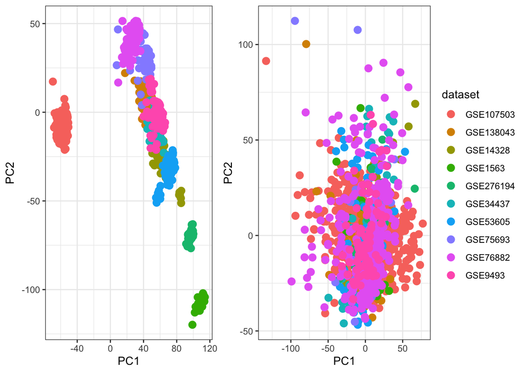

```r
ggarrange(p1, p2, ncol = 2, nrow = 1, common.legend = TRUE, legend = 'right')
```

#### Overview

- 1,182 patients
  - 381 rejected patients
  - 801 stable patients
- 7,065 genes

### Test set

#### `y_test` *(test set pData)*

```r
y_test = pGSE50084
```

#### `X_test` *(test set eMat)*

```r
# exclude any genes that are not included in the train data
X_test = eGSE50084[which(rownames(eGSE50084) %in% common_genes),]
# rearrange to match the gene order of the train data
X_test = X_test[match(common_genes, rownames(X_test)),]
```

#### Overview

- 61 patients
  - 28 rejected patients
  - 33 stable patients
- 7,065 genes

## Feature Selection

```r
# a data frame to store the performance of the models after hyper parameters are fine tuned
best_avg_perf = vector('list', length = 7)
```

### Limma

```r
# the number of significant genes to choose from
n_vals = c(10, 25, 50, 75, 100, 150, 200, 250, 300, 400, 500)
limma_perf = vector('list', length = 5 * length(n_vals))
index = 1
# create a loop for cross validation
for (i in c(1:5)) {
  # preprocess
  preproc = fs_preproc(test_fold = i)
  cv_x_train = preproc$x_train
  cv_x_test = preproc$x_test
  cv_y_train = preproc$y_train
  cv_y_test = preproc$y_test
  # feature selection (limma in this example)
  design = model.matrix(~cv_y_train$outcome)
  fit = lmFit(cv_x_train, design) |> eBayes()
  rank = topTable(fit, n = Inf)
  # loop through each possible n values
  for (n in n_vals){
    # select n top genes
    de = rownames(rank)[1:n]
    # include only n top genes in the training and the test fold
    cv_train_reduced = cv_x_train[de,]
    cv_test_reduced = cv_x_test[de,]
    # random forest built on training fold
    rf = randomForest(x = t(cv_train_reduced), y = cv_y_train$outcome)
    # evaluate model performance on the test fold
    pred_prob = predict(rf, t(cv_test_reduced), type = 'prob')[, 'reject']
    pred_class = ifelse(pred_prob > 0.5, 'reject', 'stable') |>
      factor(levels = c('stable', 'reject'))
    # roc object to calculate auc
    roc_obj = roc(response = cv_y_test$outcome, predictor = pred_prob)
    # extract model performance and store it in the comparison table
    limma_perf[[index]] = data.frame(gene_number = n,
                                     auc = auc(roc_obj) |> as.numeric())
    index = index + 1
  }
}
# calculate the overall performance of each n value
limma_perf = limma_perf |> bind_rows() |> drop_na()
limma_rank = limma_perf |>
  group_by(gene_number) |>
  summarise(mean_auc = mean(auc)) |>
  arrange(desc(mean_auc))
# visualize the performance of each n
limma_rank_long = limma_rank |>
  pivot_longer(cols = mean_auc, names_to = 'metric', values_to = 'value')
(ggplot(data = limma_rank_long,
        aes(x = gene_number, y = value)) +
    geom_line() +
    labs(x = 'Number of genes', y = 'Area Under the Curve (AUC)', title = 'Performance of Limma with different numbers of genes on Biopsy data') +
    theme_bw()) |>
  ggplotly()
```

[interactive chart not shown]

```r
limma_rank |> datatable(colnames = c('Gene number', 'Mean AUC'))
```

|  | Gene number | Mean AUC |
| --- | --- | --- |
| 1 | 500 | 0.7649819952055036 |
| 2 | 400 | 0.7622237707549916 |
| 3 | 150 | 0.7616915510177225 |
| 4 | 200 | 0.7613259454541618 |
| 5 | 300 | 0.7605898606498324 |
| 6 | 250 | 0.7590327246031071 |
| 7 | 100 | 0.7546840905539798 |
| 8 | 75 | 0.7465073173149952 |
| 9 | 50 | 0.7433627515433125 |
| 10 | 25 | 0.7353039978535827 |

[output cut: 1 more lines]

```r
# optimal n
best_avg_perf[[1]] = data.frame(method = rep('Limma', 5),
                                limma_perf |>
                                  filter(gene_number == 250))
```

### Mutual Information

```r
# storage for performance per cross validation
mi_perf = vector('list', length = 5 * length(n_vals))
index = 1
# create a loop for cross validation
for (i in c(1:5)) {
  preproc = fs_preproc(test_fold = i)
  cv_x_train = preproc$x_train
  cv_x_test = preproc$x_test
  cv_y_train = preproc$y_train
  cv_y_test = preproc$y_test
  # rank genes based on their mi score
  rank = mi_score(cv_x_train, cv_y_train)
  # loop through each possible n values
  for (n in n_vals){
    # select n top genes
    de = rank[1:n]
    # include only n top genes in the training and the test fold
    cv_x_train_reduced = cv_x_train[de,]
    cv_x_test_reduced = cv_x_test[de,]
    # random forest built on training fold
    rf = randomForest(x = t(cv_x_train_reduced), y = cv_y_train$outcome)
    # evaluate model performance on the test fold
    pred_prob = predict(rf, t(cv_x_test_reduced), type = 'prob')[,'reject']
    roc_obj = roc(response = cv_y_test$outcome, predictor = pred_prob)
    # extract model performance and store it in the comparison table
    mi_perf[[index]] = data.frame(gene_number = n,
                                  auc = auc(roc_obj) |> as.numeric())
    index = index + 1
  }
}
# calculate the overall performance of each n value
mi_perf = mi_perf |> bind_rows() |> drop_na()
mi_rank = mi_perf |>
  group_by(gene_number) |>
  summarise(mean_auc = mean(auc)) |>
  arrange(desc(mean_auc))
# visualize the performance of each n
mi_rank_long = mi_rank |>
  pivot_longer(cols = mean_auc, names_to = 'metric', values_to = 'value')
(ggplot(data = mi_rank_long, aes(x = gene_number, y = value)) +
    geom_line() +
    labs(x = 'Gene number', y = 'Area Under the Curve (AUC)', title = 'Performance of Mutual Information with different numbers of genes on Biopsy data') +
    theme_bw()) |>
  ggplotly()
```

[interactive chart not shown]

```r
mi_rank |> datatable(colnames = c('Gene number', 'Mean AUC'))
```

|  | Gene number | Mean AUC |
| --- | --- | --- |
| 1 | 300 | 0.7669773363848668 |
| 2 | 400 | 0.7647164182384567 |
| 3 | 250 | 0.7621742405925207 |
| 4 | 200 | 0.7615326294020475 |
| 5 | 150 | 0.7611654117311394 |
| 6 | 500 | 0.7611102680968879 |
| 7 | 100 | 0.7547705090129165 |
| 8 | 75 | 0.7519401633043518 |
| 9 | 50 | 0.7414094284274547 |
| 10 | 25 | 0.7344857847987457 |

[output cut: 1 more lines]

```r
# save the optimal n value
best_avg_perf[[2]] = data.frame(
  method = rep('MI', 5),
  mi_perf |> filter(gene_number == 200))
```

### Fisher score

```r
fisher_perf = vector('list', length = 5 * length(n_vals))
index = 1
# loop to do cross validation
for (i in c(1:5)) {
  preproc = fs_preproc(test_fold = i)
  cv_x_train = preproc$x_train
  cv_x_test = preproc$x_test
  cv_y_train = preproc$y_train
  cv_y_test = preproc$y_test
  fisher_scores = fisher_score(cv_x_train %>% as.matrix(), cv_y_train)
  # calculate fisher scores from the train folds
  rank = fisher_scores |> rownames()
  for (n in n_vals) {
    # select top n genes
    de = rank[1:n]
    cv_train_reduced = cv_x_train[de,]
    cv_test_reduced = cv_x_test[de,]
    # build a random forest to evaluate performance
    rf = randomForest(t(cv_train_reduced), cv_y_train$outcome)
    pred_prob = predict(rf, t(cv_test_reduced), type = 'prob')[,'reject']
    roc_obj = roc(response = cv_y_test$outcome, predictor = pred_prob)
    # extract the recall rate
    fisher_perf[[index]] = data.frame(gene_number = n,
                                      auc = auc(roc_obj) |> as.numeric())
    index = index + 1
  }
}
# calculate the overall performance of each n value
fisher_perf = fisher_perf |> bind_rows() |> drop_na()
fisher_rank = fisher_perf |>
  group_by(gene_number) |>
  summarise(mean_auc = mean(auc)) |>
  arrange(desc(mean_auc))
# visualize the performance of each n
fisher_rank_long = fisher_rank |>
  pivot_longer(cols = mean_auc, names_to = 'metric', values_to = 'value')
(ggplot(data = fisher_rank_long, aes(x = gene_number, y = value)) +
    geom_line() +
    labs(x = 'Gene number', y = 'Area Under the Curve (AUC)', title = 'Performance of Fisher score with different numbers of genes on Biopsy data') +
    theme_bw()) |>
  ggplotly()
```

[interactive chart not shown]

```r
fisher_rank |> datatable(colnames = c('Gene number', 'Mean AUC'))
```

|  | Gene number | Mean AUC |
| --- | --- | --- |
| 1 | 200 | 0.7605676591018731 |
| 2 | 300 | 0.7604634082604703 |
| 3 | 400 | 0.7559735583801928 |
| 4 | 250 | 0.7539278774999002 |
| 5 | 50 | 0.7529184969322119 |
| 6 | 150 | 0.7527152054766514 |
| 7 | 500 | 0.7518061477161954 |
| 8 | 75 | 0.7453597698154375 |
| 9 | 100 | 0.7373800051323101 |
| 10 | 25 | 0.7080814066812834 |

[output cut: 1 more lines]

```r
# retain the best performing n value
best_avg_perf[[4]] = data.frame(
  method = rep('Fisher', 5),
  fisher_perf |> filter(gene_number == 250))
```

### T-test

```r
t_test_perf = vector('list', length = 5 * length(n_vals))
index = 1
# loop for cross validation
for (i in c(1:5)) {
  # train-test folds split
  preproc = fs_preproc(test_fold = i)
  cv_x_train = preproc$x_train
  cv_x_test = preproc$x_test
  cv_y_train = preproc$y_train
  cv_y_test = preproc$y_test
  # perform t test for each gene
  t_test = apply(cv_x_train, 1, function(gene) {
    t.test(gene~cv_y_train$outcome)$p.value
  })
  # rank the gene based on their p-value
  rank = data.frame(
    row.names = rownames(cv_x_train),
    pval = t_test
  ) |> arrange(pval)
  # loop to find the optimal number of significant genes
  for (n in n_vals) {
    # select the top n genes
    de = rownames(rank)[1:n]
    cv_train_reduced = cv_x_train[de,]
    cv_test_reduced = cv_x_test[de,]
    # random forest to evaluate the feature selection method
    rf = randomForest(t(cv_train_reduced), cv_y_train$outcome)
    pred_prob = predict(rf, t(cv_test_reduced), type = 'prob')[,'reject']
    roc_obj = roc(response = cv_y_test$outcome, predictor = pred_prob)
    # extract the recall rate
    t_test_perf[[index]] = data.frame(gene_number = n,
                                      auc = auc(roc_obj) |> as.numeric())
    index = index + 1
  }
}
# calculate the overall performance of each n value
t_test_perf = t_test_perf |> bind_rows() |> drop_na()
t_test_rank = t_test_perf |>
  group_by(gene_number) |>
  summarise(mean_auc = mean(auc)) |>
  arrange(desc(mean_auc))
# visualize the performance of each n
t_test_rank_long = t_test_rank |>
  pivot_longer(cols = mean_auc, names_to = 'metric', values_to = 'value')
(ggplot(data = t_test_rank_long, aes(x = gene_number, y = value)) +
    geom_line() +
    labs(x = 'Gene number', y = 'Area Under the Curve (AUC)', title = 'Performance of T-test with different number of genes on Biopsy data') +
    theme_bw()) |>
  ggplotly()
```

[interactive chart not shown]

```r
t_test_rank |> datatable(colnames = c('Gene number', 'Mean AUC'))
```

|  | Gene number | Mean AUC |
| --- | --- | --- |
| 1 | 200 | 0.7625651399235933 |
| 2 | 300 | 0.7611614866854003 |
| 3 | 400 | 0.7606623792735249 |
| 4 | 500 | 0.7581276180501848 |
| 5 | 250 | 0.7535641043798932 |
| 6 | 150 | 0.7532420128684165 |
| 7 | 100 | 0.7499404063537058 |
| 8 | 50 | 0.7477196363899355 |
| 9 | 75 | 0.7461338046429159 |
| 10 | 25 | 0.7444341453144941 |

[output cut: 1 more lines]

```r
# retain the best performing n value
best_avg_perf[[5]] = data.frame(
  method = rep('T-test', 5),
  t_test_perf |> filter(gene_number == 400))
```

### Significance Analysis of Microarrays (SAM)

```r
sam_perf = vector('list', length = 5 * length(n_vals))
index = 1
# loop to perform cross validation
for (i in c(1:5)) {
  # train-test folds split
  preproc = fs_preproc(test_fold = i)
  cv_x_train = preproc$x_train
  cv_x_test = preproc$x_test
  cv_y_train = preproc$y_train
  cv_y_test = preproc$y_test
  # turn outcome into binary values
  bin_y_train = ifelse(cv_y_train$outcome == 'stable', 0, 1)
  # run SAM for feature selection
  sam_result = sam(cv_x_train, bin_y_train,
                   gene.names = rownames(cv_x_train))
  sam_summary = summary(sam_result, delta = 0.5)
  all_genes_sig = sam_summary@mat.sig
  rank = all_genes_sig |>
    arrange((abs(d.value)))
  # loop through possible number of significant genes
  for (n in n_vals) {
    if (n > nrow(rank)) {
      break
    }
    # select the top n genes
    de = rownames(rank)[1:n]
    cv_train_reduced = cv_x_train[de,]
    cv_test_reduced = cv_x_test[de,]
    # random forest to evaluate method performance
    rf = randomForest(t(cv_train_reduced), cv_y_train$outcome)
    pred_prob = predict(rf, t(cv_test_reduced), type = 'prob')[,'reject']
    roc_obj = roc(response = cv_y_test$outcome, predictor = pred_prob)
    # extract the method sensitivity
    sam_perf[[index]] = data.frame(gene_number = n,
                                   auc = auc(roc_obj) |> as.numeric())
    index = index + 1
  }
}
# calculate the overall performance of each n value
sam_perf = sam_perf |> bind_rows() |> drop_na()
sam_rank = sam_perf |>
  group_by(gene_number) |>
  summarise(mean_auc = mean(auc)) |>
  arrange(desc(mean_auc))
# visualize the performance of each n
sam_rank_long = sam_rank |>
  pivot_longer(cols = mean_auc, names_to = 'metric', values_to = 'value')
(ggplot(data = sam_rank_long, aes(x = gene_number, y = value)) +
    geom_line() +
    labs(x = 'Gene number', y = 'Area Under the Curve (AUC)', title = 'Performance of SAM with different numbers of genes on Biopsy data') +
    theme_bw()) |>
  ggplotly()
```

[interactive chart not shown]

```r
sam_rank |> datatable(colnames = c('Gene number', 'Mean AUC'))
```

|  | Gene number | Mean AUC |
| --- | --- | --- |
| 1 | 500 | 0.6893067300715146 |
| 2 | 400 | 0.6858564162825765 |
| 3 | 300 | 0.6777535832209934 |
| 4 | 250 | 0.6682915910086171 |
| 5 | 200 | 0.6574492829848416 |
| 6 | 150 | 0.6546329721593879 |
| 7 | 100 | 0.6526924464379698 |
| 8 | 75 | 0.6481588626329557 |
| 9 | 50 | 0.6451252027540865 |
| 10 | 25 | 0.6109729503996357 |

[output cut: 1 more lines]

```r
# retain the best performing n value
best_sam = sam_perf |>
  filter(gene_number == 500)
best_avg_perf[[6]] = data.frame(method = rep('SAM', nrow(best_sam)),
                                best_sam)
```

### Networks

```r
genes_part_1 = c('FAT1', 'CXCR2', 'CFI', 'FOLR1', 'PLS3', 'PDZK1', 'SGCE', 'RAI14', 'MITF', 'NSFL1C', 'SLC16A4', 'ATP5C1', 'TRAP1', 'PPP4R1', 'ARL1', 'BBOX1', 'TOM1L1', 'EMX2', 'NME5', 'DEFB1', 'SNX7', 'EPCAM', 'UNC13B', 'CDH16', 'TMEM47', 'IQGAP2', 'C7', 'MIPEP', 'DIP2C', 'VCAM1', 'SNX1', 'USP4', 'BAZ2B', 'EFHD1', 'CSRP2', 'EPS8', 'ENPP2', 'BCAR3', 'DNALI1', 'ABCD3', 'SPARCL1', 'HTRA1', 'CXCL12', 'GNG12', 'RBM39', 'DZIP1', 'DYNC2LI1', 'PPFIBP2', 'PTPN3', 'HPN', 'EHHADH', 'BAMBI', 'LGMN', 'ATP1B1', 'SLC16A2', 'LAMB1', 'GLDC', 'THAP11', 'PLS1', 'GUSB', 'GHR', 'LRP2', 'PSMD4', 'NCOA1', 'RCAN2', 'CDK20', 'PHYH', 'SLC22A2', 'SDC4', 'PTPRM', 'BHMT', 'MPDZ', 'SLCO2A1', 'TSPAN6', 'SPRY2', 'KDR', 'DSP', 'GALNT1', 'ESRRG', 'RARRES2', 'GPX3', 'PIR', 'PPP2R3A', 'CNN3', 'BPHL', 'PLLP', 'GNA12', 'GOT1', 'ENPEP', 'DDC', 'CLDN10', 'PCK1', 'CRYZ', 'LAMB2', 'GRB14', 'SULT1C2', 'ZNF204P', 'CTGF', 'PARM1', 'RND3', 'DPYS', 'PTH1R', 'TNFRSF21', 'HADH', 'BUB3', 'WWTR1', 'SYNCRIP', 'HSD11B2', 'HCK', 'SLC1A1', 'DSG2', 'RABGGTB', 'NPY1R', 'COX7B', 'PFN2', 'AHCYL1', 'FDPS', 'KL', 'MEIS2', 'PCGF2', 'ABCB1', 'ACOX2', 'RIOK3', 'FMO1', 'PARD3', 'HOXC6', 'PPBP', 'ANP32A', 'RGN', 'HYAL1', 'PCBD1', 'FZD6', 'TSPAN1', 'PRRG1', 'SLC27A2', 'AKR7A3', 'FAM107A', 'LUM', 'HLF', 'PTS', 'BMPR1A', 'BCL2L2', 'USP9X', 'PBX3', 'S100A12', 'ATP6AP2', 'FDX1', 'TBX2', 'MALL', 'MUT', 'SMAD1', 'GLYAT', 'SIM1', 'PRSS8', 'AOX1', 'TXNDC9', 'SDC1', 'RAB40B', 'PPP2R2A', 'ACADL', 'UBE2E1', 'PLAT', 'SOCS6', 'KCNJ1', 'CDH5', 'HOXB7', 'ILVBL', 'CLDN8', 'TSPYL5', 'FNBP1L', 'NCF2', 'NEDD4L', 'CELSR2', 'GPC4', 'PSMB1', 'PPP3CB', 'LAMC1', 'EML1', 'MYO1B', 'GSTM3', 'AGT', 'CADM1', 'MSH3', 'NCKAP1', 'PTOV1', 'GGH', 'COBL', 'FGR', 'LDOC1', 'NR2F2', 'MTX2', 'FBXL2', 'GNAI1', 'UMOD', 'EPB42', 'HOXA4', 'CRYM', 'NR2F1', 'STK17B', 'ANPEP', 'RIN2', 'SLC17A3', 'COL4A2', 'KRT18', 'PAX2', 'CUBN', 'SERPINA5', 'THY1', 'FZD7', 'CCND1', 'YAP1', 'HNF1B', 'SLC6A13', 'IQSEC1', 'SHANK2', 'PLEKHA6', 'PRODH2', 'LDB2', 'TSPAN8', 'PPIC', 'FARP2', 'UCHL1', 'TRIL', 'PLCG2', 'HSPA12A', 'SPA17', 'AQP9', 'FMO4', 'IQCK', 'MLF1', 'TRAF3IP1', 'ARNT2', 'ASAH1', 'ITGA2', 'GUCY1B3', 'AMOTL2', 'ETS2', 'VNN2', 'CHL1', 'SPR', 'NDUFA5', 'MNDA', 'JRKL', 'MYH10', 'RAB11FIP5', 'NID2', 'MCFD2', 'UBE3A', 'PTN', 'EPHX2', 'TLN2', 'APOM', 'PPL', 'MYO6', 'EFNA1', 'ATP5H', 'HSD17B4', 'RHOC', 'SLIT2', 'PGRMC2', 'PLOD2', 'ACO2', 'ABI1', 'MXRA5', 'CAV2', 'AIFM1', 'SPOCK1', 'FBXO7', 'FERMT2', 'SH3GL2', 'ATRN', 'DNMBP', 'ATP8B1', 'GLI3', 'VLDLR', 'SPAG5', 'SHROOM2', 'MAPK10', 'RALYL', 'PROS1', 'DIO1', 'PODXL', 'AGAP1', 'EPAS1', 'NEO1', 'CD34', 'DAO', 'NLGN1', 'C1R', 'ALKBH1', 'USH1C', 'ALAS2', 'HSPA2', 'RGL1', 'SUPT7L', 'TTLL1', 'GJB1', 'ALDH6A1', 'FAH', 'SNAI2', 'SERPINA6', 'ERBB3', 'SFRP1', 'CLCN5', 'SALL1', 'EDNRB', 'TNFRSF11B', 'GGCX', 'ANK3', 'WASF3', 'GNAS', 'MYO1F', 'ADH6', 'PROCR', 'PFKM', 'MNAT1', 'SOD3', 'NPR3', 'DNAJC22', 'HMGB3', 'FBLN5', 'TPD52L1', 'NUPR1', 'ENPP4', 'TMCC1', 'EIF3K', 'AFG3L2', 'DIRAS3', 'BUD31', 'NINL', 'ETFDH', 'IGFBP4', 'OLFML2A', 'ARHGEF5', 'PROM1', 'PTPRG', 'GAS2L1', 'TRAM2', 'COX7A1', 'TYMS', 'FGF9', 'MAOB', 'EI24', 'PPARG', 'CX3CL1', 'RNF40', 'NUFIP1')
genes_part_2 = c('PITRM1', 'NET1', 'PGRMC1', 'HOXA5', 'SSX2IP', 'S100A9', 'CA12', 'UPK1B', 'RUNDC3B', 'PARVA', 'SERPINF2', 'GSTA4', 'SLC35A3', 'DICER1', 'PHLDA1', 'ATP2C1', 'B9D1', 'KPNA4', 'TJP1', 'PKD2', 'TCFL5', 'EPHA2', 'SUOX', 'STARD13', 'BCKDHB', 'UBE2D2', 'GYPC', 'B4GALT3', 'DPEP1', 'MUC1', 'FRAT2', 'SHC1', 'CAP2', 'CRELD1', 'ICMT', 'SELL', 'TCN2', 'HSPA4L', 'NUAK1', 'APOE', 'ANXA9', 'AQP1', 'ZFYVE9', 'LRBA', 'C11orf58', 'CFP', 'GEM', 'ARF3', 'BPTF', 'EXTL2', 'CPSF6', 'RWDD2A', 'VRK2', 'LGALS3BP', 'PSTPIP1', 'PARP2', 'FAM189A2', 'DNAJC8', 'SLC6A12', 'MCAM', 'ACTR3', 'DLD', 'PIK3C2G', 'IVNS1ABP', 'ING2', 'TIMP3', 'TBC1D2B', 'NDUFS1', 'HOMER1', 'PHB', 'RAPGEF3', 'ARSE', 'TTC28', 'GCLC', 'MMACHC', 'SPRY1', 'TOMM34', 'ZNF10', 'SEMA5A', 'XPNPEP2', 'UROS', 'MXRA8', 'CRTAP', 'PGM3', 'CALB1', 'CAV1', 'MAPT', 'NLRP1', 'NIT1', 'ALDH7A1', 'PPP1R1A', 'VDAC1', 'IFT88', 'HNF1A', 'ADH1C', 'MMP7', 'RHOBTB1', 'METTL1', 'KLKB1', 'TEAD3', 'DFNA5', 'BTBD3', 'IMMT', 'AASS', 'NCF4', 'NDN', 'ATP1A1', 'IGFBP5', 'AIMP1', 'LIMCH1', 'ITGB5', 'MTR', 'PRPF40A', 'LYN', 'SLC22A6', 'UGDH', 'MAOA', 'SCAMP5', 'PHF3', 'IGFBP3', 'PCDH17', 'S100P', 'IKZF1', 'PTPRD', 'MEGF9', 'SEPT10', 'GMPS', 'CTSF', 'MAPRE2', 'SUCLA2', 'HIBCH', 'ECHS1', 'SLC5A12', 'FKBP4', 'AR', 'AZGP1', 'RNH1', 'DNAJC6', 'AUH', 'PTP4A1', 'VEGFC', 'FCN1', 'CYLD', 'MRPS14', 'CXorf40A', 'CLIC4', 'FABP3', 'ARMCX2', 'THRB', 'EFEMP2', 'SLC2A2', 'KCNJ8', 'SOX9')
network_rank = c(genes_part_1, genes_part_2)
```

```r
networks_perf = vector('list', length = 5 * length(n_vals))
index = 1
# loop to perform cross validation
for (i in c(1:5)) {
  # train-test folds split
  preproc = fs_preproc(test_fold = i)
  cv_x_train = preproc$x_train
  cv_x_test = preproc$x_test
  cv_y_train = preproc$y_train
  cv_y_test = preproc$y_test
  # loop to select optimal number of significant genes
  for (n in n_vals) {
    # select the top n genes
    de = network_rank[1:n]
    cv_train_reduced = cv_x_train[de,]
    cv_test_reduced = cv_x_test[de,]
    # random forest to evaluate the feature selectin method
    rf = randomForest(t(cv_train_reduced), cv_y_train$outcome)
    pred_prob = predict(rf, t(cv_test_reduced), type = 'prob')[,'reject']
    roc_obj = roc(response = cv_y_test$outcome, predictor = pred_prob)
    # extract sensitivity
    networks_perf[[index]] = data.frame(gene_number = n,
                               auc = auc(roc_obj) |> as.numeric())
    index = index + 1
  }
}
# calculate the overall performance of each n value
networks_perf = networks_perf |> bind_rows() |> drop_na()
networks_rank = networks_perf |>
  group_by(gene_number) |>
  summarise(mean_auc = mean(auc)) |>
  arrange(desc(mean_auc))
# visualize the performance of each n
networks_rank_long = networks_rank |>
  pivot_longer(cols = mean_auc, names_to = 'metric', values_to = 'value')
(ggplot(data = networks_rank_long, aes(x = gene_number, y = value)) +
    geom_line() +
    labs(x = 'Gene number', y = 'Area Under the Curve (AUC)', title = 'Performance of Networks with different numbers of genes on Biopsy data') +
    theme_bw()) |>
  ggplotly()
```

[interactive chart not shown]

```r
networks_rank |> datatable(colnames = c('Gene number', 'Mean AUC'))
```

|  | Gene number | Mean AUC |
| --- | --- | --- |
| 1 | 250 | 0.7487309165468949 |
| 2 | 500 | 0.7460064284283391 |
| 3 | 300 | 0.7368864058727829 |
| 4 | 400 | 0.7331402221838236 |
| 5 | 200 | 0.728107312786676 |
| 6 | 150 | 0.7268253512420684 |
| 7 | 100 | 0.7225870531745625 |
| 8 | 50 | 0.7093195631313386 |
| 9 | 75 | 0.7071533695736989 |
| 10 | 25 | 0.675480780384263 |

[output cut: 1 more lines]

```r
# retain the best performing n value
best_avg_perf[[7]] = data.frame(method = rep('Network', 5),
                                networks_perf |>
                                  filter(gene_number == 250))
```

### Comparative Boxplots

```r
best_avg_perf = best_avg_perf |> bind_rows()
best_avg_perf_long = best_avg_perf |>
  pivot_longer(cols = auc, names_to = 'metric', values_to = 'value')
p3 = ggplot(best_avg_perf_long, aes(x = factor(method), y = value, fill = gene_number)) +
  geom_boxplot() +
  labs(
    title = 'A. Biopsy',
    y = 'Area Under Curve (AUC)', x = 'Feature Selection Methods'
  ) +
  scale_fill_gradient(
    name = 'Gene Number',
    low = 'white',
    high = 'black'
  ) +
  theme_bw()
p3 |> ggplotly()
```

[interactive chart not shown]

```r
best_avg_perf %>%
  group_by(method, gene_number) %>%
  summarise(mean_auc = mean(auc)) %>%
  arrange(desc(mean_auc)) |>
  datatable(colnames = c('Method', 'Gene number', 'Mean AUC'))
```

|  | Method | Gene number | Mean AUC |
| --- | --- | --- | --- |
| 1 | MI | 200 | 0.7615326294020475 |
| 2 | T-test | 400 | 0.7606623792735249 |
| 3 | Limma | 250 | 0.7590327246031071 |
| 4 | Fisher | 250 | 0.7539278774999002 |
| 5 | Network | 250 | 0.7487309165468949 |
| 6 | SAM | 500 | 0.6893067300715146 |

## Model Selection

```r
model_selection = vector('list', length = 8)
```

### k-Nearest Neighbours (kNN)

```r
k_vals = c(1, 3, 5, 7, 10, 15, 25)
knn_perf = vector('list', 5 * length(k_vals) * length(thresholds))
index = 1
for (i in 1:5) {
  preproc = biopsy_preproc(test_fold = i)
  cv_train_reduced = preproc$x_train
  cv_test_reduced = preproc$x_test
  cv_y_train = preproc$y_train
  cv_y_test = preproc$y_test
  for (k in k_vals) {
    knn = knn3(t(cv_train_reduced), cv_y_train$outcome, k = k)
    pred_prob = predict(knn, t(cv_test_reduced))[,'reject']
    for (t in thresholds) {
    pred_class = ifelse(pred_prob > t, 'reject', 'stable') %>%
      factor(levels = c('stable', 'reject'))
    conf_mat = confusionMatrix(data = pred_class,
                              reference = cv_y_test$outcome, positive = 'reject')
    knn_perf[[index]] = data.frame(k = k, threshold = t,
                                  f1 = conf_mat$byClass['F1'],
                                  f2 = f2(pred_class, cv_y_test))
    index = index + 1
    }
  }
}
knn_perf = bind_rows(knn_perf)
knn_rank = knn_perf |>
  group_by(k, threshold) |>
  summarise(mean_f1 = mean(f1),
            mean_f2 = mean(f2)) |>
  arrange(desc(0.4 * mean_f1 + 0.6 * mean_f2), threshold)
knn_rank_long = knn_rank |>
  pivot_longer(cols = mean_f1:mean_f2, names_to = 'metric', values_to = 'value')
knn_rank |> datatable(colnames = c('k', 'threshold', 'mean F1 score', 'mean F2 score'))
```

|  | k | threshold | mean F1 score | mean F2 score |
| --- | --- | --- | --- | --- |
| 1 | 3 | 0.3 | 0.5611909514112391 | 0.6893012655849101 |
| 2 | 25 | 0.3 | 0.5819462754515448 | 0.6748484215406214 |
| 3 | 5 | 0.3 | 0.5839570468000297 | 0.6682153190746417 |
| 4 | 5 | 0.35 | 0.5824223629449039 | 0.6660999252398462 |
| 5 | 10 | 0.3 | 0.5960262907030258 | 0.6552960795308916 |
| 6 | 10 | 0.35 | 0.5960262907030258 | 0.6552960795308916 |
| 7 | 15 | 0.3 | 0.5771077841106322 | 0.6644153092027757 |
| 8 | 7 | 0.4 | 0.5906400941866189 | 0.6489544800467427 |
| 9 | 7 | 0.3 | 0.5899076298787357 | 0.6485991782208527 |
| 10 | 7 | 0.35 | 0.5899076298787357 | 0.6485991782208527 |

[output cut: 53 more lines]

```r
model_selection[[1]] = data.frame(method = rep('KNN', 5),
                                  knn_perf |>
                                    filter(k == knn_rank$k[1]) |>
                                    filter(threshold == knn_rank$threshold[1]) |>
                                    select(-c(k, threshold)))
```

### Random Forest

```r
set.seed(3888)
mtry_vals = c(1, 2, 5)
min.node.sizes = c(1, 2, 5)
rf_perf = vector('list', length = 5 * length(thresholds) * length(mtry_vals) * length(min.node.sizes))
index = 1
for (i in c(1:5)) {
  preproc = biopsy_preproc(test_fold = i)
  cv_train_reduced = preproc$x_train
  cv_test_reduced = preproc$x_test
  cv_y_train = preproc$y_train
  cv_y_test = preproc$y_test
  cv_train_t = t(cv_train_reduced) |> data.frame()
  cv_train_t$outcome = cv_y_train$outcome
  for (mtry in mtry_vals) {
    for (node in min.node.sizes) {
      rf = ranger(outcome ~ ., data = cv_train_t,
                  mtry = mtry, min.node.size = node,
                  probability = TRUE, splitrule = 'extratrees',
                  classification = TRUE, scale = TRUE)
      for (t in thresholds) {
        pred_prob = predict(rf, data.frame(t(cv_test_reduced)),
                        type = 'response')$predictions[,'reject']
        pred_class = ifelse(pred_prob > t, 'reject', 'stable') |>
          factor(levels = c('stable', 'reject'))
        conf_mat = confusionMatrix(pred_class, cv_y_test$outcome)
        rf_perf[[index]] = data.frame(mtry = mtry, min_node_size = node, threshold = t,
                                      f1 = conf_mat$byClass['F1'],
                                      f2 = f2(pred_class, cv_y_test))
        index = index + 1
      }
    }
  }
}
rf_perf = bind_rows(rf_perf)
rf_perf_rank = rf_perf |>
  group_by(mtry, min_node_size, threshold) |>
  summarise(mean_f1 = mean(f1, na.rm = TRUE),
            mean_f2 = mean(f2, na.rm = TRUE))|>
  arrange(desc(0.4 * mean_f1 + 0.6 * mean_f2))
rf_perf_rank_long = rf_perf_rank |>
  pivot_longer(cols = mean_f1:mean_f2, names_to = 'metric', values_to = 'value')
rf_perf_rank |> datatable(colnames = c('mtry', 'min.node.size', 'threshold', 'mean F1 score', 'mean F2 score'))
```

|  | mtry | min.node.size | threshold | mean F1 score | mean F2 score |
| --- | --- | --- | --- | --- | --- |
| 1 | 2 | 5 | 0.3 | 0.7269849505068179 | 0.6746237753210592 |
| 2 | 5 | 1 | 0.3 | 0.7305369932188023 | 0.6721571454179813 |
| 3 | 2 | 1 | 0.3 | 0.7250703495365352 | 0.6666847533164844 |
| 4 | 5 | 5 | 0.3 | 0.7227711902626802 | 0.6659385737136819 |
| 5 | 1 | 5 | 0.3 | 0.7261388677123052 | 0.6595483314396019 |
| 6 | 1 | 1 | 0.3 | 0.7270036297194615 | 0.6578812861798125 |
| 7 | 2 | 2 | 0.3 | 0.7279933072091122 | 0.6557890141338554 |
| 8 | 5 | 2 | 0.3 | 0.7101787368716763 | 0.655766726751655 |
| 9 | 1 | 2 | 0.3 | 0.7154598905843007 | 0.6483674934410315 |
| 10 | 5 | 5 | 0.35 | 0.7839540982882738 | 0.5957237932874737 |

[output cut: 71 more lines]

```r
model_selection[[2]]= data.frame(method = rep('RF', 5),
                          rf_perf |>
                            filter(mtry == rf_perf_rank$mtry[1]) |>
                            filter(min_node_size == rf_perf_rank$min_node_size[1]) |>
                            filter(threshold == rf_perf_rank$threshold[1]) |>
                            select(-c(mtry, min_node_size, threshold)))
```

### Logistic Regression

```r
lambda_grid = 10^seq(-5, 0, length = 10)
alpha_values = c(0.1, 0.4, 0.6, 0.9)
log_perf = vector('list', length = 5 * length(lambda_grid) * length(alpha_values) * length(thresholds))
index = 1
for (i in c(1:5)) {
  preproc = biopsy_preproc(test_fold = i)
  cv_train_reduced = preproc$x_train
  cv_test_reduced = preproc$x_test
  cv_y_train = preproc$y_train
  cv_y_test = preproc$y_test
  for (lambda in lambda_grid) {
    for (a in alpha_values) {
      lr = glmnet(t(cv_train_reduced), cv_y_train$outcome, family = 'binomial',
                  alpha = a, lambda = lambda, standardize = FALSE)
      pred_prob = predict(lr, t(cv_test_reduced), type = 'response')[,1]
      for (t in thresholds) {
        pred_class = ifelse(pred_prob > t, 'reject', 'stable') |>
          factor(levels = c('stable', 'reject'))
        conf_mat = confusionMatrix(cv_y_test$outcome, pred_class, positive = 'reject')
        log_perf[[index]] = data.frame(lambda = lambda, alpha = a, threshold = t,
                                       f1 = conf_mat$byClass['F1'],
                                       f2 = f2(pred_class, cv_y_test))
        index = index + 1
      }
    }
  }
}
log_perf = bind_rows(log_perf)
log_perf_rank = log_perf |>
  group_by(lambda, alpha, threshold) |>
  summarise(mean_f1 = mean(f1, na.rm = TRUE),
            mean_f2 = mean(f2, na.rm = TRUE)) |>
  arrange(desc(0.4 * mean_f1 + 0.6 * mean_f2))
log_perf_rank_long = log_perf_rank |>
  pivot_longer(cols = mean_f1:mean_f2, names_to = 'metric', values_to = 'value')
log_perf_rank |> datatable(colnames = c('lambda', 'alpha', 'threshold', 'mean F1 score', 'mean F2 score'))
```

|  | lambda | alpha | threshold | mean F1 score | mean F2 score |
| --- | --- | --- | --- | --- | --- |
| 1 | 1 | 0.1 | 0.3 | 0.5569449686344353 | 0.6977297877640795 |
| 2 | 0.07742636826811278 | 0.9 | 0.3 | 0.5782235323873626 | 0.6790424822959932 |
| 3 | 0.07742636826811278 | 0.1 | 0.3 | 0.5903303875919794 | 0.6558487728103535 |
| 4 | 0.02154434690031885 | 0.1 | 0.3 | 0.5926878951618836 | 0.6542754455928265 |
| 5 | 0.07742636826811278 | 0.6 | 0.3 | 0.578726232902429 | 0.661805118264431 |
| 6 | 0.2782559402207126 | 0.4 | 0.3 | 0.5433786080571307 | 0.6845354101580862 |
| 7 | 0.2782559402207126 | 0.1 | 0.3 | 0.5793917796624445 | 0.6594659182518148 |
| 8 | 0.07742636826811278 | 0.4 | 0.3 | 0.5805861318762876 | 0.6562181487783527 |
| 9 | 0.02154434690031885 | 0.4 | 0.3 | 0.5823420399968771 | 0.6465765873102467 |
| 10 | 0.005994842503189409 | 0.6 | 0.3 | 0.582789579032126 | 0.6411398026560519 |

[output cut: 350 more lines]

```r
model_selection[[3]] = data.frame(method = rep('LR', 5),
                                  log_perf |>
                                     filter(lambda == log_perf_rank$lambda[1]) |>
                                     filter(alpha == log_perf_rank$alpha[1]) |>
                                     filter(threshold == log_perf_rank$threshold[1]) |>
                                     select(-c(lambda, alpha, threshold)))
```

### SVM

#### SVM Linear

```r
C_vals = 2^(-2:2)
svm_linear_perf = vector('list', length = 5 * length(C_vals) * length(thresholds))
index = 1
for (i in c(1:5)) {
  preproc = biopsy_preproc(test_fold = i)
  cv_train_reduced = preproc$x_train
  cv_test_reduced = preproc$x_test
  cv_y_train = preproc$y_train
  cv_y_test = preproc$y_test
  for (c in C_vals) {
    svm = svm(x = t(cv_train_reduced), y = cv_y_train$outcome,
              cost = c, kernel = 'linear', probability = TRUE)
    pred_prob = predict(svm, t(cv_test_reduced), probability = TRUE) %>%
      attr('probabilities')
    pred_prob = pred_prob[,'reject']
    for (t in thresholds) {
      pred_class = ifelse(pred_prob > t, 'reject', 'stable') %>%
        factor(levels = c('stable', 'reject'))
      conf_mat = confusionMatrix(data = pred_class,
                                reference = cv_y_test$outcome, positive = 'reject')
      svm_linear_perf[[index]] = data.frame(C = c, threshold = t,
                                            f1 = conf_mat$byClass['F1'],
                                            f2 = f2(pred_class, cv_y_test))
      index = index + 1
    }
  }
}
svm_linear_perf = bind_rows(svm_linear_perf)
svm_linear_rank = svm_linear_perf %>%
  group_by(C, threshold) %>%
  summarise(mean_f1 = mean(f1),
            mean_f2 = mean(f2)) %>%
  arrange(desc(0.4 * mean_f1 + 0.6 * mean_f2))
svm_linear_rank |> datatable(colnames = c('C', 'threshold', 'mean F1 score', 'mean F2 score'))
```

|  | C | threshold | mean F1 score | mean F2 score |
| --- | --- | --- | --- | --- |
| 1 | 4 | 0.3 | 0.5627504113505895 | 0.6558201504802824 |
| 2 | 2 | 0.3 | 0.5657274457304685 | 0.6497648119484106 |
| 3 | 1 | 0.3 | 0.5575794210504667 | 0.6427452300553244 |
| 4 | 0.25 | 0.3 | 0.557409383069477 | 0.6312393919339102 |
| 5 | 0.5 | 0.3 | 0.5519050294589879 | 0.6297444261437678 |
| 6 | 4 | 0.35 | 0.5472864233834158 | 0.5603905679731342 |
| 7 | 0.25 | 0.35 | 0.5406088664421997 | 0.5574919885395331 |
| 8 | 0.5 | 0.35 | 0.5412955780972275 | 0.5517110336504052 |
| 9 | 2 | 0.35 | 0.5402784336929242 | 0.5511847683940914 |
| 10 | 1 | 0.35 | 0.5337191927289303 | 0.5453035870906344 |

[output cut: 35 more lines]

```r
model_selection[[4]] = data.frame(method = rep('SVM-L', 5),
                                  svm_linear_perf %>%
                                     filter(C == svm_linear_rank$C[1]) %>%
                                     filter(threshold == svm_linear_rank$threshold[1]) |>
                                     select(-c(C, threshold)))
```

#### SVM Radial

```r
gamma_vals = 2^c(-10, -5, 0, 5, 10)
svm_radial_perf = vector('list', length = 5 * length(C_vals) * length(gamma_vals) * length(thresholds))
index = 1
for (i in c(1:5)) {
  preproc = biopsy_preproc(test_fold = i)
  cv_train_reduced = preproc$x_train
  cv_test_reduced = preproc$x_test
  cv_y_train = preproc$y_train
  cv_y_test = preproc$y_test
  for (c in C_vals) {
    for (gamma in gamma_vals) {
      svm = svm(x = t(cv_train_reduced), y = cv_y_train$outcome,
                cost = c, kernel = 'radial', gamma = gamma, probability = TRUE)
      pred_prob = predict(svm, t(cv_test_reduced), probability = TRUE) %>%
        attr('probabilities')
      pred_prob = pred_prob[,'reject']
      for (t in thresholds) {
        pred_class = ifelse(pred_prob > t, 'reject', 'stable') %>%
          factor(levels = c('stable', 'reject'))
        conf_mat = confusionMatrix(data = pred_class,
                                  reference = cv_y_test$outcome, positive = 'reject')
        svm_radial_perf[[index]] = data.frame(C = c, gamma = gamma, threshold = t,
                                              f1 = conf_mat$byClass['F1'],
                                              f2 = f2(pred_class, cv_y_test))
        index = index + 1
      }
    }
  }
}
svm_radial_perf = bind_rows(svm_radial_perf)
svm_radial_rank = svm_radial_perf %>%
  group_by(C, gamma, threshold) %>%
  summarise(mean_f1 = mean(f1),
            mean_f2 = mean(f2)) %>%
  arrange(desc(0.4 * mean_f1 + 0.6 * mean_f2))
svm_radial_rank |>
  datatable(colnames = c('C', 'gamma', 'threshold', 'mean F1 score', 'mean F2 score'))
```

|  | C | gamma | threshold | mean F1 score | mean F2 score |
| --- | --- | --- | --- | --- | --- |
| 1 | 4 | 0.03125 | 0.3 | 0.566286406425047 | 0.6933474172573368 |
| 2 | 4 | 0.0009765625 | 0.3 | 0.6135599045604999 | 0.6572599858514042 |
| 3 | 2 | 0.03125 | 0.3 | 0.5632043408647472 | 0.6902426609996326 |
| 4 | 1 | 0.03125 | 0.3 | 0.559539694306188 | 0.6858927652453147 |
| 5 | 0.5 | 0.03125 | 0.3 | 0.5591555528263356 | 0.6855902607604772 |
| 6 | 0.25 | 0.03125 | 0.3 | 0.5581066732010128 | 0.6850144796166416 |
| 7 | 0.25 | 0.03125 | 0.35 | 0.6146394754586972 | 0.6410717276619463 |
| 8 | 0.5 | 0.03125 | 0.35 | 0.6144703013739171 | 0.6411370976320256 |
| 9 | 1 | 0.03125 | 0.35 | 0.6153003090805356 | 0.6399778202798933 |
| 10 | 2 | 0.03125 | 0.35 | 0.6084011487380466 | 0.6339894977129378 |

[output cut: 215 more lines]

```r
model_selection[[5]] = data.frame(method = rep('SVM-R', 5),
                                  svm_radial_perf %>%
                                     filter(C == svm_radial_rank$C[1]) %>%
                                     filter(gamma == svm_radial_rank$gamma[1]) %>%
                                     filter(threshold == svm_radial_rank$threshold[1]) |>
                                     select(-c(C, gamma, threshold)))
```

#### SVM Polynomial

```r
degrees = c(2,3,4)
zero_coef = c(0, 1, 10)
svm_poly_perf = vector('list', length = 5 * length(degrees) * length(zero_coef) * length(thresholds) * length(C_vals))
index = 1
for (i in c(1:5)) {
  preproc = biopsy_preproc(test_fold = i)
  cv_train_reduced = preproc$x_train
  cv_test_reduced = preproc$x_test
  cv_y_train = preproc$y_train
  cv_y_test = preproc$y_test
  for (c in C_vals) {
    for (d in  degrees) {
      for (z in zero_coef) {
        svm = svm(x = t(cv_train_reduced), y = cv_y_train$outcome,
                        cost = c, kernel = 'polynomial', degree = d,
                        coef0 = z, probability = TRUE)
        pred_prob = predict(svm, t(cv_test_reduced), probability = TRUE) %>%
          attr('probabilities')
        pred_prob = pred_prob[,'reject']
        for (t in thresholds) {
          pred_class = ifelse(pred_prob > t, 'reject', 'stable') %>%
            factor(levels = c('stable', 'reject'))
          conf_mat = confusionMatrix(data = pred_class,
                                    reference = cv_y_test$outcome,
                                    positive = 'reject')
          svm_poly_perf[[index]] = data.frame(C = c, degree = d, coef0 = z,
                                              threshold = t,
                                              f1 = conf_mat$byClass['F1'],
                                              f2 = f2(pred_class, cv_y_test))
          index = index + 1
        }
      }
    }
  }
}
svm_poly_perf = bind_rows(svm_poly_perf)
svm_poly_rank = svm_poly_perf %>%
  group_by(C, degree, coef0, threshold) %>%
  summarise(mean_f1 = mean(f1),
            mean_f2 = mean(f2)) %>%
  arrange(desc(0.4 * mean_f1 + 0.6 * mean_f2))
svm_poly_rank |>
  datatable(colnames = c('C', 'degree', 'coef0', 'threshold',
                         'mean F1 score', 'mean F2 score'))
```

|  | C | degree | coef0 | threshold | mean F1 score | mean F2 score |
| --- | --- | --- | --- | --- | --- | --- |
| 1 | 0.5 | 2 | 1 | 0.3 | 0.6265342530404431 | 0.6703367306709964 |
| 2 | 0.25 | 3 | 1 | 0.3 | 0.6222356142325204 | 0.6581605543238392 |
| 3 | 0.5 | 4 | 1 | 0.3 | 0.6039984183571793 | 0.6679606613524267 |
| 4 | 2 | 4 | 1 | 0.3 | 0.5987176944718844 | 0.6707547589995725 |
| 5 | 4 | 3 | 1 | 0.3 | 0.5972241724067097 | 0.6698622452563822 |
| 6 | 1 | 4 | 1 | 0.3 | 0.6006230555619794 | 0.6663841727299277 |
| 7 | 0.5 | 3 | 1 | 0.3 | 0.6088311955192962 | 0.6590794487032602 |
| 8 | 0.5 | 2 | 10 | 0.3 | 0.59693663916594 | 0.663127111113954 |
| 9 | 2 | 3 | 1 | 0.3 | 0.5963954080938045 | 0.6629287100699445 |
| 10 | 1 | 2 | 10 | 0.3 | 0.5912448867319616 | 0.6642645621419337 |

[output cut: 395 more lines]

```r
model_selection[[6]] = data.frame(method = rep('SVM-P', 5),
                                  svm_poly_perf %>%
                                     filter(C == svm_poly_rank$C[1]) %>%
                                     filter(degree == svm_poly_rank$degree[1]) %>%
                                     filter(coef0 == svm_poly_rank$coef0[1]) %>%
                                     filter(threshold == svm_poly_rank$threshold[1]) |>
                                     select(-c(C, degree, coef0, threshold)))
```

#### SVM Sigmoid

```r
svm_sigmoid_perf = vector('list', length = 5 * length(thresholds) * length(C_vals) * length(gamma_vals) * length(zero_coef))
index = 1
for (i in c(1:5)) {
  preproc = biopsy_preproc(test_fold = i)
  cv_train_reduced = preproc$x_train
  cv_test_reduced = preproc$x_test
  cv_y_train = preproc$y_train
  cv_y_test = preproc$y_test
  for (c in C_vals) {
    for(g in gamma_vals) {
      for (z in zero_coef) {
        svm = svm(x = t(cv_train_reduced), y = cv_y_train$outcome,
                        cost = c, kernel = 'sigmoid', gamma = g,
                        coef0 = z, probability = TRUE)
        pred_prob = predict(svm, t(cv_test_reduced), probability = TRUE) %>%
          attr('probabilities')
        pred_prob = pred_prob[,'reject']
        for (t in thresholds) {
          pred_class = ifelse(pred_prob > t, 'reject', 'stable') %>%
            factor(levels = c('stable', 'reject'))
          conf_mat = confusionMatrix(data = pred_class,
                                    reference = cv_y_test$outcome,
                                    positive = 'reject')
          svm_sigmoid_perf[[index]] = data.frame(C = c, gamma = g, coef0 = z, threshold = t,
                                                 f1 = conf_mat$byClass['F1'],
                                                 f2 = f2(pred_class, cv_y_test))
          index = index + 1
        }
      }
    }
  }
}
svm_sigmoid_perf = svm_sigmoid_perf |> bind_rows()
svm_sigmoid_rank = svm_sigmoid_perf %>%
  group_by(C, gamma, coef0, threshold) %>%
  summarise(mean_f1 = mean(f1),
            mean_f2 = mean(f2)) %>%
  arrange(desc(0.4 * mean_f1 + 0.6 * mean_f2))
svm_sigmoid_rank |>
  datatable(colnames = c('C', 'gamma', 'coef0', 'threshold', 'mean F1 score', 'mean F2 score'))
```

|  | C | gamma | coef0 | threshold | mean F1 score | mean F2 score |
| --- | --- | --- | --- | --- | --- | --- |
| 1 | 0.25 | 0.0009765625 | 10 | 0.3 | 0.5565360281012091 | 0.692247884623368 |
| 2 | 0.5 | 0.0009765625 | 10 | 0.3 | 0.5551390431765859 | 0.6902397426198222 |
| 3 | 1 | 0.0009765625 | 1 | 0.3 | 0.5734523087993136 | 0.6773844694278762 |
| 4 | 0.5 | 0.0009765625 | 1 | 0.3 | 0.5736689099622966 | 0.6739535036615314 |
| 5 | 2 | 0.0009765625 | 1 | 0.3 | 0.5653488857590396 | 0.6776936356353203 |
| 6 | 0.25 | 0.0009765625 | 1 | 0.3 | 0.568418589567207 | 0.6722811603973139 |
| 7 | 1 | 0.0009765625 | 0 | 0.3 | 0.589783835494716 | 0.6551651390368987 |
| 8 | 2 | 0.0009765625 | 0 | 0.3 | 0.5860287852829502 | 0.6517341283939379 |
| 9 | 0.5 | 0.0009765625 | 0 | 0.3 | 0.5765368693309936 | 0.6404915865983692 |
| 10 | 1 | 0.0009765625 | 1 | 0.35 | 0.5739365228423403 | 0.6417591408439631 |

[output cut: 665 more lines]

```r
model_selection[[7]] = data.frame(method = rep('SVM-S', 5),
                                  svm_sigmoid_perf %>%
                                     filter(C == svm_sigmoid_rank$C[1]) %>%
                                     filter(gamma == svm_sigmoid_rank$gamma[1]) %>%
                                     filter(coef0 == svm_sigmoid_rank$coef0[1]) %>%
                                     filter(threshold == svm_sigmoid_rank$threshold[1]) |>
                                     select(-c(C, gamma, coef0, threshold)))
```

### XGBoost

```r
eta_vals = c(0.05, 0.1, 0.3, 0.5, 0.8)
max_depth_vals = c(1,4,5,7,8)
nrounds = c(10, 15, 20, 30, 50, 75, 100)
xgb_perf = vector('list', length = 5 * length(eta_vals) * length(max_depth_vals) * length(nrounds))
index = 1
for (i in c(1:5)) {
  preproc = biopsy_preproc(test_fold = i)
  cv_train_reduced = preproc$x_train
  cv_test_reduced = preproc$x_test
  cv_y_train = preproc$y_train
  cv_y_test = preproc$y_test
  dtrain = xgb.DMatrix(data = t(cv_train_reduced),
                       label = ifelse(cv_y_train$outcome == 'stable', 0, 1))
  dtest = xgb.DMatrix(data = t(cv_test_reduced))
  for(e in eta_vals) {
    for (d in max_depth_vals) {
      for (n in nrounds) {
         params = list(objective = 'binary:logistic',
                      eval_metric = 'aucpr',
                      eta = e,
                      max_depth = d)
          xgb = xgb.train(params = params, data = dtrain, nrounds = n, verbose = 0)
          pred_prob = predict(xgb, dtest)
          for (t in thresholds) {
            pred_class = ifelse(pred_prob > t, 'reject', 'stable') %>%
              factor(levels = c('stable','reject'))
            conf_mat = confusionMatrix(data = pred_class,
                                      reference = cv_y_test$outcome,
                                      positive = 'reject')
            xgb_perf[[index]] = data.frame(eta = e, max_depth = d, nrounds = n, threshold = t,
                                           f1 = conf_mat$byClass['F1'],
                                           f2 = f2(pred_class, cv_y_test))
            index = index + 1
        }
      }
    }
  }
}
xgb_perf = xgb_perf |> bind_rows()
xgb_rank = xgb_perf %>%
  group_by(eta, max_depth, nrounds, threshold) %>%
  summarise(mean_f1 = mean(f1),
            mean_f2 = mean(f2)) %>%
  arrange(desc(0.4 * mean_f1 + 0.6 * mean_f2))
xgb_rank |>
  datatable(colnames = c('eta', 'max depth', 'nrounds', 'threshold',
                         'mean F1 score', 'mean F2 score'))
```

|  | eta | max depth | nrounds | threshold | mean F1 score | mean F2 score |
| --- | --- | --- | --- | --- | --- | --- |
| 1 | 0.05 | 4 | 10 | 0.35 | 0.5371281086115895 | 0.722851649026325 |
| 2 | 0.1 | 5 | 10 | 0.3 | 0.5677594665854989 | 0.698797549391925 |
| 3 | 0.05 | 5 | 10 | 0.35 | 0.5433850928072745 | 0.7147797315698445 |
| 4 | 0.05 | 4 | 15 | 0.3 | 0.5339834484244775 | 0.7178042421977974 |
| 5 | 0.05 | 4 | 30 | 0.3 | 0.5835049912877203 | 0.6818516163101885 |
| 6 | 0.1 | 4 | 10 | 0.3 | 0.5617244068001563 | 0.6952635552479232 |
| 7 | 0.05 | 4 | 20 | 0.3 | 0.5571223033539712 | 0.6967096917392769 |
| 8 | 0.05 | 8 | 15 | 0.3 | 0.542883944221185 | 0.7043707631290616 |
| 9 | 0.1 | 1 | 15 | 0.3 | 0.5560554269712685 | 0.6954628439202707 |
| 10 | 0.05 | 5 | 15 | 0.3 | 0.5332349861035256 | 0.7087441112930243 |

[output cut: 1565 more lines]

```r
model_selection[[8]] = data.frame(method = rep('XGB', 5),
                                  xgb_perf %>%
                                    filter(eta == xgb_rank$eta[1]) %>%
                                    filter(max_depth == xgb_rank$max_depth[1]) %>%
                                    filter(nrounds == xgb_rank$nrounds[1]) %>%
                                    filter(threshold == xgb_rank$threshold[1]) |>
                                    select(-c(eta, max_depth, nrounds, threshold)))
```

### Comparative Boxplots

```r
model_selection = model_selection |> bind_rows()
model_selection_long = model_selection |>
  pivot_longer(cols = f1:f2, names_to = 'metric', values_to = 'value')
p4 = ggplot(data = model_selection_long, aes(x = method, y = value)) +
  geom_boxplot() +
  facet_wrap(~metric) +
    labs(title = 'A. Biopsy',
         x = 'Model', y = 'Performance') +
    theme_bw()
p4 |> ggplotly()
```

[interactive chart not shown]

```r
sum_model_selection = model_selection |>
  group_by(method) |>
  summarise(mean_f1 = mean(f1),
            mean_f2 = mean(f2)) %>%
  arrange(desc(0.4 * mean_f1 + 0.6 * mean_f2))
sum_model_selection_long = sum_model_selection |>
  pivot_longer(cols = mean_f1:mean_f2, names_to = 'metric', values_to = 'value')
sum_model_selection |>
  datatable(colnames = c('Model', 'Mean F1 score', 'Mean F2 score'))
```

|  | Model | Mean F1 score | Mean F2 score |
| --- | --- | --- | --- |
| 1 | RF | 0.7269849505068179 | 0.6746237753210592 |
| 2 | SVM-P | 0.6265342530404431 | 0.6703367306709964 |
| 3 | XGB | 0.5371281086115895 | 0.722851649026325 |
| 4 | SVM-R | 0.566286406425047 | 0.6933474172573368 |
| 5 | LR | 0.5569449686344353 | 0.6977297877640795 |
| 6 | KNN | 0.5611909514112391 | 0.6893012655849101 |
| 7 | SVM-S | 0.5565360281012091 | 0.692247884623368 |
| 8 | SVM-L | 0.5627504113505895 | 0.6558201504802824 |

## Model Construction & Evaluation

```r
set.seed(3888)
# batch correction
train_batched = ComBat(X_train, y_train$original_dataset)
# normalize
norm = normalize(train_batched, X_test)
train_normed = norm$train
test_normed = norm$test
# feature selection
de = biopsy_de(train_normed, y_train)
train_de = train_normed[de,]
test_de = test_normed[de,]
# fine-tuned rf parameters
best_mtry = rf_perf_rank$mtry[1]
best_min_node = rf_perf_rank$min_node_size[1]
best_threshold = rf_perf_rank$threshold[1]
# model construction
train_t = t(train_de) |> data.frame()
train_t$outcome = y_train$outcome
rf = ranger(outcome ~ ., data = train_t,
                  mtry = best_mtry, min.node.size = best_min_node,
                  probability = TRUE, splitrule = 'extratrees',
                  classification = TRUE, scale = TRUE)
# perform model on test set
pred_prob = predict(rf, test_de |> t() |> data.frame(),
                    type = 'response')$predictions[,'reject']

pred_class = ifelse(pred_prob > best_threshold, 'reject', 'stable') |>
  factor(levels = c('stable', 'reject'))
# performance evaluation
confusionMatrix(data = pred_class, reference = y_test$outcome, positive = 'reject')
```

```
Confusion Matrix and Statistics

          Reference
Prediction stable reject
    stable     21      2
    reject     12     26

               Accuracy : 0.7705
                 95% CI : (0.645, 0.8685)
    No Information Rate : 0.541
    P-Value [Acc > NIR] : 0.0001784

                  Kappa : 0.5501

 Mcnemar's Test P-Value : 0.0161569

            Sensitivity : 0.9286
            Specificity : 0.6364
         Pos Pred Value : 0.6842
         Neg Pred Value : 0.9130
             Prevalence : 0.4590
         Detection Rate : 0.4262
   Detection Prevalence : 0.6230
      Balanced Accuracy : 0.7825

       'Positive' Class : reject
```

## Save the plots for the final report

```r
plot_list$biopsy_pca_noBatch = p1
plot_list$biopsy_pca_batch = p2
plot_list$biopsy_feature_selection = p3
plot_list$biopsy_model = p4
# save the plots into a RDS file for reuse in the final report
saveRDS(plot_list, 'plots_finalReport.rds')
```